# data_analysis_categorized_update_008c_technical_report

## Data analysis for employment in non-profit organization

Divided by four datasets instead of two datasets and then later into another two datasets.

Import all requirement,

```python
import pandas as pd
import numpy as np
import ydata_profiling as pp
from ydata_profiling import ProfileReport
import warnings
import os

warnings.filterwarnings('ignore')
```

```python
import seaborn as sns
import matplotlib.pyplot as plt
from fitter import Fitter, get_common_distributions, get_distributions

from sklearn.linear_model import LinearRegression
from scipy.stats import chi2_contingency

import datetime as dt
# import theseus_growth as thg
```

Import unemployment dataset.

```python
df = pd.read_csv('36100651.csv')

print(df.info())
print(df.head(10))
```

```
<class 'pandas.core.frame.DataFrame'>
RangeIndex: 105840 entries, 0 to 105839
Data columns (total 17 columns):
 #   Column           Non-Null Count   Dtype
---  ------           --------------   -----
 0   REF_DATE         105840 non-null  int64
 1   GEO              105840 non-null  object
 2   DGUID            105840 non-null  object
 3   Sector           105840 non-null  object
 4   Characteristics  105840 non-null  object
 5   Indicators       105840 non-null  object
 6   UOM              105840 non-null  object
 7   UOM_ID           105840 non-null  int64
 8   SCALAR_FACTOR    105840 non-null  object
 9   SCALAR_ID        105840 non-null  int64
```

[output cut: 57 more lines]

Filter only the essential columns of the original dataset.

```python
print("Grab the only the essential part of database.")

# From the original,
# UOM_ID, SCALAR_ID, VECTOR, COORDINATE, STATUS, SYMBOL, TERMINATED, and DECIMALS columns are removed.

df_sorted = df[['REF_DATE','DGUID','GEO','Sector','Characteristics','Indicators','UOM','SCALAR_FACTOR','VALUE']]

print(df_sorted.head(20))
print(df_sorted.info())

print("Sort by Characteristics")
grouped = df_sorted.groupby(['Characteristics'])
print(grouped['VALUE'].agg([np.size]))

print("Sort by Indicator")
grouped = df_sorted.groupby(['Indicators'])
print(grouped['VALUE'].agg([np.size]))
```

```
Grab the only the essential part of database.
    REF_DATE           DGUID     GEO                         Sector  \
0       2010  2016A000011124  Canada  Total non-profit institutions
1       2010  2016A000011124  Canada  Total non-profit institutions
2       2010  2016A000011124  Canada  Total non-profit institutions
3       2010  2016A000011124  Canada  Total non-profit institutions
4       2010  2016A000011124  Canada  Total non-profit institutions
5       2010  2016A000011124  Canada  Total non-profit institutions
6       2010  2016A000011124  Canada  Total non-profit institutions
7       2010  2016A000011124  Canada  Total non-profit institutions
8       2010  2016A000011124  Canada  Total non-profit institutions
9       2010  2016A000011124  Canada  Total non-profit institutions
10      2010  2016A000011124  Canada  Total non-profit institutions
11      2010  2016A000011124  Canada  Total non-profit institutions
12      2010  2016A000011124  Canada  Total non-profit institutions
13      2010  2016A000011124  Canada  Total non-profit institutions
14      2010  2016A000011124  Canada  Total non-profit institutions
15      2010  2016A000011124  Canada  Total non-profit institutions
16      2010  2016A000011124  Canada  Total non-profit institutions
17      2010  2016A000011124  Canada  Total non-profit institutions
18      2010  2016A000011124  Canada  Total non-profit institutions
19      2010  2016A000011124  Canada  Total non-profit institutions

        Characteristics                         Indicators      UOM  \
0        Male employees                     Number of jobs     Jobs
1        Male employees                       Hours worked    Hours
2        Male employees                 Wages and salaries  Dollars
3        Male employees        Average annual hours worked    Hours
4        Male employees        Average weekly hours worked    Hours
5        Male employees  Average annual wages and salaries  Dollars
6        Male employees                Average hourly wage  Dollars
7      Female employees                     Number of jobs     Jobs
8      Female employees                       Hours worked    Hours
9      Female employees                 Wages and salaries  Dollars
10     Female employees        Average annual hours worked    Hours
11     Female employees        Average weekly hours worked    Hours
12     Female employees  Average annual wages and salaries  Dollars
13     Female employees                Average hourly wage  Dollars
14  Immigrant employees                     Number of jobs     Jobs
15  Immigrant employees                       Hours worked    Hours
```

[output cut: 59 more lines]

```
Non-indigenous identity employees  5880
Not a visible minority             5880
Trade certificate                  5880
University degree and higher       5880
Visible minority                   5880
Sort by Indicator
                                    size
Indicators
Average annual hours worked        15120
Average annual wages and salaries  15120
Average hourly wage                15120
Average weekly hours worked        15120
Hours worked                       15120
Number of jobs                     15120
Wages and salaries                 15120
```

Check for the missing value from the sorted dataset done above.

- Notice there is missing value in this dataset.
- Based on "VALUE" records, there's are 2.86% of the data are missing.

```python
# Ratio instead of number out ob
# https://stackoverflow.com/questions/51070985/find-out-the-percentage-of-missing-values-in-each-column-in-the-given-dataset

# Value for "STATUS", "SYMBOL", and "TERMINATED" will be removed after this analysis.
# They contains non-meanful data inside.

percent_missing_df = df.isnull().sum() * 100 / len(df)
missing_value_df = pd.DataFrame({'percent_in_na': percent_missing_df,
                                 'num_of_na': df.isnull().sum(),
                                 'total_sample': len(df)})
print("Original database null counter")
print(missing_value_df)

# Noticed that, there's 2.85% of the data (VALUE) is missing.
# To straight forward those missing data, I have decided to further removed some of the missing values.

percent_missing_df_sorted = df_sorted.isnull().sum() * 100 / len(df_sorted)
missing_value_df_sorted = pd.DataFrame({'percent_in_na': percent_missing_df_sorted,
                                 'num_of_na': df_sorted.isnull().sum(),
                                 'total_sample': len(df_sorted)})
print("\nModified dataset null counter.")
print(missing_value_df_sorted)
```

```
Original database null counter
                 percent_in_na  num_of_na  total_sample
REF_DATE              0.000000          0        105840
GEO                   0.000000          0        105840
DGUID                 0.000000          0        105840
Sector                0.000000          0        105840
Characteristics       0.000000          0        105840
Indicators            0.000000          0        105840
UOM                   0.000000          0        105840
UOM_ID                0.000000          0        105840
SCALAR_FACTOR         0.000000          0        105840
SCALAR_ID             0.000000          0        105840
VECTOR                0.000000          0        105840
COORDINATE            0.000000          0        105840
VALUE                 2.857143       3024        105840
STATUS               97.142857     102816        105840
SYMBOL              100.000000     105840        105840
TERMINATED          100.000000     105840        105840
DECIMALS              0.000000          0        105840

Modified dataset null counter.
                 percent_in_na  num_of_na  total_sample
REF_DATE              0.000000          0        105840
DGUID                 0.000000          0        105840
GEO                   0.000000          0        105840
Sector                0.000000          0        105840
Characteristics       0.000000          0        105840
Indicators            0.000000          0        105840
UOM                   0.000000          0        105840
SCALAR_FACTOR         0.000000          0        105840
VALUE                 2.857143       3024        105840
```

Dropping missing value from the sorted dataset.

```python
df_sorted_na = df_sorted.dropna()
```

Check now if there's still a missing data inside modified sorted dataset done above.

```python
print("Modified dataset modification after removing missing value and it's total counter")

percent_missing_df_sorted_na = df_sorted_na.isnull().sum() * 100 / len(df_sorted_na)
missing_value_df_sorted_na = pd.DataFrame({'percent_in_na': percent_missing_df_sorted_na})
print(missing_value_df_sorted_na)
# print(df_sorted_na.head(20))

print(df_sorted_na.info())
grouped = df_sorted_na.groupby(['Characteristics'])
print(grouped['VALUE'].agg([np.size]))

grouped = df_sorted_na.groupby(['Indicators'])
print(grouped['VALUE'].agg([np.size]))
```

```
Modified dataset modification after removing missing value and it's total counter
                 percent_in_na
REF_DATE                   0.0
DGUID                      0.0
GEO                        0.0
Sector                     0.0
Characteristics            0.0
Indicators                 0.0
UOM                        0.0
SCALAR_FACTOR              0.0
VALUE                      0.0
<class 'pandas.core.frame.DataFrame'>
Index: 102816 entries, 0 to 105839
Data columns (total 9 columns):
 #   Column           Non-Null Count   Dtype
---  ------           --------------   -----
 0   REF_DATE         102816 non-null  int64
 1   DGUID            102816 non-null  object
 2   GEO              102816 non-null  object
 3   Sector           102816 non-null  object
 4   Characteristics  102816 non-null  object
 5   Indicators       102816 non-null  object
 6   UOM              102816 non-null  object
 7   SCALAR_FACTOR    102816 non-null  object
 8   VALUE            102816 non-null  float64
dtypes: float64(1), int64(1), object(7)
memory usage: 7.8+ MB
None
                                   size
Characteristics
15 to 24 years                     5376
25 to 34 years                     5880
35 to 44 years                     5880
45 to 54 years                     5880
55 to 64 years                     5880
65 years old and over              5376
College diploma                    5880
Female employees                   5880
High school diploma and less       5880
Immigrant employees                5544
Indigenous identity employees      5544
Male employees                     5880
Non-immigrant employees            5544
Non-indigenous identity employees  5544
Not a visible minority             5880
Trade certificate                  5544
University degree and higher       5544
Visible minority                   5880
                                    size
Indicators
Average annual hours worked        14688
Average annual wages and salaries  14688
Average hourly wage                14688
Average weekly hours worked        14688
Hours worked                       14688
Number of jobs                     14688
Wages and salaries                 14688
```

Panda Profiling for original dataset (CSV file),

```python
# https://medium.com/analytics-vidhya/pandas-profiling-5ecd0b977ecd

pp = ProfileReport(df, title="Pandas Profiling Report")
pp_df = pp.to_html()

f = open("df_NoMod.html", "a")  # Expert into html file without modifying any columns in dataset.
f.write(pp_df)
f.close()
```

Panda Profiling for sorted dataset,

```python
pp_sorted = ProfileReport(df_sorted, title="Pandas Profiling Report with Columns Sorted")
pp_df_sorted = pp_sorted.to_html()

f = open("df_Sorted.html", "a") # Expert modifying data into html file.
f.write(pp_df_sorted)
f.close()
```

Panda Profiling for modified sorted dataset (missing data removed),

```python
pp = ProfileReport(df_sorted_na, title="Pandas Profiling Report with Columned Sorted and NA Removed")
pp_df_sorted = pp.to_html()

f = open("df_Sorted-no-na.html", "a") # Expert modifying data into html file.
f.write(pp_df_sorted)
f.close()
```

```python
# Differences should be, there will be less data to work on.
# Particularly business non-profit organizations and community organizations haven't given more accurate data (more missing values).
```

Next step, I will filtered the dataset by all the 'Indicators' given below. All of them done with modified sorted dataset (filtered missing value)

- Notice there will be seven indicators data inside.
- Notice there will be divided by seven datasets based on indicators.

```python
# All columns
print(df_sorted_na.info())

# All indicators
grouped = df_sorted_na.groupby(['Indicators'])
print(grouped['VALUE'].agg([np.size]))
```

```
<class 'pandas.core.frame.DataFrame'>
Index: 102816 entries, 0 to 105839
Data columns (total 9 columns):
 #   Column           Non-Null Count   Dtype
---  ------           --------------   -----
 0   REF_DATE         102816 non-null  int64
 1   DGUID            102816 non-null  object
 2   GEO              102816 non-null  object
 3   Sector           102816 non-null  object
 4   Characteristics  102816 non-null  object
 5   Indicators       102816 non-null  object
 6   UOM              102816 non-null  object
 7   SCALAR_FACTOR    102816 non-null  object
 8   VALUE            102816 non-null  float64
dtypes: float64(1), int64(1), object(7)
memory usage: 11.9+ MB
None
                                    size
Indicators
Average annual hours worked        14688
Average annual wages and salaries  14688
Average hourly wage                14688
Average weekly hours worked        14688
Hours worked                       14688
Number of jobs                     14688
Wages and salaries                 14688
```

Average annual hours worked from modified sorted dataset.

```
Average annual hours worked
                             median         mean         std   size
Indicators
Average annual hours worked  1593.0  1551.436138  252.784087  14688
The total number of this one is  14688
```

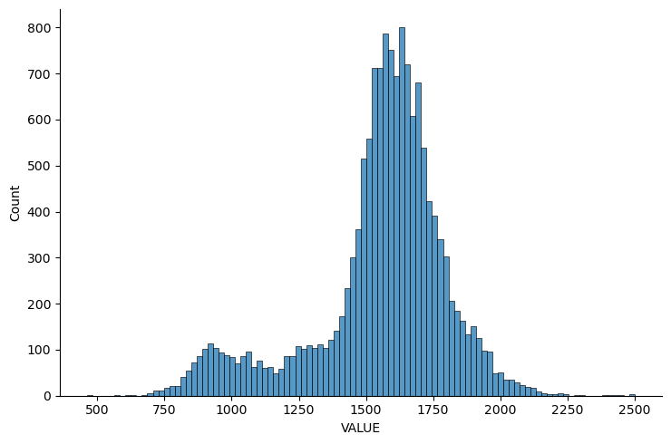

```python
# Average annual hours worked        15120
print("\nAverage annual hours worked")
df_AvgAnnHrsWrk = df_sorted_na.loc[
    (df_sorted_na['Indicators'] == 'Average annual hours worked')
]
# grouped = df_AvgAnnHrsWrk.groupby(['GEO'])
grouped = df_AvgAnnHrsWrk.groupby(['Indicators'])
print(grouped['VALUE'].agg([np.median, np.mean, np.std, np.size]))
print("The total number of this one is ",len(df_AvgAnnHrsWrk.index))

sns.displot(data=df_AvgAnnHrsWrk, x="VALUE", kind="hist", bins = 100, aspect = 1.5)
plt.show()
```

Panda Profiling only for "Average annual hours worked"

```python
pp = ProfileReport(df_AvgAnnHrsWrk, title="Average annual hours worked")
pp_df = pp.to_html()

f = open("Average annual hours worked.html", "a")  # Expert into html file without modifying any columns in dataset.
f.write(pp_df)
f.close()
```

Average annual wages and salaries from modified sorted dataset. (Mention above)

```
Average annual wages and salaries
                                    median          mean           std   size
Indicators
Average annual wages and salaries  42186.5  43804.782748  16620.351087  14688
The total number of this one is  14688
```

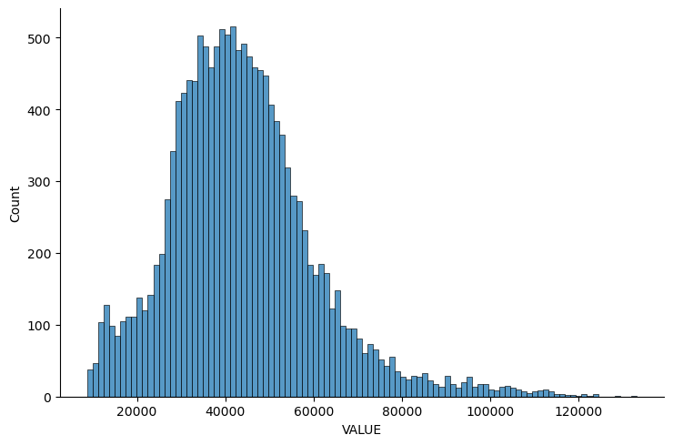

```python
# Average annual wages and salaries  15120
print("\nAverage annual wages and salaries")
df_AvgAnnWages = df_sorted_na.loc[
    (df_sorted_na['Indicators'] == 'Average annual wages and salaries')
]
grouped = df_AvgAnnWages.groupby(['Indicators'])
print(grouped['VALUE'].agg([np.median, np.mean, np.std, np.size]))
print("The total number of this one is ",len(df_AvgAnnWages.index))

sns.displot(data=df_AvgAnnWages, x="VALUE", kind="hist", bins = 100, aspect = 1.5)
plt.show()
```

Panda Profiling only for "Average annual wages and salaries"

```python
pp = ProfileReport(df_AvgAnnWages, title="Average annual wages and salaries")
pp_df = pp.to_html()

f = open("Average annual wages and salaries.html", "a")  # Expert into html file without modifying any columns in dataset.
f.write(pp_df)
f.close()
```

Average hourly wage from modified sorted dataset. (Mentions above)

```
Average hourly wage
                     median       mean       std   size
Indicators
Average hourly wage    26.7  27.825611  8.601721  14688
The total number of this one is  14688
```

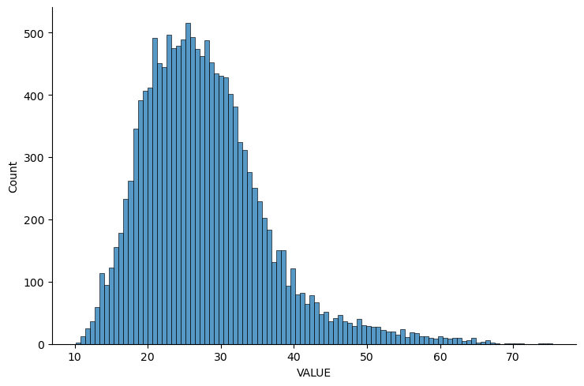

```python
# Average hourly wage                15120
print("\nAverage hourly wage")
df_AvgHrsWages = df_sorted_na.loc[
    (df_sorted_na['Indicators'] == 'Average hourly wage')
]
grouped = df_AvgHrsWages.groupby(['Indicators'])
print(grouped['VALUE'].agg([np.median, np.mean, np.std, np.size]))
print("The total number of this one is ",len(df_AvgHrsWages.index))

sns.displot(data=df_AvgHrsWages, x="VALUE", kind="hist", bins = 100, aspect = 1.5)
plt.show()
```

Panda Profiling only for "Average hourly wages"

```python
pp = ProfileReport(df_AvgHrsWages, title="Average hourly wage")
pp_df = pp.to_html()

f = open("Average hourly wages.html", "a")  # Expert into html file without modifying any columns in dataset.
f.write(pp_df)
f.close()
```

Average weekly hours worked from modified sorted dataset.

```
Average weekly hours worked
                             median       mean      std   size
Indicators
Average weekly hours worked    31.0  29.831767  4.86689  14688
The total number of this one is  14688
```

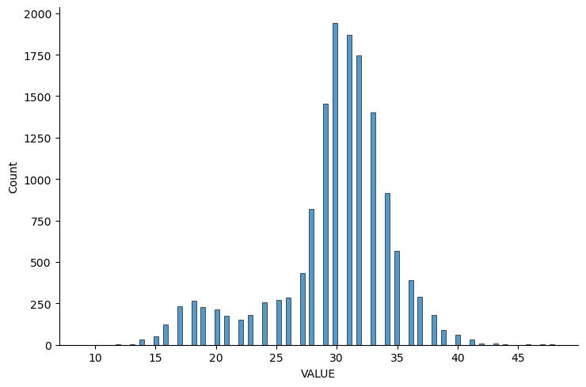

```python
# Average weekly hours worked        15120
print("\nAverage weekly hours worked")
df_AvgWeekHrsWrked = df_sorted_na.loc[
    (df_sorted_na['Indicators'] == 'Average weekly hours worked')
]
grouped = df_AvgWeekHrsWrked.groupby(['Indicators'])
print(grouped['VALUE'].agg([np.median, np.mean, np.std, np.size]))
print("The total number of this one is ",len(df_AvgWeekHrsWrked.index))

sns.displot(data=df_AvgWeekHrsWrked, x="VALUE", kind="hist", bins = 100, aspect = 1.5)
plt.show()
```

Panda Profiling only for "Average weekly hours worked"

```python
pp = ProfileReport(df_AvgWeekHrsWrked, title="Average weekly hours worked")
pp_df = pp.to_html()

f = open("Average weekly hours worked.html", "a")  # Expert into html file without modifying any columns in dataset.
f.write(pp_df)
f.close()
```

Hours worked from modified sorted dataset.

```
Hours worked
              median          mean            std   size
Indicators
Hours worked  9586.5  83596.946283  253684.449101  14688
              amin       amax
Indicators
Hours worked   6.0  3857813.0
The total number of this one is  14688
```

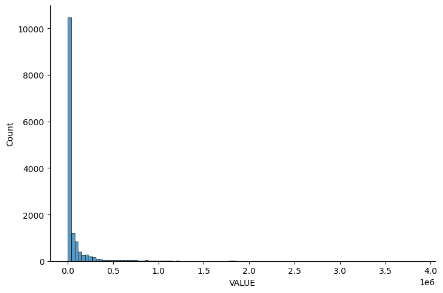

```python
# Hours worked                       15120
print("\nHours worked")
df_Hrs_Wrked = df_sorted_na.loc[
    (df_sorted_na['Indicators'] == 'Hours worked')
]
grouped = df_Hrs_Wrked.groupby(['Indicators'])
print(grouped['VALUE'].agg([np.median, np.mean, np.std, np.size]))
print(grouped['VALUE'].agg([np.amin, np.amax]))
print("The total number of this one is ",len(df_Hrs_Wrked.index))

sns.displot(data=df_Hrs_Wrked, x="VALUE", kind="hist", bins = 100, aspect = 1.5)
plt.show()
```

```python
pp = ProfileReport(df_Hrs_Wrked, title="Hours Worked")
pp_df = pp.to_html()

f = open("Hours worked.html", "a")  # Expert into html file without modifying any columns in dataset.
f.write(pp_df)
f.close()
```

Number of jobs from modified sorted dataset.

```
Number of jobs
                median          mean            std   size
Indicators
Number of jobs  6305.5  53441.062432  161120.806948  14688
                amin       amax
Indicators
Number of jobs  11.0  2428289.0
The total number of this one is  14688
```

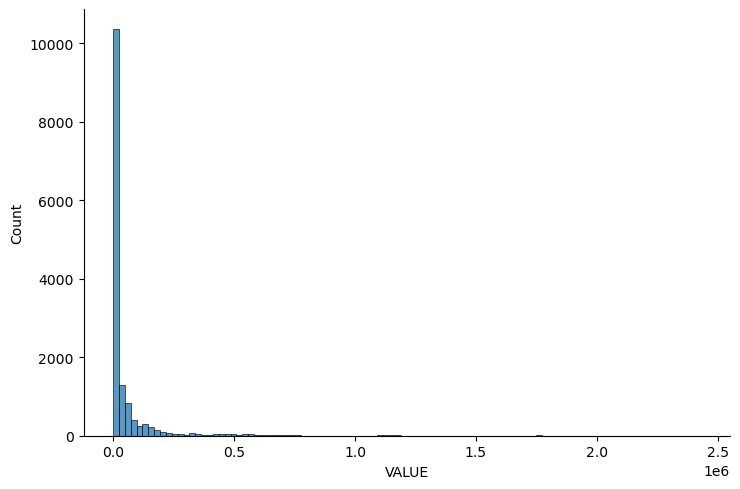

```python
# Number of jobs                     15120
print("\nNumber of jobs")
df_NumOfJob = df_sorted_na.loc[
    (df_sorted_na['Indicators'] == 'Number of jobs')
]
grouped = df_NumOfJob.groupby(['Indicators'])
print(grouped['VALUE'].agg([np.median, np.mean, np.std, np.size]))
print(grouped['VALUE'].agg([np.amin, np.amax]))
print("The total number of this one is ",len(df_NumOfJob.index))

sns.displot(data=df_NumOfJob, x="VALUE", kind="hist", bins = 100, aspect = 1.5)
plt.show()
```

```python
pp = ProfileReport(df_NumOfJob, title="Number of jobs")
pp_df = pp.to_html()

f = open("Number of jobs.html", "a")  # Expert into html file without modifying any columns in dataset.
f.write(pp_df)
f.close()
```

Wages and salaries from modified sorted dataset.

```
Wages and salaries
                    median         mean          std   size
Indicators
Wages and salaries   224.0  2484.918233  7977.441388  14688
                    amin      amax
Indicators
Wages and salaries   0.0  132601.0
The total number of this one is  14688
```

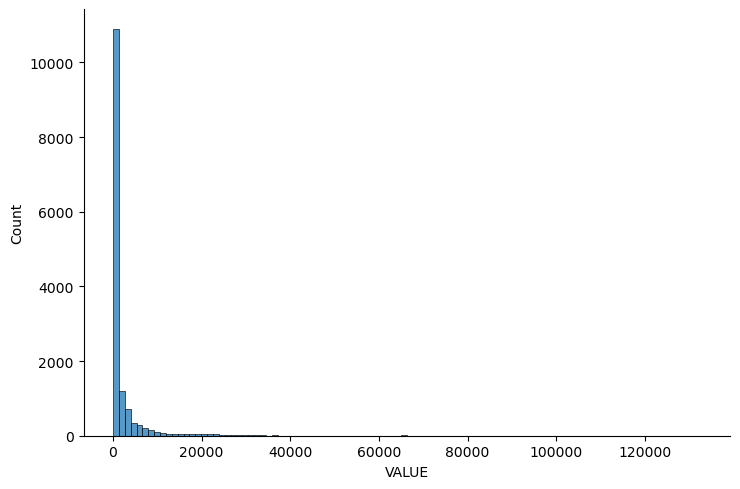

```python
# Wages and salaries                 15120
print("\nWages and salaries")
df_WagesAndSalaries = df_sorted_na.loc[
    (df_sorted_na['Indicators'] == 'Wages and salaries')
]
grouped = df_WagesAndSalaries.groupby(['Indicators'])
print(grouped['VALUE'].agg([np.median, np.mean, np.std, np.size]))
print(grouped['VALUE'].agg([np.amin, np.amax]))
print("The total number of this one is ",len(df_WagesAndSalaries.index))

sns.displot(data=df_WagesAndSalaries, x="VALUE", kind="hist", bins = 100, aspect = 1.5)
plt.show()
```

```python
pp = ProfileReport(df_WagesAndSalaries, title="Wages and Salaries")
pp_df = pp.to_html()

f = open("Wages and salaries.html", "a")  # Expert into html file without modifying any columns in dataset.
f.write(pp_df)
f.close()
```

Next step as analysis, I use "Fitter" to analysis the best fit for the values. The values are distributed correctly. However, it is not normally distributed.

Best distribution for "Average annual hours worked"

```
{'beta': {'a': 638.3317504246395,
  'b': 31.78242716784456,
  'loc': -26340.79799985259,
  'scale': 29280.128191604977}}
```

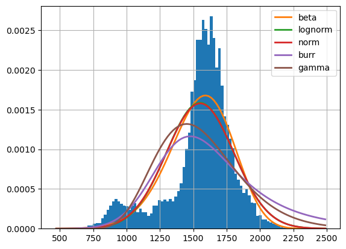

```python
# Not noramlly distirbuted, skewed toward right

# https://medium.com/the-researchers-guide/finding-the-best-distribution-that-fits-your-data-using-pythons-fitter-library-319a5a0972e9
# https://www.datacamp.com/tutorial/probability-distributions-python
# https://realpython.com/python-histograms/
# https://seaborn.pydata.org/tutorial/introduction.html
# https://aminazahid45.medium.com/seaborn-in-python-76f44752a7c8
# https://stackoverflow.com/questions/26597116/seaborn-plots-not-showing-up
# https://www.analyticsvidhya.com/blog/2021/02/statistics-101-beginners-guide-to-continuous-probability-distributions/

fa = Fitter(df_AvgAnnHrsWrk["VALUE"].values,
           distributions=['gamma',
                          'lognorm',
                          "beta",
                          "burr",
                          "norm"])
fa.fit()
fa.summary()
fa.get_best(method = 'sumsquare_error')
```

Best distribution for "Average annual wages and salaries"

```
{'gamma': {'a': 10.317012968188816,
  'loc': -8874.841101131682,
  'scale': 5106.09266888318}}
```

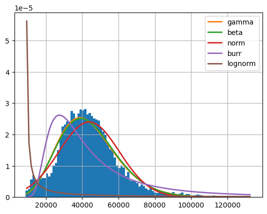

```python
fa = Fitter(df_AvgAnnWages["VALUE"].values,
           distributions=['gamma',
                          'lognorm',
                          "beta",
                          "burr",
                          "norm"])
fa.fit()
fa.summary()
fa.get_best(method = 'sumsquare_error')
```

Best distribution for "Average hourly wage"

```
{'lognorm': {'s': 0.32868880665290323,
  'loc': 2.5266200749710075,
  'scale': 23.96526012956064}}
```

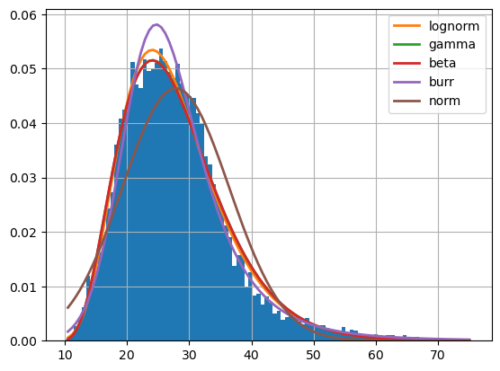

```python
fa = Fitter(df_AvgHrsWages["VALUE"].values,
           distributions=['gamma',
                          'lognorm',
                          "beta",
                          "burr",
                          "norm"])
fa.fit()
fa.summary()
fa.get_best(method = 'sumsquare_error')
```

Best distribution for "Average weekly hours worked"

```
{'burr': {'c': 24.425610086588648,
  'd': 0.2639474187210325,
  'loc': -0.19516675888992813,
  'scale': 33.9923544234202}}
```

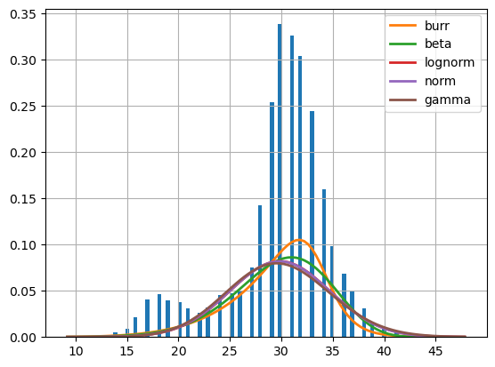

```python
fa = Fitter(df_AvgWeekHrsWrked["VALUE"].values,
           distributions=['gamma',
                          'lognorm',
                          "beta",
                          "burr",
                          "norm"])
fa.fit()
fa.summary()
fa.get_best(method = 'sumsquare_error')
```

Best distribution for "Hours Worked"

```
{'lognorm': {'s': 2.500328743903225,
  'loc': 5.890210931623885,
  'scale': 8052.849839197419}}
```

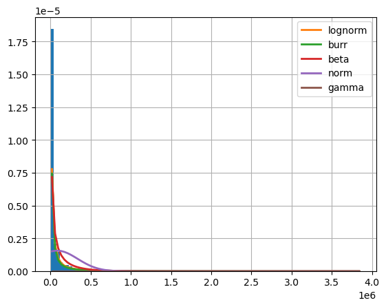

```python
fa = Fitter(df_Hrs_Wrked["VALUE"].values,
           distributions=['gamma',
                          'lognorm',
                          "beta",
                          "burr",
                          "norm"])
fa.fit()
fa.summary()
fa.get_best(method = 'sumsquare_error')
```

Best distrubution for "Number of jobs"

```
{'beta': {'a': 0.44093091654590877,
  'b': 478.35910204629215,
  'loc': 10.999999999999998,
  'scale': 18916817.838308237}}
```

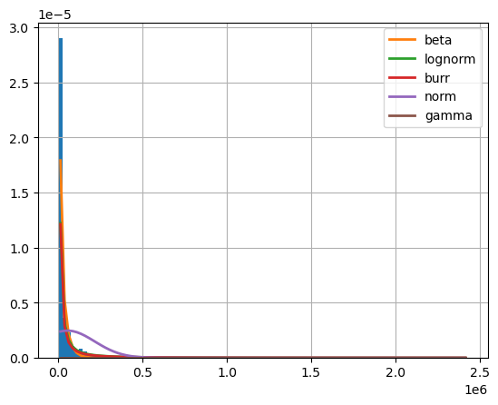

```python
fa = Fitter(df_NumOfJob["VALUE"].values,
           distributions=['gamma',
                          'lognorm',
                          "beta",
                          "burr",
                          "norm"])
fa.fit()
fa.summary()
fa.get_best(method = 'sumsquare_error')
```

Best distribution for "Wages and Salaries"

```
{'beta': {'a': 0.45806730861492995,
  'b': 504.0982556396307,
  'loc': -3.462059833380747e-23,
  'scale': 927559.1543601784}}
```

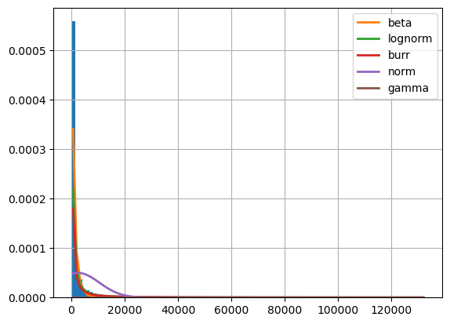

```python
fa = Fitter(df_WagesAndSalaries["VALUE"].values,
           distributions=['gamma',
                          'lognorm',
                          "beta",
                          "burr",
                          "norm"])
fa.fit()
fa.summary()
fa.get_best(method = 'sumsquare_error')
```

Cohert Analysis Part

```python
# I have decided to skip this part because the result I am expected is not there.
# I only see the one record in cohort analysis.
# I have plan to fix those cohort analysis.
```

```python
# # https://saturncloud.io/blog/converting-a-column-to-date-format-in-pandas-dataframe/
# # https://sparkbyexamples.com/pandas/pandas-extract-year-from-datetime/
# # https://saturncloud.io/blog/converting-a-column-to-date-format-in-pandas-dataframe/

# # https://www.askpython.com/python/examples/cohort-analysis
# # https://www.activestate.com/blog/cohort-analysis-with-python/


# # Make a copy
# data_galaxy = df_AvgAnnHrsWrk .copy()


# data_galaxy['REF_DATE'] = data_galaxy['REF_DATE'].astype(str)
# data_galaxy['REF_DATE'] = pd.to_datetime(data_galaxy["REF_DATE"])

# data_galaxy = data_galaxy.sort_values('REF_DATE')

# def getting_months(m):
#     return dt.datetime(m.year, m.month,1)

# #function for data to create a series
# def get_date_elements(df, column):
#     day = df[column].dt.day
#     month = df[column].dt.month
#     year = df[column].dt.year
#     return day, month, year

# # using the above function
# data_galaxy['Invoice-Month'] = data_galaxy['REF_DATE'].apply(getting_months)
# # self.data_galaxy['Invoice-Month'] = self.data_galaxy['Invoice-Month']

# # indexing a column for the first month visit of the customer
# data_galaxy['Cohort-Month'] = data_galaxy.groupby('DGUID')['Invoice-Month'].transform('min')
# # data_galaxy['Cohort-Month'] = data_galaxy['Cohort-Month'].dt.to_period('Y')
# data_galaxy.head(30)

# # getting date for columns and invoice
# _,Invoiceofmonth,Invoiceofyear = get_date_elements(data_galaxy,'Invoice-Month')
# _,Cohortofmonth,Cohortofyear =  get_date_elements(data_galaxy,'Cohort-Month')

# # cohort index creation
# yeardifference = Invoiceofyear -Cohortofyear
# monthdifference = Invoiceofmonth - Cohortofmonth
# data_galaxy['Cohort-Index'] = yeardifference*12 +monthdifference+1

# # counting customer ID
# cohort_data = data_galaxy.groupby(['Cohort-Month','Cohort-Index'])['DGUID'].apply(pd.Series.nunique).reset_index()

# # pivot table creation
# cohort_table = cohort_data.pivot(index='Cohort-Month', columns=['Cohort-Index'],values='DGUID')

# # changing index of the cohort table
# cohort_table.index = cohort_table.index.strftime('%Y') # ('%B %Y')

# # creation of heatmap and visualization
# plt.figure(figsize=(21,10))
# sns.heatmap(cohort_table,annot=True,cmap='Greens')

# # cohort for percentage analysis
# new_cohort_table = cohort_table.divide(cohort_table.iloc[:,0],axis=0)

# # creating a percentage visualization
# plt.figure(figsize=(21,10))
# colormap=sns.color_palette("mako", as_cmap=True)
# sns.heatmap(new_cohort_table,annot=True,fmt='.0%',cmap=colormap)
# # display the heatmaps.
# plt.show()
```

For next step, I will divide each Indicators dataset into three different datasets.  
They are 2013-2015, 2016-2018, 2019-2021.  
I have dataset prepared before 2010-2012. However, it will not be used after this section, there's too much to analysis to do.  
It will also demonstrate here why. Originally, I used divide dataset into 2016-2017, 2018-2019, and 2020-2021 from dataset that was divided from 2016 and up.

```python
print("There are seven Indicators to analysis,")
grouped = df_sorted_na.groupby('Indicators')
print(grouped['VALUE'].agg([np.size]))

print("\nThe data inside between 2010-2013, there's are # number of data and I will be repeating this seven more time.,")
df_Avg_Sample = df_AvgAnnHrsWrk.loc[
    (df_AvgAnnHrsWrk['REF_DATE'] == 2010) |
    (df_AvgAnnHrsWrk['REF_DATE'] == 2011) |
    (df_AvgAnnHrsWrk['REF_DATE'] == 2012)
]

grouped = df_Avg_Sample.groupby(['REF_DATE'])
print(grouped['VALUE'].agg([np.size]))

print("\nTo data inside above 2013 and split into three datasets, I need to repeat this analysis for "+str(7*3)+" (7x3) times.")
print("\nThis is also total of spliting into "+str(7*3)+" datasets.")

df_Avg_Sample_2013 = df_AvgAnnHrsWrk.loc[
    (df_AvgAnnHrsWrk['REF_DATE'] == 2013) |
    (df_AvgAnnHrsWrk['REF_DATE'] == 2014) |
    (df_AvgAnnHrsWrk['REF_DATE'] == 2015)
]

df_Avg_Sample_2016 = df_AvgAnnHrsWrk.loc[
    (df_AvgAnnHrsWrk['REF_DATE'] == 2016) |
    (df_AvgAnnHrsWrk['REF_DATE'] == 2017) |
    (df_AvgAnnHrsWrk['REF_DATE'] == 2018)
]

df_Avg_Sample_2019 = df_AvgAnnHrsWrk.loc[
    (df_AvgAnnHrsWrk['REF_DATE'] == 2019) |
    (df_AvgAnnHrsWrk['REF_DATE'] == 2020) |
    (df_AvgAnnHrsWrk['REF_DATE'] == 2021)
]

grouped = df_Avg_Sample_2013.groupby(['REF_DATE'])
print(grouped['VALUE'].agg([np.size]))

grouped = df_Avg_Sample_2016.groupby(['REF_DATE'])
print(grouped['VALUE'].agg([np.size]))

grouped = df_Avg_Sample_2019.groupby(['REF_DATE'])
print(grouped['VALUE'].agg([np.size]))
```

```
There are seven Indicators to analysis,
                                    size
Indicators
Average annual hours worked        14688
Average annual wages and salaries  14688
Average hourly wage                14688
Average weekly hours worked        14688
Hours worked                       14688
Number of jobs                     14688
Wages and salaries                 14688

The data inside between 2010-2013, there's are # number of data and I will be repeating this seven more time.,
          size
REF_DATE
2010      1224
2011      1224
2012      1224

To data inside above 2013 and split into three datasets, I need to repeat this analysis for 21 (7x3) times.

This is also total of spliting into 21 datasets.
          size
REF_DATE
2013      1224
2014      1224
2015      1224
          size
REF_DATE
2016      1224
2017      1224
2018      1224
          size
REF_DATE
2019      1224
2020      1224
2021      1224
```

```python
# 2010-2012
df_AvgAnnHrsWrk_2010 = df_AvgAnnHrsWrk.loc[
    (df_AvgAnnHrsWrk['REF_DATE'] == 2010) |
    (df_AvgAnnHrsWrk['REF_DATE'] == 2011) |
    (df_AvgAnnHrsWrk['REF_DATE'] == 2012)
]

grouped = df_AvgAnnHrsWrk_2010.groupby(['REF_DATE'])
print(grouped['VALUE'].agg([np.sum, np.size]))
```

```
                sum  size
REF_DATE
2010      1905000.0  1224
2011      1909823.0  1224
2012      1915650.0  1224
```

```python
print("Grabbing the data from 2013, 2016, and 2019.")

# 2013 - 2015
df_AvgAnnHrsWrk_2013 = df_AvgAnnHrsWrk.loc[
    (df_AvgAnnHrsWrk['REF_DATE'] == 2013) |
    (df_AvgAnnHrsWrk['REF_DATE'] == 2014) |
    (df_AvgAnnHrsWrk['REF_DATE'] == 2015)
]

# 2016 - 2018
df_AvgAnnHrsWrk_2016 = df_AvgAnnHrsWrk.loc[
    (df_AvgAnnHrsWrk['REF_DATE'] == 2016) |
    (df_AvgAnnHrsWrk['REF_DATE'] == 2017) |
    (df_AvgAnnHrsWrk['REF_DATE'] == 2018)
]

# 2019- 2021
df_AvgAnnHrsWrk_2019 = df_AvgAnnHrsWrk.loc[
    (df_AvgAnnHrsWrk['REF_DATE'] == 2019) |
    (df_AvgAnnHrsWrk['REF_DATE'] == 2020) |
    (df_AvgAnnHrsWrk['REF_DATE'] == 2021)
]

grouped = df_AvgAnnHrsWrk_2013.groupby(['REF_DATE'])
print(grouped['VALUE'].agg([np.sum, np.size]))

grouped = df_AvgAnnHrsWrk_2016.groupby(['REF_DATE'])
print(grouped['VALUE'].agg([np.sum, np.size]))

grouped = df_AvgAnnHrsWrk_2019.groupby(['REF_DATE'])
print(grouped['VALUE'].agg([np.sum, np.size]))
```

```
Grabbing the data from 2013, 2016, and 2019.
                sum  size
REF_DATE
2013      1906851.0  1224
2014      1898034.0  1224
2015      1907286.0  1224
                sum  size
REF_DATE
2016      1899738.0  1224
2017      1881389.0  1224
2018      1894227.0  1224
                sum  size
REF_DATE
2019      1894126.0  1224
2020      1873544.0  1224
2021      1901826.0  1224
```

```python
# # 2016-2017
# pp = ProfileReport(df_AvgAnnHrsWrk_2013, title="Average annual hours worked 2013")
# pp_df = pp.to_html()

# f = open("Average annual hours worked 2016.html", "a")  # Expert into html file without modifying any columns in dataset.
# f.write(pp_df)
# f.close()

# # 2017 - 2019
# pp = ProfileReport(df_AvgAnnHrsWrk_2016, title="Average annual hours worked 2016")
# pp_df = pp.to_html()

# f = open("Average annual hours worked 2018.html", "a")  # Expert into html file without modifying any columns in dataset.
# f.write(pp_df)
# f.close()

# # 2020 - 2021
# pp = ProfileReport(df_AvgAnnHrsWrk_2019, title="Average annual hours worked 2019")
# pp_df = pp.to_html()

# f = open("Average annual hours worked 2020.html", "a")  # Expert into html file without modifying any columns in dataset.
# f.write(pp_df)
# f.close()
```

Grabbing the year (REF_DATE) from 2010, 2013, 2016, and 2019 individually for "Average annual wages and salaries".

```python
# 2010 - 2012
df_AvgAnnWages_2010 = df_AvgAnnWages.loc[
    (df_AvgAnnWages['REF_DATE'] == 2010) |
    (df_AvgAnnWages['REF_DATE'] == 2011) |
    (df_AvgAnnWages['REF_DATE'] == 2012)
]

grouped = df_AvgAnnWages_2010.groupby(['REF_DATE'])
print(grouped['VALUE'].agg([np.sum, np.size]))
```

```
                 sum  size
REF_DATE
2010      48093832.0  1224
2011      49165720.0  1224
2012      50085622.0  1224
```

```python
print("Grabbing the data from 2017, 2019, and 2021.")

# 2013 - 2015
df_AvgAnnWages_2013 = df_AvgAnnWages.loc[
    (df_AvgAnnWages['REF_DATE'] == 2013) |
    (df_AvgAnnWages['REF_DATE'] == 2014) |
    (df_AvgAnnWages['REF_DATE'] == 2015)
]

# 2016 - 2018
df_AvgAnnWages_2016 = df_AvgAnnWages.loc[
    (df_AvgAnnWages['REF_DATE'] == 2016) |
    (df_AvgAnnWages['REF_DATE'] == 2017) |
    (df_AvgAnnWages['REF_DATE'] == 2018)
]

# 2019 - 2021
df_AvgAnnWages_2019 = df_AvgAnnWages.loc[
    (df_AvgAnnWages['REF_DATE'] == 2019) |
    (df_AvgAnnWages['REF_DATE'] == 2020) |
    (df_AvgAnnWages['REF_DATE'] == 2021)
]

grouped = df_AvgAnnWages_2013.groupby(['REF_DATE'])
print(grouped['VALUE'].agg([np.sum, np.size]))

grouped = df_AvgAnnWages_2016.groupby(['REF_DATE'])
print(grouped['VALUE'].agg([np.sum, np.size]))

grouped = df_AvgAnnWages_2019.groupby(['REF_DATE'])
print(grouped['VALUE'].agg([np.sum, np.size]))
```

```
Grabbing the data from 2017, 2019, and 2021.
                 sum  size
REF_DATE
2013      50598135.0  1224
2014      51805889.0  1224
2015      52715143.0  1224
                 sum  size
REF_DATE
2016      53166285.0  1224
2017      53965359.0  1224
2018      55525920.0  1224
                 sum  size
REF_DATE
2019      56997121.0  1224
2020      60597775.0  1224
2021      60687848.0  1224
```

Panda Profiling for year 2013, 2016, and 2019 for "Average annual wages and salaries".

```python
# pp = ProfileReport(df_AvgAnnWages_2013, title="Average annual wages and salaries 2013")
# pp_df = pp.to_html()

# f = open("Average annual wages and salaries 2013.html", "a")  # Expert into html file without modifying any columns in dataset.
# f.write(pp_df)
# f.close()

# pp = ProfileReport(df_AvgAnnWages_2016, title="Average annual wages and salaries 2016")
# pp_df = pp.to_html()

# f = open("Average annual wages and salaries 2016.html", "a")  # Expert into html file without modifying any columns in dataset.
# f.write(pp_df)
# f.close()

# pp = ProfileReport(df_AvgAnnWages_2019, title="Average annual wages and salaries 2019")
# pp_df = pp.to_html()

# f = open("Average annual wages and salaries 2019.html", "a")  # Expert into html file without modifying any columns in dataset.
# f.write(pp_df)
# f.close()
```

Grabbing the year (REF_DATE) from 2010, 2013, 2016, and 2019 individually for "Average hourly wages".

```python
# 2010 - 2012
df_AvgHrsWages_2010 = df_AvgHrsWages.loc[
    (df_AvgHrsWages['REF_DATE'] == 2010) |
    (df_AvgHrsWages['REF_DATE'] == 2011) |
    (df_AvgHrsWages['REF_DATE'] == 2012)
]

grouped = df_AvgHrsWages_2010.groupby(['REF_DATE'])
print(grouped['VALUE'].agg([np.sum, np.size]))
```

```
               sum  size
REF_DATE
2010      30453.20  1224
2011      31053.73  1224
2012      31511.37  1224
```

```python
print("Grabbing the data from 2013, 2016, and 2019.")

# 2013 - 2015
df_AvgHrsWages_2013 = df_AvgHrsWages.loc[
    (df_AvgHrsWages['REF_DATE'] == 2013) |
    (df_AvgHrsWages['REF_DATE'] == 2014) |
    (df_AvgHrsWages['REF_DATE'] == 2015)
]

# 2016 - 2018
df_AvgHrsWages_2016 = df_AvgHrsWages.loc[
    (df_AvgHrsWages['REF_DATE'] == 2016) |
    (df_AvgHrsWages['REF_DATE'] == 2017) |
    (df_AvgHrsWages['REF_DATE'] == 2018)
]

# 2019 - 2021
df_AvgHrsWages_2019 = df_AvgHrsWages.loc[
    (df_AvgHrsWages['REF_DATE'] == 2019) |
    (df_AvgHrsWages['REF_DATE'] == 2020) |
    (df_AvgHrsWages['REF_DATE'] == 2021)
]

grouped = df_AvgHrsWages_2013.groupby(['REF_DATE'])
print(grouped['VALUE'].agg([np.sum, np.size]))

grouped = df_AvgHrsWages_2016.groupby(['REF_DATE'])
print(grouped['VALUE'].agg([np.sum, np.size]))

grouped = df_AvgHrsWages_2019.groupby(['REF_DATE'])
print(grouped['VALUE'].agg([np.sum, np.size]))
```

```
Grabbing the data from 2013, 2016, and 2019.
               sum  size
REF_DATE
2013      31932.19  1224
2014      32916.44  1224
2015      33362.79  1224
               sum  size
REF_DATE
2016      33756.84  1224
2017      34571.41  1224
2018      35356.16  1224
               sum  size
REF_DATE
2019      36293.34  1224
2020      38980.38  1224
2021      38514.73  1224
```

Panda Profiling for year 2013, 2016, and 2019 for "Average hourly wages".

```python
# pp = ProfileReport(df_AvgHrsWages_2013, title="Average hourly wage 2013")
# pp_df = pp.to_html()

# f = open("Average hourly wages 2013.html", "a")  # Expert into html file without modifying any columns in dataset.
# f.write(pp_df)
# f.close()

# pp = ProfileReport(df_AvgHrsWages_2016, title="Average hourly wage 2016")
# pp_df = pp.to_html()

# f = open("Average hourly wages 2016.html", "a")  # Expert into html file without modifying any columns in dataset.
# f.write(pp_df)
# f.close()

# pp = ProfileReport(df_AvgHrsWages_2019, title="Average hourly wage 2019")
# pp_df = pp.to_html()

# f = open("Average hourly wages 2019.html", "a")  # Expert into html file without modifying any columns in dataset.
# f.write(pp_df)
# f.close()
```

Grabbing the year (REF_DATE) from 2010, 2013, 2016, and 2019 individually for "Average weekly hours worked".

```python
# 2010 - 2012
df_AvgWeekHrsWrked_2010 = df_AvgWeekHrsWrked.loc[
    (df_AvgWeekHrsWrked['REF_DATE'] == 2010) |
    (df_AvgWeekHrsWrked['REF_DATE'] == 2011) |
    (df_AvgWeekHrsWrked['REF_DATE'] == 2012)
]

grouped = df_AvgWeekHrsWrked_2010.groupby(['REF_DATE'])
print(grouped['VALUE'].agg([np.sum, np.size]))
```

```
              sum  size
REF_DATE
2010      36645.0  1224
2011      36732.0  1224
2012      36842.0  1224
```

```python
print("Grabbing the data from 2013, 2016, and 2019.")

# 2013 - 2015
df_AvgWeekHrsWrked_2013 = df_AvgWeekHrsWrked.loc[
    (df_AvgWeekHrsWrked['REF_DATE'] == 2013) |
    (df_AvgWeekHrsWrked['REF_DATE'] == 2014) |
    (df_AvgWeekHrsWrked['REF_DATE'] == 2015)
]

# 2016 - 2018
df_AvgWeekHrsWrked_2016 = df_AvgWeekHrsWrked.loc[
    (df_AvgWeekHrsWrked['REF_DATE'] == 2016) |
    (df_AvgWeekHrsWrked['REF_DATE'] == 2017) |
    (df_AvgWeekHrsWrked['REF_DATE'] == 2018)
]

# 2019 - 2021
df_AvgWeekHrsWrked_2019 = df_AvgWeekHrsWrked.loc[
    (df_AvgWeekHrsWrked['REF_DATE'] == 2019) |
    (df_AvgWeekHrsWrked['REF_DATE'] == 2020) |
    (df_AvgWeekHrsWrked['REF_DATE'] == 2021)
]

grouped = df_AvgWeekHrsWrked_2013.groupby(['REF_DATE'])
print(grouped['VALUE'].agg([np.sum, np.size]))

grouped = df_AvgWeekHrsWrked_2016.groupby(['REF_DATE'])
print(grouped['VALUE'].agg([np.sum, np.size]))

grouped = df_AvgWeekHrsWrked_2019.groupby(['REF_DATE'])
print(grouped['VALUE'].agg([np.sum, np.size]))
```

```
Grabbing the data from 2013, 2016, and 2019.
              sum  size
REF_DATE
2013      36671.0  1224
2014      36483.0  1224
2015      36678.0  1224
              sum  size
REF_DATE
2016      36541.0  1224
2017      36170.0  1224
2018      36416.0  1224
              sum  size
REF_DATE
2019      36400.0  1224
2020      36036.0  1224
2021      36555.0  1224
```

Panda Profiling for year 2013, 2016, and 2019 for "Average weekly hours worked".

```python
# pp = ProfileReport(df_AvgWeekHrsWrked_2013, title="Average weekly hours worked 2013")
# pp_df = pp.to_html()

# f = open("Average weekly hours worked 2013.html", "a")  # Expert into html file without modifying any columns in dataset.
# f.write(pp_df)
# f.close()

# pp = ProfileReport(df_AvgWeekHrsWrked_2016, title="Average weekly hours worked 2016")
# pp_df = pp.to_html()

# f = open("Average weekly hours worked 2016.html", "a")  # Expert into html file without modifying any columns in dataset.
# f.write(pp_df)
# f.close()

# pp = ProfileReport(df_AvgWeekHrsWrked_2019, title="Average weekly hours worked 2019")
# pp_df = pp.to_html()

# f = open("Average weekly hours worked 2019.html", "a")  # Expert into html file without modifying any columns in dataset.
# f.write(pp_df)
# f.close()
```

Grabbing the year (REF_DATE) from 2010, 2013, 2016, and 2019 individually for "hours worked".

```python
# 2010 - 2012
df_Hrs_Wrked_2010 = df_Hrs_Wrked.loc[
    (df_Hrs_Wrked['REF_DATE'] == 2010) |
    (df_Hrs_Wrked['REF_DATE'] == 2011) |
    (df_Hrs_Wrked['REF_DATE'] == 2012)
]

grouped = df_Hrs_Wrked_2010.groupby(['REF_DATE'])
print(grouped['VALUE'].agg([np.sum, np.size]))
```

```
                 sum  size
REF_DATE
2010      94217881.0  1224
2011      95953248.0  1224
2012      97724232.0  1224
```

```python
print("Grabbing the data from 2013, 2016, and 2019.")

# 2013 - 2015
df_Hrs_Wrked_2013 = df_Hrs_Wrked.loc[
    (df_Hrs_Wrked['REF_DATE'] == 2013) |
    (df_Hrs_Wrked['REF_DATE'] == 2014) |
    (df_Hrs_Wrked['REF_DATE'] == 2015)
]

# 2016 - 2018
df_Hrs_Wrked_2016 = df_Hrs_Wrked.loc[
    (df_Hrs_Wrked['REF_DATE'] == 2016) |
    (df_Hrs_Wrked['REF_DATE'] == 2017) |
    (df_Hrs_Wrked['REF_DATE'] == 2018)
]

# 2019 - 2021
df_Hrs_Wrked_2019 = df_Hrs_Wrked.loc[
    (df_Hrs_Wrked['REF_DATE'] == 2019) |
    (df_Hrs_Wrked['REF_DATE'] == 2020) |
    (df_Hrs_Wrked['REF_DATE'] == 2021)
]

grouped = df_Hrs_Wrked_2013.groupby(['REF_DATE'])
print(grouped['VALUE'].agg([np.sum, np.size]))

grouped = df_Hrs_Wrked_2016.groupby(['REF_DATE'])
print(grouped['VALUE'].agg([np.sum, np.size]))

grouped = df_Hrs_Wrked_2019.groupby(['REF_DATE'])
print(grouped['VALUE'].agg([np.sum, np.size]))
```

```
Grabbing the data from 2013, 2016, and 2019.
                  sum  size
REF_DATE
2013       98935086.0  1224
2014       99777902.0  1224
2015      101927894.0  1224
                  sum  size
REF_DATE
2016      103980992.0  1224
2017      103906357.0  1224
2018      106885614.0  1224
                  sum  size
REF_DATE
2019      108384508.0  1224
2020      103897606.0  1224
2021      112280627.0  1224
```

Panda Profiling for year 2013, 2016, and 2019 for "hours worked".

```python
# pp = ProfileReport(df_Hrs_Wrked_2013, title="Hours Worked 2013")
# pp_df = pp.to_html()

# f = open("Hours worked 2013.html", "a")  # Expert into html file without modifying any columns in dataset.
# f.write(pp_df)
# f.close()

# pp = ProfileReport(df_Hrs_Wrked_2016, title="Hours Worked 2016")
# pp_df = pp.to_html()

# f = open("Hours worked 2016.html", "a")  # Expert into html file without modifying any columns in dataset.
# f.write(pp_df)
# f.close()

# pp = ProfileReport(df_Hrs_Wrked_2019, title="Hours Worked 2019")
# pp_df = pp.to_html()

# f = open("Hours worked 2019.html", "a")  # Expert into html file without modifying any columns in dataset.
# f.write(pp_df)
# f.close()
```

Grabbing the year (REF_DATE) from 2010, 2013, 2016, and 2019 individually for "Number of jobs".

```python
# 2010 - 2012
df_NumOfJob_2010 = df_NumOfJob.loc[
    (df_NumOfJob['REF_DATE'] == 2010) |
    (df_NumOfJob['REF_DATE'] == 2011) |
    (df_NumOfJob['REF_DATE'] == 2012)
]

grouped = df_NumOfJob_2010.groupby(['REF_DATE'])
print(grouped['VALUE'].agg([np.sum, np.size]))
```

```
                 sum  size
REF_DATE
2010      59793067.0  1224
2011      61122016.0  1224
2012      61949430.0  1224
```

```python
print("Grabbing the data from 2013, 2016, and 2019.")

# 2013 - 2015
df_NumOfJob_2013 = df_NumOfJob.loc[
    (df_NumOfJob['REF_DATE'] == 2013) |
    (df_NumOfJob['REF_DATE'] == 2014) |
    (df_NumOfJob['REF_DATE'] == 2015)
]

# 2016 - 2018
df_NumOfJob_2016 = df_NumOfJob.loc[
    (df_NumOfJob['REF_DATE'] == 2016) |
    (df_NumOfJob['REF_DATE'] == 2017) |
    (df_NumOfJob['REF_DATE'] == 2018)
]

# 2019 - 2021
df_NumOfJob_2019 = df_NumOfJob.loc[
    (df_NumOfJob['REF_DATE'] == 2019) |
    (df_NumOfJob['REF_DATE'] == 2020) |
    (df_NumOfJob['REF_DATE'] == 2021)
]

grouped = df_NumOfJob_2013.groupby(['REF_DATE'])
print(grouped['VALUE'].agg([np.sum, np.size]))

grouped = df_NumOfJob_2016.groupby(['REF_DATE'])
print(grouped['VALUE'].agg([np.sum, np.size]))

grouped = df_NumOfJob_2019.groupby(['REF_DATE'])
print(grouped['VALUE'].agg([np.sum, np.size]))
```

```
Grabbing the data from 2013, 2016, and 2019.
                 sum  size
REF_DATE
2013      63161481.0  1224
2014      63980381.0  1224
2015      65239031.0  1224
                 sum  size
REF_DATE
2016      66578386.0  1224
2017      66979678.0  1224
2018      68215341.0  1224
                 sum  size
REF_DATE
2019      69702012.0  1224
2020      67249987.0  1224
2021      70971515.0  1224
```

Panda Profiling for year 2013, 2016, and 2019for "Number of jobs".

```python
# pp = ProfileReport(df_NumOfJob_2013, title="Number of jobs 2013")
# pp_df = pp.to_html()

# f = open("Number of jobs 2013.html", "a")  # Expert into html file without modifying any columns in dataset.
# f.write(pp_df)
# f.close()

# pp = ProfileReport(df_NumOfJob_2016, title="Number of jobs 2016")
# pp_df = pp.to_html()

# f = open("Number of jobs 2016.html", "a")  # Expert into html file without modifying any columns in dataset.
# f.write(pp_df)
# f.close()

# pp = ProfileReport(df_NumOfJob_2019, title="Number of jobs 2019")
# pp_df = pp.to_html()

# f = open("Number of jobs 2019.html", "a")  # Expert into html file without modifying any columns in dataset.
# f.write(pp_df)
# f.close()
```

Grabbing the year (REF_DATE) from 2010, 2013, 2016, and 2019 individually for "Wages and Salaries".

```python
# 2010 - 2012
df_WagesAndSalaries_2010 = df_WagesAndSalaries.loc[
    (df_WagesAndSalaries['REF_DATE'] == 2010) |
    (df_WagesAndSalaries['REF_DATE'] == 2011) |
    (df_WagesAndSalaries['REF_DATE'] == 2012)
]

grouped = df_WagesAndSalaries_2010.groupby(['REF_DATE'])
print(grouped['VALUE'].agg([np.sum, np.size]))
```

```
                sum  size
REF_DATE
2010      2489681.0  1224
2011      2604921.0  1224
2012      2687510.0  1224
```

```python
print("Grabbing the data from 2013, 2016, and 2019.")

# 2013 - 2015
df_WagesAndSalaries_2013 = df_WagesAndSalaries.loc[
    (df_WagesAndSalaries['REF_DATE'] == 2013) |
    (df_WagesAndSalaries['REF_DATE'] == 2014) |
    (df_WagesAndSalaries['REF_DATE'] == 2015)
]

# 2016 - 2018
df_WagesAndSalaries_2016 = df_WagesAndSalaries.loc[
    (df_WagesAndSalaries['REF_DATE'] == 2016) |
    (df_WagesAndSalaries['REF_DATE'] == 2017) |
    (df_WagesAndSalaries['REF_DATE'] == 2018)
]

# 2019 - 2021
df_WagesAndSalaries_2019 = df_WagesAndSalaries.loc[
    (df_WagesAndSalaries['REF_DATE'] == 2019) |
    (df_WagesAndSalaries['REF_DATE'] == 2020) |
    (df_WagesAndSalaries['REF_DATE'] == 2021)
]

grouped = df_WagesAndSalaries_2013.groupby(['REF_DATE'])
print(grouped['VALUE'].agg([np.sum, np.size]))

grouped = df_WagesAndSalaries_2016.groupby(['REF_DATE'])
print(grouped['VALUE'].agg([np.sum, np.size]))

grouped = df_WagesAndSalaries_2019.groupby(['REF_DATE'])
print(grouped['VALUE'].agg([np.sum, np.size]))
```

```
Grabbing the data from 2013, 2016, and 2019.
                sum  size
REF_DATE
2013      2746199.0  1224
2014      2844225.0  1224
2015      2965770.0  1224
                sum  size
REF_DATE
2016      3043217.0  1224
2017      3118809.0  1224
2018      3263527.0  1224
                sum  size
REF_DATE
2019      3437480.0  1224
2020      3532888.0  1224
2021      3764252.0  1224
```

Panda Profiling for year 2013, 2016, and 2019 for "Wages and Salaries".

```python
# pp = ProfileReport(df_WagesAndSalaries_2013, title="Wages and Salaries 2013")
# pp_df = pp.to_html()

# f = open("Wages and Salaries 2013.html", "a")  # Expert into html file without modifying any columns in dataset.
# f.write(pp_df)
# f.close()

# pp = ProfileReport(df_WagesAndSalaries_2016, title="Wages and Salaries 2016")
# pp_df = pp.to_html()

# f = open("Wages and Salaries 2016.html", "a")  # Expert into html file without modifying any columns in dataset.
# f.write(pp_df)
# f.close()

# pp = ProfileReport(df_WagesAndSalaries_2019, title="Wages and Salaries 2019")
# pp_df = pp.to_html()

# f = open("Wages and Salaries 2019.html", "a")  # Expert into html file without modifying any columns in dataset.
# f.write(pp_df)
# f.close()
```

Training dataset going to be after 2013 to before 2018.  
Testing dataset going to be after 2019.  
Analysis is still finishing year of 2013 to 2018 though.  
I have decided not to use train_test_split method because I have divided dataset by the year.  
Instead I have divide it manually.

```python
# https://machinelearningmastery.com/train-test-split-for-evaluating-machine-learning-algorithms/

# This will be used if I were to use train_test_split given.

# from sklearn.model_selection import train_test_split

# train, test = train_test_split(dataset, ...)
# x_train, x_test, y_train, y_test= train_test_split(x, y, test_size= 0.2, random_state=0)
```

```python
# Average annual hours worked
# Use 2013-2015, 2016-2018 as training set
# Use 2019-2021 as testing set

frames = [df_AvgAnnHrsWrk_2013, df_AvgAnnHrsWrk_2016]
training_df_AvgAnnHrsWrk = pd.concat(frames)
testing_df_AvgAnnHrsWrk = df_AvgAnnHrsWrk_2019.copy()

grouped = training_df_AvgAnnHrsWrk.groupby(['REF_DATE'])
print(grouped['VALUE'].agg([np.sum, np.size]))

grouped = testing_df_AvgAnnHrsWrk.groupby(['REF_DATE'])
print(grouped['VALUE'].agg([np.sum, np.size]))
```

```
                sum  size
REF_DATE
2013      1906851.0  1224
2014      1898034.0  1224
2015      1907286.0  1224
2016      1899738.0  1224
2017      1881389.0  1224
2018      1894227.0  1224
                sum  size
REF_DATE
2019      1894126.0  1224
2020      1873544.0  1224
2021      1901826.0  1224
```

```python
# Average annual wages and salaries

frames = [df_AvgAnnWages_2013, df_AvgAnnWages_2016]
training_df_AvgAnnWages = pd.concat(frames)
testing_df_AvgAnnWages = df_AvgAnnHrsWrk_2019.copy()

grouped = training_df_AvgAnnWages.groupby(['REF_DATE'])
print(grouped['VALUE'].agg([np.sum, np.size]))

grouped = testing_df_AvgAnnWages.groupby(['REF_DATE'])
print(grouped['VALUE'].agg([np.sum, np.size]))
```

[output not shown]

```python
# Average hourly wage

frames = [df_AvgHrsWages_2013, df_AvgHrsWages_2016]
training_df_AvgHrsWages = pd.concat(frames)
testing_df_AvgHrsWages = df_AvgAnnHrsWrk_2019.copy()

grouped = training_df_AvgHrsWages.groupby(['REF_DATE'])
print(grouped['VALUE'].agg([np.sum, np.size]))

grouped = testing_df_AvgHrsWages.groupby(['REF_DATE'])
print(grouped['VALUE'].agg([np.sum, np.size]))
```

```
               sum  size
REF_DATE
2013      31932.19  1224
2014      32916.44  1224
2015      33362.79  1224
2016      33756.84  1224
2017      34571.41  1224
2018      35356.16  1224
                sum  size
REF_DATE
2019      1894126.0  1224
2020      1873544.0  1224
2021      1901826.0  1224
```

```python
# Average weekly hours worked

frames = [df_AvgWeekHrsWrked_2013, df_AvgWeekHrsWrked_2016]
training_df_AvgWeekHrsWrked = pd.concat(frames)
testing_df_AvgWeekHrsWrked = df_AvgAnnHrsWrk_2019.copy()

grouped = training_df_AvgWeekHrsWrked.groupby(['REF_DATE'])
print(grouped['VALUE'].agg([np.sum, np.size]))

grouped = testing_df_AvgWeekHrsWrked.groupby(['REF_DATE'])
print(grouped['VALUE'].agg([np.sum, np.size]))
```

```
              sum  size
REF_DATE
2013      36671.0  1224
2014      36483.0  1224
2015      36678.0  1224
2016      36541.0  1224
2017      36170.0  1224
2018      36416.0  1224
                sum  size
REF_DATE
2019      1894126.0  1224
2020      1873544.0  1224
2021      1901826.0  1224
```

```python
# Hours Worked

frames = [df_Hrs_Wrked_2013, df_Hrs_Wrked_2016]
training_df_Hrs_Wrked = pd.concat(frames)
testing_df_Hrs_Wrked = df_AvgAnnHrsWrk_2019.copy()

grouped = training_df_Hrs_Wrked.groupby(['REF_DATE'])
print(grouped['VALUE'].agg([np.sum, np.size]))

grouped = testing_df_Hrs_Wrked.groupby(['REF_DATE'])
print(grouped['VALUE'].agg([np.sum, np.size]))
```

```
                  sum  size
REF_DATE
2013       98935086.0  1224
2014       99777902.0  1224
2015      101927894.0  1224
2016      103980992.0  1224
2017      103906357.0  1224
2018      106885614.0  1224
                sum  size
REF_DATE
2019      1894126.0  1224
2020      1873544.0  1224
2021      1901826.0  1224
```

```python
# Number of jobs

frames = [df_NumOfJob_2013, df_NumOfJob_2016]
training_df_NumOfJob = pd.concat(frames)
testing_df_NumOfJob = df_AvgAnnHrsWrk_2019.copy()

grouped = training_df_NumOfJob.groupby(['REF_DATE'])
print(grouped['VALUE'].agg([np.sum, np.size]))

grouped = testing_df_NumOfJob.groupby(['REF_DATE'])
print(grouped['VALUE'].agg([np.sum, np.size]))
```

```
                 sum  size
REF_DATE
2013      63161481.0  1224
2014      63980381.0  1224
2015      65239031.0  1224
2016      66578386.0  1224
2017      66979678.0  1224
2018      68215341.0  1224
                sum  size
REF_DATE
2019      1894126.0  1224
2020      1873544.0  1224
2021      1901826.0  1224
```

```python
# Wages and Salaries

frames = [df_WagesAndSalaries_2013, df_WagesAndSalaries_2016]
training_df_WagesAndSalaries = pd.concat(frames)
testing_df_WagesAndSalaries = df_AvgAnnHrsWrk_2019.copy()

grouped = training_df_WagesAndSalaries.groupby(['REF_DATE'])
print(grouped['VALUE'].agg([np.sum, np.size]))

grouped = testing_df_WagesAndSalaries.groupby(['REF_DATE'])
print(grouped['VALUE'].agg([np.sum, np.size]))
```

```
                sum  size
REF_DATE
2013      2746199.0  1224
2014      2844225.0  1224
2015      2965770.0  1224
2016      3043217.0  1224
2017      3118809.0  1224
2018      3263527.0  1224
                sum  size
REF_DATE
2019      1894126.0  1224
2020      1873544.0  1224
2021      1901826.0  1224
```

All of the Panda datasets Analysis  
All of these data are analysis by chi-square test.  
The data I want to analysis this point are all categorical.  
Two columns that are used are "REF_DATE" which is used to split are "GEO" and "Characteristics".

```python
# https://www.geeksforgeeks.org/python-pearsons-chi-square-test/
# https://www.geeksforgeeks.org/contingency-table-in-python/
# https://www.analyticsvidhya.com/blog/2020/10/feature-selection-techniques-in-machine-learning/
# https://machinelearningmastery.com/feature-selection-with-real-and-categorical-data/


# from scipy.stats import chi2_contingency

class ChiSquareAnalysisByYear:

    def __init__(self, df, classify, pd, np):

        self.data_crosstab = pd.crosstab(df[classify],
                            df['REF_DATE'],
                               margins = False)
        # print(self.data_crosstab)

    def displayCrosstab(self):
        # Display/OUtput whole corsstab table
        print(self.data_crosstab)

    def returnCrosstab(self):
        # Return whole crosstab table itself
        return self.data_crosstab

    def doChiSquareAnalysis(self):

        # defining the table
        data = self.data_crosstab # [[207, 282, 241], [234, 242, 232]]
        stat, p, dof, expected = chi2_contingency(data)

        # interpret p-value
        alpha = 0.05
        print("p value is " + str(p))
        if p <= alpha:
            print('Dependent (reject H0)')
        else:
            print('Independent (H0 holds true)')
```

```python
# Used by Chi-Square methods
# Used by spliting of training and testing dataset
# I did the analysis of training dataset anyway but only will be use testing dataset.
# Commented the analysis divided by year

df_analysis = [training_df_AvgAnnHrsWrk, testing_df_AvgAnnHrsWrk]

# First one is Training set. Second one is Testing set.
for x in df_analysis:
    data_crosstab_char = ChiSquareAnalysisByYear(x,'Characteristics', pd, np)
    data_crosstab_char.displayCrosstab()
    data_crosstab_char.doChiSquareAnalysis()

    data_crosstab_province = ChiSquareAnalysisByYear(x,'GEO', pd, np)
    data_crosstab_province.displayCrosstab()
    data_crosstab_province.doChiSquareAnalysis()
```

```
REF_DATE                           2013  2014  2015  2016  2017  2018
Characteristics
15 to 24 years                       64    64    64    64    64    64
25 to 34 years                       70    70    70    70    70    70
35 to 44 years                       70    70    70    70    70    70
45 to 54 years                       70    70    70    70    70    70
55 to 64 years                       70    70    70    70    70    70
65 years old and over                64    64    64    64    64    64
College diploma                      70    70    70    70    70    70
Female employees                     70    70    70    70    70    70
High school diploma and less         70    70    70    70    70    70
Immigrant employees                  66    66    66    66    66    66
Indigenous identity employees        66    66    66    66    66    66
Male employees                       70    70    70    70    70    70
Non-immigrant employees              66    66    66    66    66    66
Non-indigenous identity employees    66    66    66    66    66    66
Not a visible minority               70    70    70    70    70    70
Trade certificate                    66    66    66    66    66    66
University degree and higher         66    66    66    66    66    66
Visible minority                     70    70    70    70    70    70
p value is 1.0
Independent (H0 holds true)
REF_DATE                   2013  2014  2015  2016  2017  2018
GEO
Alberta                      90    90    90    90    90    90
British Columbia             90    90    90    90    90    90
Canada                       90    90    90    90    90    90
Manitoba                     90    90    90    90    90    90
New Brunswick                90    90    90    90    90    90
Newfoundland and Labrador    86    86    86    86    86    86
Northwest Territories        86    86    86    86    86    86
Nova Scotia                  90    90    90    90    90    90
Nunavut                      78    78    78    78    78    78
Ontario                      90    90    90    90    90    90
Prince Edward Island         86    86    86    86    86    86
Quebec                       90    90    90    90    90    90
Saskatchewan                 90    90    90    90    90    90
Yukon                        78    78    78    78    78    78
p value is 1.0
Independent (H0 holds true)
```

[output cut: 43 more lines]

```
British Columbia             90    90    90
Canada                       90    90    90
Manitoba                     90    90    90
New Brunswick                90    90    90
Newfoundland and Labrador    86    86    86
Northwest Territories        86    86    86
Nova Scotia                  90    90    90
Nunavut                      78    78    78
Ontario                      90    90    90
Prince Edward Island         86    86    86
Quebec                       90    90    90
Saskatchewan                 90    90    90
Yukon                        78    78    78
p value is 1.0
Independent (H0 holds true)
```

```python
# Used by Chi-Square methods

df_analysis = [training_df_AvgAnnHrsWrk, testing_df_AvgAnnHrsWrk]

# First one is Training set. Second one is Testing set.
for x in df_analysis:
    data_crosstab_char = ChiSquareAnalysisByYear(x,'Characteristics', pd, np)
    data_crosstab_char.displayCrosstab()
    data_crosstab_char.doChiSquareAnalysis()

    data_crosstab_province = ChiSquareAnalysisByYear(x,'GEO', pd, np)
    data_crosstab_province.displayCrosstab()
    data_crosstab_province.doChiSquareAnalysis()
```

```
REF_DATE                           2013  2014  2015  2016  2017  2018
Characteristics
15 to 24 years                       64    64    64    64    64    64
25 to 34 years                       70    70    70    70    70    70
35 to 44 years                       70    70    70    70    70    70
45 to 54 years                       70    70    70    70    70    70
55 to 64 years                       70    70    70    70    70    70
65 years old and over                64    64    64    64    64    64
College diploma                      70    70    70    70    70    70
Female employees                     70    70    70    70    70    70
High school diploma and less         70    70    70    70    70    70
Immigrant employees                  66    66    66    66    66    66
Indigenous identity employees        66    66    66    66    66    66
Male employees                       70    70    70    70    70    70
Non-immigrant employees              66    66    66    66    66    66
Non-indigenous identity employees    66    66    66    66    66    66
Not a visible minority               70    70    70    70    70    70
Trade certificate                    66    66    66    66    66    66
University degree and higher         66    66    66    66    66    66
Visible minority                     70    70    70    70    70    70
p value is 1.0
Independent (H0 holds true)
REF_DATE                   2013  2014  2015  2016  2017  2018
GEO
Alberta                      90    90    90    90    90    90
British Columbia             90    90    90    90    90    90
Canada                       90    90    90    90    90    90
Manitoba                     90    90    90    90    90    90
New Brunswick                90    90    90    90    90    90
Newfoundland and Labrador    86    86    86    86    86    86
Northwest Territories        86    86    86    86    86    86
Nova Scotia                  90    90    90    90    90    90
Nunavut                      78    78    78    78    78    78
Ontario                      90    90    90    90    90    90
Prince Edward Island         86    86    86    86    86    86
Quebec                       90    90    90    90    90    90
Saskatchewan                 90    90    90    90    90    90
Yukon                        78    78    78    78    78    78
p value is 1.0
Independent (H0 holds true)
```

[output cut: 25 more lines]

```
British Columbia             90    90    90
Canada                       90    90    90
Manitoba                     90    90    90
New Brunswick                90    90    90
Newfoundland and Labrador    86    86    86
Northwest Territories        86    86    86
Nova Scotia                  90    90    90
Nunavut                      78    78    78
Ontario                      90    90    90
Prince Edward Island         86    86    86
Quebec                       90    90    90
Saskatchewan                 90    90    90
Yukon                        78    78    78
p value is 1.0
Independent (H0 holds true)
```

```python
df_analysis = [training_df_AvgHrsWages, testing_df_AvgHrsWages]

# First one is Training set. Second one is Testing set.
for x in df_analysis:
    data_crosstab_char = ChiSquareAnalysisByYear(x,'Characteristics', pd, np)
    data_crosstab_char.displayCrosstab()
    data_crosstab_char.doChiSquareAnalysis()

    data_crosstab_province = ChiSquareAnalysisByYear(x,'GEO', pd, np)
    data_crosstab_province.displayCrosstab()
    data_crosstab_province.doChiSquareAnalysis()
```

```
REF_DATE                           2013  2014  2015  2016  2017  2018
Characteristics
15 to 24 years                       64    64    64    64    64    64
25 to 34 years                       70    70    70    70    70    70
35 to 44 years                       70    70    70    70    70    70
45 to 54 years                       70    70    70    70    70    70
55 to 64 years                       70    70    70    70    70    70
65 years old and over                64    64    64    64    64    64
College diploma                      70    70    70    70    70    70
Female employees                     70    70    70    70    70    70
High school diploma and less         70    70    70    70    70    70
Immigrant employees                  66    66    66    66    66    66
Indigenous identity employees        66    66    66    66    66    66
Male employees                       70    70    70    70    70    70
Non-immigrant employees              66    66    66    66    66    66
Non-indigenous identity employees    66    66    66    66    66    66
Not a visible minority               70    70    70    70    70    70
Trade certificate                    66    66    66    66    66    66
University degree and higher         66    66    66    66    66    66
Visible minority                     70    70    70    70    70    70
p value is 1.0
Independent (H0 holds true)
REF_DATE                   2013  2014  2015  2016  2017  2018
GEO
Alberta                      90    90    90    90    90    90
British Columbia             90    90    90    90    90    90
Canada                       90    90    90    90    90    90
Manitoba                     90    90    90    90    90    90
New Brunswick                90    90    90    90    90    90
Newfoundland and Labrador    86    86    86    86    86    86
Northwest Territories        86    86    86    86    86    86
Nova Scotia                  90    90    90    90    90    90
Nunavut                      78    78    78    78    78    78
Ontario                      90    90    90    90    90    90
Prince Edward Island         86    86    86    86    86    86
Quebec                       90    90    90    90    90    90
Saskatchewan                 90    90    90    90    90    90
Yukon                        78    78    78    78    78    78
p value is 1.0
Independent (H0 holds true)
```

[output cut: 25 more lines]

```
British Columbia             90    90    90
Canada                       90    90    90
Manitoba                     90    90    90
New Brunswick                90    90    90
Newfoundland and Labrador    86    86    86
Northwest Territories        86    86    86
Nova Scotia                  90    90    90
Nunavut                      78    78    78
Ontario                      90    90    90
Prince Edward Island         86    86    86
Quebec                       90    90    90
Saskatchewan                 90    90    90
Yukon                        78    78    78
p value is 1.0
Independent (H0 holds true)
```

```python
df_analysis = [training_df_AvgWeekHrsWrked, testing_df_AvgWeekHrsWrked]

# First one is Training set. Second one is Testing set.
for x in df_analysis:
    data_crosstab_char = ChiSquareAnalysisByYear(x,'Characteristics', pd, np)
    data_crosstab_char.displayCrosstab()
    data_crosstab_char.doChiSquareAnalysis()

    data_crosstab_province = ChiSquareAnalysisByYear(x,'GEO', pd, np)
    data_crosstab_province.displayCrosstab()
    data_crosstab_province.doChiSquareAnalysis()
```

```
REF_DATE                           2013  2014  2015  2016  2017  2018
Characteristics
15 to 24 years                       64    64    64    64    64    64
25 to 34 years                       70    70    70    70    70    70
35 to 44 years                       70    70    70    70    70    70
45 to 54 years                       70    70    70    70    70    70
55 to 64 years                       70    70    70    70    70    70
65 years old and over                64    64    64    64    64    64
College diploma                      70    70    70    70    70    70
Female employees                     70    70    70    70    70    70
High school diploma and less         70    70    70    70    70    70
Immigrant employees                  66    66    66    66    66    66
Indigenous identity employees        66    66    66    66    66    66
Male employees                       70    70    70    70    70    70
Non-immigrant employees              66    66    66    66    66    66
Non-indigenous identity employees    66    66    66    66    66    66
Not a visible minority               70    70    70    70    70    70
Trade certificate                    66    66    66    66    66    66
University degree and higher         66    66    66    66    66    66
Visible minority                     70    70    70    70    70    70
p value is 1.0
Independent (H0 holds true)
REF_DATE                   2013  2014  2015  2016  2017  2018
GEO
Alberta                      90    90    90    90    90    90
British Columbia             90    90    90    90    90    90
Canada                       90    90    90    90    90    90
Manitoba                     90    90    90    90    90    90
New Brunswick                90    90    90    90    90    90
Newfoundland and Labrador    86    86    86    86    86    86
Northwest Territories        86    86    86    86    86    86
Nova Scotia                  90    90    90    90    90    90
Nunavut                      78    78    78    78    78    78
Ontario                      90    90    90    90    90    90
Prince Edward Island         86    86    86    86    86    86
Quebec                       90    90    90    90    90    90
Saskatchewan                 90    90    90    90    90    90
Yukon                        78    78    78    78    78    78
p value is 1.0
Independent (H0 holds true)
```

[output cut: 25 more lines]

```
British Columbia             90    90    90
Canada                       90    90    90
Manitoba                     90    90    90
New Brunswick                90    90    90
Newfoundland and Labrador    86    86    86
Northwest Territories        86    86    86
Nova Scotia                  90    90    90
Nunavut                      78    78    78
Ontario                      90    90    90
Prince Edward Island         86    86    86
Quebec                       90    90    90
Saskatchewan                 90    90    90
Yukon                        78    78    78
p value is 1.0
Independent (H0 holds true)
```

```python
df_analysis = [training_df_Hrs_Wrked, testing_df_Hrs_Wrked]

# First one is Training set. Second one is Testing set.
for x in df_analysis:
    data_crosstab_char = ChiSquareAnalysisByYear(x,'Characteristics', pd, np)
    data_crosstab_char.displayCrosstab()
    data_crosstab_char.doChiSquareAnalysis()

    data_crosstab_province = ChiSquareAnalysisByYear(x,'GEO', pd, np)
    data_crosstab_province.displayCrosstab()
    data_crosstab_province.doChiSquareAnalysis()
```

```
REF_DATE                           2013  2014  2015  2016  2017  2018
Characteristics
15 to 24 years                       64    64    64    64    64    64
25 to 34 years                       70    70    70    70    70    70
35 to 44 years                       70    70    70    70    70    70
45 to 54 years                       70    70    70    70    70    70
55 to 64 years                       70    70    70    70    70    70
65 years old and over                64    64    64    64    64    64
College diploma                      70    70    70    70    70    70
Female employees                     70    70    70    70    70    70
High school diploma and less         70    70    70    70    70    70
Immigrant employees                  66    66    66    66    66    66
Indigenous identity employees        66    66    66    66    66    66
Male employees                       70    70    70    70    70    70
Non-immigrant employees              66    66    66    66    66    66
Non-indigenous identity employees    66    66    66    66    66    66
Not a visible minority               70    70    70    70    70    70
Trade certificate                    66    66    66    66    66    66
University degree and higher         66    66    66    66    66    66
Visible minority                     70    70    70    70    70    70
p value is 1.0
Independent (H0 holds true)
REF_DATE                   2013  2014  2015  2016  2017  2018
GEO
Alberta                      90    90    90    90    90    90
British Columbia             90    90    90    90    90    90
Canada                       90    90    90    90    90    90
Manitoba                     90    90    90    90    90    90
New Brunswick                90    90    90    90    90    90
Newfoundland and Labrador    86    86    86    86    86    86
Northwest Territories        86    86    86    86    86    86
Nova Scotia                  90    90    90    90    90    90
Nunavut                      78    78    78    78    78    78
Ontario                      90    90    90    90    90    90
Prince Edward Island         86    86    86    86    86    86
Quebec                       90    90    90    90    90    90
Saskatchewan                 90    90    90    90    90    90
Yukon                        78    78    78    78    78    78
p value is 1.0
Independent (H0 holds true)
```

[output cut: 43 more lines]

```
British Columbia             90    90    90
Canada                       90    90    90
Manitoba                     90    90    90
New Brunswick                90    90    90
Newfoundland and Labrador    86    86    86
Northwest Territories        86    86    86
Nova Scotia                  90    90    90
Nunavut                      78    78    78
Ontario                      90    90    90
Prince Edward Island         86    86    86
Quebec                       90    90    90
Saskatchewan                 90    90    90
Yukon                        78    78    78
p value is 1.0
Independent (H0 holds true)
```

```python
df_analysis = [training_df_NumOfJob, testing_df_NumOfJob]

# First one is Training set. Second one is Testing set.
for x in df_analysis:
    data_crosstab_char = ChiSquareAnalysisByYear(x,'Characteristics', pd, np)
    data_crosstab_char.displayCrosstab()
    data_crosstab_char.doChiSquareAnalysis()

    data_crosstab_province = ChiSquareAnalysisByYear(x,'GEO', pd, np)
    data_crosstab_province.displayCrosstab()
    data_crosstab_province.doChiSquareAnalysis()
```

```
REF_DATE                           2013  2014  2015  2016  2017  2018
Characteristics
15 to 24 years                       64    64    64    64    64    64
25 to 34 years                       70    70    70    70    70    70
35 to 44 years                       70    70    70    70    70    70
45 to 54 years                       70    70    70    70    70    70
55 to 64 years                       70    70    70    70    70    70
65 years old and over                64    64    64    64    64    64
College diploma                      70    70    70    70    70    70
Female employees                     70    70    70    70    70    70
High school diploma and less         70    70    70    70    70    70
Immigrant employees                  66    66    66    66    66    66
Indigenous identity employees        66    66    66    66    66    66
Male employees                       70    70    70    70    70    70
Non-immigrant employees              66    66    66    66    66    66
Non-indigenous identity employees    66    66    66    66    66    66
Not a visible minority               70    70    70    70    70    70
Trade certificate                    66    66    66    66    66    66
University degree and higher         66    66    66    66    66    66
Visible minority                     70    70    70    70    70    70
p value is 1.0
Independent (H0 holds true)
REF_DATE                   2013  2014  2015  2016  2017  2018
GEO
Alberta                      90    90    90    90    90    90
British Columbia             90    90    90    90    90    90
Canada                       90    90    90    90    90    90
Manitoba                     90    90    90    90    90    90
New Brunswick                90    90    90    90    90    90
Newfoundland and Labrador    86    86    86    86    86    86
Northwest Territories        86    86    86    86    86    86
Nova Scotia                  90    90    90    90    90    90
Nunavut                      78    78    78    78    78    78
Ontario                      90    90    90    90    90    90
Prince Edward Island         86    86    86    86    86    86
Quebec                       90    90    90    90    90    90
Saskatchewan                 90    90    90    90    90    90
Yukon                        78    78    78    78    78    78
p value is 1.0
Independent (H0 holds true)
```

[output cut: 25 more lines]

```
British Columbia             90    90    90
Canada                       90    90    90
Manitoba                     90    90    90
New Brunswick                90    90    90
Newfoundland and Labrador    86    86    86
Northwest Territories        86    86    86
Nova Scotia                  90    90    90
Nunavut                      78    78    78
Ontario                      90    90    90
Prince Edward Island         86    86    86
Quebec                       90    90    90
Saskatchewan                 90    90    90
Yukon                        78    78    78
p value is 1.0
Independent (H0 holds true)
```

```python
df_analysis = [training_df_WagesAndSalaries, testing_df_WagesAndSalaries]

# First one is Training set. Second one is Testing set.
for x in df_analysis:
    data_crosstab_char = ChiSquareAnalysisByYear(x,'Characteristics', pd, np)
    data_crosstab_char.displayCrosstab()
    data_crosstab_char.doChiSquareAnalysis()

    data_crosstab_province = ChiSquareAnalysisByYear(x,'GEO', pd, np)
    data_crosstab_province.displayCrosstab()
    data_crosstab_province.doChiSquareAnalysis()
```

```
REF_DATE                           2013  2014  2015  2016  2017  2018
Characteristics
15 to 24 years                       64    64    64    64    64    64
25 to 34 years                       70    70    70    70    70    70
35 to 44 years                       70    70    70    70    70    70
45 to 54 years                       70    70    70    70    70    70
55 to 64 years                       70    70    70    70    70    70
65 years old and over                64    64    64    64    64    64
College diploma                      70    70    70    70    70    70
Female employees                     70    70    70    70    70    70
High school diploma and less         70    70    70    70    70    70
Immigrant employees                  66    66    66    66    66    66
Indigenous identity employees        66    66    66    66    66    66
Male employees                       70    70    70    70    70    70
Non-immigrant employees              66    66    66    66    66    66
Non-indigenous identity employees    66    66    66    66    66    66
Not a visible minority               70    70    70    70    70    70
Trade certificate                    66    66    66    66    66    66
University degree and higher         66    66    66    66    66    66
Visible minority                     70    70    70    70    70    70
p value is 1.0
Independent (H0 holds true)
REF_DATE                   2013  2014  2015  2016  2017  2018
GEO
Alberta                      90    90    90    90    90    90
British Columbia             90    90    90    90    90    90
Canada                       90    90    90    90    90    90
Manitoba                     90    90    90    90    90    90
New Brunswick                90    90    90    90    90    90
Newfoundland and Labrador    86    86    86    86    86    86
Northwest Territories        86    86    86    86    86    86
Nova Scotia                  90    90    90    90    90    90
Nunavut                      78    78    78    78    78    78
Ontario                      90    90    90    90    90    90
Prince Edward Island         86    86    86    86    86    86
Quebec                       90    90    90    90    90    90
Saskatchewan                 90    90    90    90    90    90
Yukon                        78    78    78    78    78    78
p value is 1.0
Independent (H0 holds true)
```

[output cut: 25 more lines]

```
British Columbia             90    90    90
Canada                       90    90    90
Manitoba                     90    90    90
New Brunswick                90    90    90
Newfoundland and Labrador    86    86    86
Northwest Territories        86    86    86
Nova Scotia                  90    90    90
Nunavut                      78    78    78
Ontario                      90    90    90
Prince Edward Island         86    86    86
Quebec                       90    90    90
Saskatchewan                 90    90    90
Yukon                        78    78    78
p value is 1.0
Independent (H0 holds true)
```

```python
# https://www.analyticsvidhya.com/blog/2022/01/different-types-of-regression-models/

# https://online.hbs.edu/blog/post/types-of-data-analysis
# https://online.hbs.edu/blog/post/descriptive-analytics
# https://online.hbs.edu/blog/post/diagnostic-analytics
# https://online.hbs.edu/blog/post/predictive-analytics
# https://chartio.com/learn/data-analytics/types-of-data-analysis/
# https://www.simplilearn.com/data-analysis-methods-process-types-article#types_of_data_analysis

# https://builtin.com/data-science/types-of-data-analysis
# https://careerfoundry.com/en/blog/data-analytics/different-types-of-data-analysis/
```

For next step, I will filtered it by the following group, "age group", "gender level", "education level", "immigrant level" and "Aboriginal status".

- I decided not to use 2010-2012 mentions before.
- I have analysis both training and testing set. (First one is training (2013-2018) and second one is testing, 2019-2021)
- Originally it was, (2010-2012, dropped), (2013-2015), (2016-2018), (2019-2021)
- There's also other characteristics there as well but I decided to drop them as well.

```python
# Dataset by training set inside Average Annual Hours Worked

print("\nAge group")
training_df_AvgAnnHrsWrk_ByAge = training_df_AvgAnnHrsWrk.loc[
    (training_df_AvgAnnHrsWrk['Characteristics'] == '15 to 24 years') |
    (training_df_AvgAnnHrsWrk['Characteristics'] == '25 to 34 years') |
    (training_df_AvgAnnHrsWrk['Characteristics'] == '35 to 44 years') |
    (training_df_AvgAnnHrsWrk['Characteristics'] == '45 to 54 years') |
    (training_df_AvgAnnHrsWrk['Characteristics'] == '55 to 64 years') |
    (training_df_AvgAnnHrsWrk['Characteristics'] == '65 years old and over')]
# print(training_df_AvgAnnHrsWrk_ByAge.head(20))
grouped = training_df_AvgAnnHrsWrk_ByAge.groupby(['Characteristics'])
print(grouped['VALUE'].agg([np.sum, np.size]))
print("Total size : ",len(training_df_AvgAnnHrsWrk_ByAge.index))

print("\nGender group")
training_df_AvgAnnHrsWrk_ByGender = training_df_AvgAnnHrsWrk.loc[
    (training_df_AvgAnnHrsWrk['Characteristics'] == 'Female employees') |
    (training_df_AvgAnnHrsWrk['Characteristics'] == 'Male employees')
]
# print(training_df_AvgAnnHrsWrk_ByGender.head(20))
grouped = training_df_AvgAnnHrsWrk_ByGender.groupby(['Characteristics'])
print(grouped['VALUE'].agg([np.sum, np.size]))
print("Total size : ",len(training_df_AvgAnnHrsWrk_ByGender.index))

print("\nEducation group")
training_df_AvgAnnHrsWrk_ByEducation = training_df_AvgAnnHrsWrk.loc[
    (training_df_AvgAnnHrsWrk['Characteristics'] == 'High school diploma and less') |
    (training_df_AvgAnnHrsWrk['Characteristics'] == 'Trade certificate') |
    (training_df_AvgAnnHrsWrk['Characteristics'] == 'University degree and higher')
]
# print(training_df_AvgAnnHrsWrk_ByEducation.head(20))
grouped = training_df_AvgAnnHrsWrk_ByEducation.groupby(['Characteristics'])
print(grouped['VALUE'].agg([np.sum, np.size]))
print("Total size : ",len(training_df_AvgAnnHrsWrk_ByEducation.index))

print("\nImmigrant group")
training_df_AvgAnnHrsWrk_ByImmigrant = training_df_AvgAnnHrsWrk.loc[
    (training_df_AvgAnnHrsWrk['Characteristics'] == 'Immigrant employees') |
    (training_df_AvgAnnHrsWrk['Characteristics'] == 'Non-immigrant employees')
]
# print(training_df_AvgAnnHrsWrk_ByImmigrant.head(20))
grouped = training_df_AvgAnnHrsWrk_ByImmigrant.groupby(['Characteristics'])
print(grouped['VALUE'].agg([np.sum, np.size]))
print("Total size : ",len(training_df_AvgAnnHrsWrk_ByImmigrant.index))

# print("\nIndigenous group")
# df_AvgAnnHrkWrk_2010_ByIndigenous = training_df_AvgAnnHrsWrk.loc[
#     (training_df_AvgAnnHrsWrk['Characteristics'] == 'Indigenous identity employees') |
#     (training_df_AvgAnnHrsWrk['Characteristics'] == 'Non-indigenous identity employees')
# ]
# print(df_AvgAnnHrkWrk_2010_ByIndigenous.head(20))
# # grouped = df_AvgAnnHrkWrk_2010_ByIndigenous.groupby(['Characteristics'])
# print(grouped['VALUE'].agg([np.sum, np.size]))
# print("The total number of this one is ",len(df_AvgAnnHrkWrk_2010_ByIndigenous.index))
```

```
Age group
                            sum  size
Characteristics
15 to 24 years         348240.0   384
25 to 34 years         677949.0   420
35 to 44 years         750842.0   420
45 to 54 years         773872.0   420
55 to 64 years         703129.0   420
65 years old and over  413498.0   384
Total size :  2448

Gender group
                       sum  size
Characteristics
Female employees  643890.0   420
Male employees    698651.0   420
Total size :  840

Education group
                                   sum  size
Characteristics
High school diploma and less  554052.0   420
Trade certificate             621652.0   396
University degree and higher  690886.0   396
Total size :  1212

Immigrant group
                              sum  size
Characteristics
Immigrant employees      648482.0   396
Non-immigrant employees  622292.0   396
Total size :  792
```

```python
# Dataset by testing set inside Average Annual Hours Worked

print("\nAge group")
testing_df_AvgAnnHrsWrk_ByAge = testing_df_AvgAnnHrsWrk.loc[
    (testing_df_AvgAnnHrsWrk['Characteristics'] == '15 to 24 years') |
    (testing_df_AvgAnnHrsWrk['Characteristics'] == '25 to 34 years') |
    (testing_df_AvgAnnHrsWrk['Characteristics'] == '35 to 44 years') |
    (testing_df_AvgAnnHrsWrk['Characteristics'] == '45 to 54 years') |
    (testing_df_AvgAnnHrsWrk['Characteristics'] == '55 to 64 years') |
    (testing_df_AvgAnnHrsWrk['Characteristics'] == '65 years old and over')]
# print(testing_df_AvgAnnHrsWrk_ByAge.head(20))
grouped = testing_df_AvgAnnHrsWrk_ByAge.groupby(['Characteristics'])
print(grouped['VALUE'].agg([np.sum, np.size]))
print("Total size : ",len(testing_df_AvgAnnHrsWrk_ByAge.index))

print("\nGender group")
testing_df_AvgAnnHrsWrk_ByGender = testing_df_AvgAnnHrsWrk.loc[
    (testing_df_AvgAnnHrsWrk['Characteristics'] == 'Female employees') |
    (testing_df_AvgAnnHrsWrk['Characteristics'] == 'Male employees')
]
# print(testing_df_AvgAnnHrsWrk_ByGender.head(20))
grouped = testing_df_AvgAnnHrsWrk_ByGender.groupby(['Characteristics'])
print(grouped['VALUE'].agg([np.sum, np.size]))
print("Total size : ",len(testing_df_AvgAnnHrsWrk_ByGender.index))

print("\nEducation groupa")
testing_df_AvgAnnHrsWrk_ByEducation = testing_df_AvgAnnHrsWrk.loc[
    (testing_df_AvgAnnHrsWrk['Characteristics'] == 'High school diploma and less') |
    (testing_df_AvgAnnHrsWrk['Characteristics'] == 'Trade certificate') |
    (testing_df_AvgAnnHrsWrk['Characteristics'] == 'University degree and higher')
]
# print(testing_df_AvgAnnHrsWrk_ByEducation.head(20))
grouped = testing_df_AvgAnnHrsWrk_ByEducation.groupby(['Characteristics'])
print(grouped['VALUE'].agg([np.sum, np.size]))
print("Total size : ",len(testing_df_AvgAnnHrsWrk_ByEducation.index))

print("\nImmigrant group")
testing_df_AvgAnnHrsWrk_ByImmigrant = testing_df_AvgAnnHrsWrk.loc[
    (testing_df_AvgAnnHrsWrk['Characteristics'] == 'Immigrant employees') |
    (testing_df_AvgAnnHrsWrk['Characteristics'] == 'Non-immigrant employees')
]
# print(testing_df_AvgAnnHrsWrk_ByImmigrant.head(20))
grouped = testing_df_AvgAnnHrsWrk_ByImmigrant.groupby(['Characteristics'])
print(grouped['VALUE'].agg([np.sum, np.size]))
print("Total size : ",len(testing_df_AvgAnnHrsWrk_ByImmigrant.index))

print("\nIndigenous group in Alberta")
df_AvgAnnHrkWrk_2010_ByIndigenous = testing_df_AvgAnnHrsWrk.loc[
    (testing_df_AvgAnnHrsWrk['Characteristics'] == 'Indigenous identity employees') |
    (testing_df_AvgAnnHrsWrk['Characteristics'] == 'Non-indigenous identity employees')
]
print(df_AvgAnnHrkWrk_2010_ByIndigenous.head(20))
# grouped = df_AvgAnnHrkWrk_2010_ByIndigenous.groupby(['Characteristics'])
print(grouped['VALUE'].agg([np.sum, np.size]))
print("The total number of this one is ",len(df_AvgAnnHrkWrk_2010_ByIndigenous.index))
```

```
Age group
                            sum  size
Characteristics
15 to 24 years         179872.0   192
25 to 34 years         333662.0   210
35 to 44 years         371386.0   210
45 to 54 years         384987.0   210
55 to 64 years         351843.0   210
65 years old and over  206760.0   192
Total size :  1224

Gender group
                       sum  size
Characteristics
Female employees  323755.0   210
Male employees    343101.0   210
Total size :  420

Education groupa
                                   sum  size
Characteristics
High school diploma and less  275636.0   210
Trade certificate             306174.0   198
University degree and higher  341795.0   198
Total size :  606

Immigrant group
                              sum  size
Characteristics
Immigrant employees      318818.0   198
Non-immigrant employees  310245.0   198
Total size :  396

Indigenous group in Alberta
       REF_DATE           DGUID                        GEO  \
79411      2019  2016A000011124                     Canada
79418      2019  2016A000011124                     Canada
79537      2019  2016A000011124                     Canada
79544      2019  2016A000011124                     Canada
79663      2019  2016A000011124                     Canada
```

[output cut: 71 more lines]

```
80041         units  1656.0
80048         units  1685.0
80167         units  1551.0
80174         units  1692.0
80545         units  1683.0
80552         units  1683.0
80671         units  1626.0
80678         units  1601.0
80797         units  1417.0
80804         units  1567.0
                              sum  size
Characteristics
Immigrant employees      318818.0   198
Non-immigrant employees  310245.0   198
The total number of this one is  396
```

Filtered for "Average annual wages and salaries" by following: "Age group", "Gender level", "Education level", and "Immigration status".  
"Aboriginal status" has been commented.

```python
# Dataset by training dataset inside Average annual wages and salaries

print("\nAge group")
training_df_AvgAnnWages_ByAge = training_df_AvgAnnWages.loc[
    (training_df_AvgAnnWages['Characteristics'] == '15 to 24 years') |
    (training_df_AvgAnnWages['Characteristics'] == '25 to 34 years') |
    (training_df_AvgAnnWages['Characteristics'] == '35 to 44 years') |
    (training_df_AvgAnnWages['Characteristics'] == '45 to 54 years') |
    (training_df_AvgAnnWages['Characteristics'] == '55 to 64 years') |
    (training_df_AvgAnnWages['Characteristics'] == '65 years old and over')]
# print(training_df_AvgAnnWages_ByAge.head(20))
grouped = training_df_AvgAnnWages_ByAge.groupby(['Characteristics'])
print(grouped['VALUE'].agg([np.sum, np.size]))
print("The total number of this one is ",len(training_df_AvgAnnWages_ByAge.index))

print("\nGender group")
training_df_AvgAnnWages_ByGender = training_df_AvgAnnWages.loc[
    (training_df_AvgAnnWages['Characteristics'] == 'Female employees') |
    (training_df_AvgAnnWages['Characteristics'] == 'Male employees')
]
# print(training_df_AvgAnnWages_ByGender.head(20))
grouped = training_df_AvgAnnWages_ByGender.groupby(['Characteristics'])
print(grouped['VALUE'].agg([np.sum, np.size]))
print("The total number of this one is ",len(training_df_AvgAnnWages_ByGender.index))

print("\nEducation group")
training_df_AvgAnnWages_ByEducation = training_df_AvgAnnWages.loc[
    (training_df_AvgAnnWages['Characteristics'] == 'High school diploma and less') |
    (training_df_AvgAnnWages['Characteristics'] == 'Trade certificate') |
    (training_df_AvgAnnWages['Characteristics'] == 'University degree and higher')
]
# print(training_df_AvgAnnWages_ByEducation.head(20))
grouped = training_df_AvgAnnWages_ByEducation.groupby(['Characteristics'])
print(grouped['VALUE'].agg([np.sum, np.size]))
print("The total number of this one is ",len(training_df_AvgAnnWages_ByEducation.index))

print("\nImmigrant group")
training_df_AvgAnnWages_ByImmigrant = training_df_AvgAnnWages.loc[
    (training_df_AvgAnnWages['Characteristics'] == 'Immigrant employees') |
    (training_df_AvgAnnWages['Characteristics'] == 'Non-immigrant employees')
]
# print(training_df_AvgAnnWages_ByImmigrant.head(20))
grouped = training_df_AvgAnnWages_ByImmigrant.groupby(['Characteristics'])
print(grouped['VALUE'].agg([np.sum, np.size]))
print("The total number of this one is ",len(training_df_AvgAnnWages_ByImmigrant.index))

# print("\nIndigenous group in Alberta")
# training_df_AvgAnnWages_ByIndigenous = training_df_AvgAnnWages.loc[
#     (training_df_AvgAnnWages['Characteristics'] == 'Indigenous identity employees') |
#     (training_df_AvgAnnWages['Characteristics'] == 'Non-indigenous identity employees')
# ]
# # print(df_AvgAnnHrk_ByIndigenous.head(20))
# grouped = training_df_AvgAnnWages_ByIndigenous.groupby(['Characteristics'])
# print(grouped['VALUE'].agg([np.sum, np.size]))
# print("The total number of this one is ",len(training_df_AvgAnnWages_ByIndigenous.index))
```

```
Age group
                              sum  size
Characteristics
15 to 24 years          5844745.0   384
25 to 34 years         16279492.0   420
35 to 44 years         22063695.0   420
45 to 54 years         23873488.0   420
55 to 64 years         22698208.0   420
65 years old and over  12199299.0   384
The total number of this one is  2448

Gender group
                         sum  size
Characteristics
Female employees  17243175.0   420
Male employees    21447737.0   420
The total number of this one is  840

Education group
                                     sum  size
Characteristics
High school diploma and less  12141489.0   420
Trade certificate             15485493.0   396
University degree and higher  22886417.0   396
The total number of this one is  1212

Immigrant group
                                sum  size
Characteristics
Immigrant employees      17912206.0   396
Non-immigrant employees  17449574.0   396
The total number of this one is  792
```

```python
# Dataset by testing dataset inside Average annual wages and salaries

print("\nAge group")
testing_df_AvgAnnWages_ByAge = testing_df_AvgAnnWages.loc[
    (testing_df_AvgAnnWages['Characteristics'] == '15 to 24 years') |
    (testing_df_AvgAnnWages['Characteristics'] == '25 to 34 years') |
    (testing_df_AvgAnnWages['Characteristics'] == '35 to 44 years') |
    (testing_df_AvgAnnWages['Characteristics'] == '45 to 54 years') |
    (testing_df_AvgAnnWages['Characteristics'] == '55 to 64 years') |
    (testing_df_AvgAnnWages['Characteristics'] == '65 years old and over')]
# print(testing_df_AvgAnnWages_ByAge.head(20))
grouped = testing_df_AvgAnnWages_ByAge.groupby(['Characteristics'])
print(grouped['VALUE'].agg([np.sum, np.size]))
print("The total number of this one is ",len(testing_df_AvgAnnWages_ByAge.index))

print("\nGender group")
testing_df_AvgAnnWages_ByGender = testing_df_AvgAnnWages.loc[
    (testing_df_AvgAnnWages['Characteristics'] == 'Female employees') |
    (testing_df_AvgAnnWages['Characteristics'] == 'Male employees')
]
# print(testing_df_AvgAnnWages_ByGender.head(20))
grouped = testing_df_AvgAnnWages_ByGender.groupby(['Characteristics'])
print(grouped['VALUE'].agg([np.sum, np.size]))
print("The total number of this one is ",len(testing_df_AvgAnnWages_ByGender.index))

print("\nEducation group")
testing_df_AvgAnnWages_ByEducation = testing_df_AvgAnnWages.loc[
    (testing_df_AvgAnnWages['Characteristics'] == 'High school diploma and less') |
    (testing_df_AvgAnnWages['Characteristics'] == 'Trade certificate') |
    (testing_df_AvgAnnWages['Characteristics'] == 'University degree and higher')
]
# print(testing_df_AvgAnnWages_ByEducation.head(20))
grouped = testing_df_AvgAnnWages_ByEducation.groupby(['Characteristics'])
print(grouped['VALUE'].agg([np.sum, np.size]))
print("The total number of this one is ",len(testing_df_AvgAnnWages_ByEducation.index))

print("\nImmigrant group")
testing_df_AvgAnnWages_ByImmigrant = testing_df_AvgAnnWages.loc[
    (testing_df_AvgAnnWages['Characteristics'] == 'Immigrant employees') |
    (testing_df_AvgAnnWages['Characteristics'] == 'Non-immigrant employees')
]
# print(testing_df_AvgAnnWages_ByImmigrant.head(20))
grouped = testing_df_AvgAnnWages_ByImmigrant.groupby(['Characteristics'])
print(grouped['VALUE'].agg([np.sum, np.size]))
print("The total number of this one is ",len(testing_df_AvgAnnWages_ByImmigrant.index))

# print("\nIndigenous group in Alberta")
# testing_df_AvgAnnWages_ByIndigenous = testing_df_AvgAnnWages.loc[
#     (testing_df_AvgAnnWages['Characteristics'] == 'Indigenous identity employees') |
#     (testing_df_AvgAnnWages['Characteristics'] == 'Non-indigenous identity employees')
# ]
# # print(df_AvgAnnHrk_ByIndigenous.head(20))
# grouped = testing_df_AvgAnnWages_ByIndigenous.groupby(['Characteristics'])
# print(grouped['VALUE'].agg([np.sum, np.size]))
# print("The total number of this one is ",len(testing_df_AvgAnnWages_ByIndigenous.index))
```

[output not shown]

Filtered for "Average hourly wage" by following: "Age group", "Gender level", "Education level", and "Immigration status".  
"Aboriginal status" has been commented.

```python
# Dataset by training dataset inside "Average hourly wage"

print("\nAge group")
training_df_AvgHrsWages_ByAge = training_df_AvgHrsWages.loc[
    (training_df_AvgHrsWages['Characteristics'] == '15 to 24 years') |
    (training_df_AvgHrsWages['Characteristics'] == '25 to 34 years') |
    (training_df_AvgHrsWages['Characteristics'] == '35 to 44 years') |
    (training_df_AvgHrsWages['Characteristics'] == '45 to 54 years') |
    (training_df_AvgHrsWages['Characteristics'] == '55 to 64 years') |
    (training_df_AvgHrsWages['Characteristics'] == '65 years old and over')]
# print(training_df_AvgHrsWages_ByAge.head(20))
grouped = training_df_AvgHrsWages_ByAge.groupby(['Characteristics'])
print(grouped['VALUE'].agg([np.sum, np.size]))
print("The total number of this one is ",len(training_df_AvgHrsWages_ByAge.index))

print("\nGender group")
training_df_AvgHrsWages_ByGender = training_df_AvgHrsWages.loc[
    (training_df_AvgHrsWages['Characteristics'] == 'Female employees') |
    (training_df_AvgHrsWages['Characteristics'] == 'Male employees')
]
# print(training_df_AvgHrsWages_ByGender.head(20))
grouped = training_df_AvgHrsWages_ByGender.groupby(['Characteristics'])
print(grouped['VALUE'].agg([np.sum, np.size]))
print("The total number of this one is ",len(training_df_AvgHrsWages_ByGender.index))

print("\nEducation group")
training_df_AvgHrsWages_ByEducation = training_df_AvgHrsWages.loc[
    (training_df_AvgHrsWages['Characteristics'] == 'High school diploma and less') |
    (training_df_AvgHrsWages['Characteristics'] == 'Trade certificate') |
    (training_df_AvgHrsWages['Characteristics'] == 'University degree and higher')
]
# print(training_df_AvgHrsWages_ByEducation.head(20))
grouped = training_df_AvgHrsWages_ByEducation.groupby(['Characteristics'])
print(grouped['VALUE'].agg([np.sum, np.size]))
print("The total number of this one is ",len(training_df_AvgHrsWages_ByEducation.index))

print("\nImmigrant group")
training_df_AvgHrsWages_ByImmigrant = training_df_AvgHrsWages.loc[
    (training_df_AvgHrsWages['Characteristics'] == 'Immigrant employees') |
    (training_df_AvgHrsWages['Characteristics'] == 'Non-immigrant employees')
]
# print(training_df_AvgHrsWages_ByImmigrant.head(20))
grouped = training_df_AvgHrsWages_ByImmigrant.groupby(['Characteristics'])
print(grouped['VALUE'].agg([np.sum, np.size]))
print("The total number of this one is ",len(training_df_AvgHrsWages_ByImmigrant.index))

# print("\nIndigenous group in Alberta")
# training_df_AvgHrsWages_ByIndigenous = training_df_AvgHrsWages.loc[
#     (training_df_AvgHrsWages['Characteristics'] == 'Indigenous identity employees') |
#     (training_df_AvgHrsWages['Characteristics'] == 'Non-indigenous identity employees')
# ]
# # print(training_df_AvgHrsWages_ByIndigenous.head(20))
# grouped = training_df_AvgHrsWages_ByIndigenous.groupby(['Characteristics'])
# print(grouped['VALUE'].agg([np.sum, np.size]))
# print("The total number of this one is ",len(training_df_AvgHrsWages_ByIndigenous.index))
```

```
Age group
                            sum  size
Characteristics
15 to 24 years          6394.37   384
25 to 34 years         10151.74   420
35 to 44 years         12429.33   420
45 to 54 years         13001.51   420
55 to 64 years         13540.12   420
65 years old and over  11253.83   384
The total number of this one is  2448

Gender group
                       sum  size
Characteristics
Female employees  11253.54   420
Male employees    12929.73   420
The total number of this one is  840

Education group
                                   sum  size
Characteristics
High school diploma and less   9141.89   420
Trade certificate              9828.67   396
University degree and higher  13154.99   396
The total number of this one is  1212

Immigrant group
                              sum  size
Characteristics
Immigrant employees      10867.07   396
Non-immigrant employees  11128.84   396
The total number of this one is  792
```

```python
# Dataset by testing dataset inside "Average hourly wage"

print("\nAge group")
testing_df_AvgHrsWages_ByAge = testing_df_AvgHrsWages.loc[
    (testing_df_AvgHrsWages['Characteristics'] == '15 to 24 years') |
    (testing_df_AvgHrsWages['Characteristics'] == '25 to 34 years') |
    (testing_df_AvgHrsWages['Characteristics'] == '35 to 44 years') |
    (testing_df_AvgHrsWages['Characteristics'] == '45 to 54 years') |
    (testing_df_AvgHrsWages['Characteristics'] == '55 to 64 years') |
    (testing_df_AvgHrsWages['Characteristics'] == '65 years old and over')]
# print(testing_df_AvgHrsWages_ByAge.head(20))
grouped = testing_df_AvgHrsWages_ByAge.groupby(['Characteristics'])
print(grouped['VALUE'].agg([np.sum, np.size]))
print("The total number of this one is ",len(testing_df_AvgHrsWages_ByAge.index))

print("\nGender group")
testing_df_AvgHrsWages_ByGender = testing_df_AvgHrsWages.loc[
    (testing_df_AvgHrsWages['Characteristics'] == 'Female employees') |
    (testing_df_AvgHrsWages['Characteristics'] == 'Male employees')
]
# print(testing_df_AvgHrsWages_ByGender.head(20))
grouped = testing_df_AvgHrsWages_ByGender.groupby(['Characteristics'])
print(grouped['VALUE'].agg([np.sum, np.size]))
print("The total number of this one is ",len(testing_df_AvgHrsWages_ByGender.index))

print("\nEducation group")
testing_df_AvgHrsWages_ByEducation = testing_df_AvgHrsWages.loc[
    (testing_df_AvgHrsWages['Characteristics'] == 'High school diploma and less') |
    (testing_df_AvgHrsWages['Characteristics'] == 'Trade certificate') |
    (testing_df_AvgHrsWages['Characteristics'] == 'University degree and higher')
]
# print(testing_df_AvgHrsWages_ByEducation.head(20))
grouped = testing_df_AvgHrsWages_ByEducation.groupby(['Characteristics'])
print(grouped['VALUE'].agg([np.sum, np.size]))
print("The total number of this one is ",len(testing_df_AvgHrsWages_ByEducation.index))

print("\nImmigrant group")
testing_df_AvgHrsWages_ByImmigrant = testing_df_AvgHrsWages.loc[
    (testing_df_AvgHrsWages['Characteristics'] == 'Immigrant employees') |
    (testing_df_AvgHrsWages['Characteristics'] == 'Non-immigrant employees')
]
# print(testing_df_AvgHrsWages_ByImmigrant.head(20))
grouped = testing_df_AvgHrsWages_ByImmigrant.groupby(['Characteristics'])
print(grouped['VALUE'].agg([np.sum, np.size]))
print("The total number of this one is ",len(testing_df_AvgHrsWages_ByImmigrant.index))

# print("\nIndigenous group in Alberta")
# testing_df_AvgHrsWages_ByIndigenous = testing_df_AvgHrsWages.loc[
#     (testing_df_AvgHrsWages['Characteristics'] == 'Indigenous identity employees') |
#     (testing_df_AvgHrsWages['Characteristics'] == 'Non-indigenous identity employees')
# ]
# # print(testing_df_AvgHrsWages_ByIndigenous.head(20))
# grouped = testing_df_AvgHrsWages_ByIndigenous.groupby(['Characteristics'])
# print(grouped['VALUE'].agg([np.sum, np.size]))
# print("The total number of this one is ",len(testing_df_AvgHrsWages_ByIndigenous.index))
```

[output not shown]

Filtered for "Average weekly hours worked" by following: "Age group", "Gender level", "Education level", and "Immigration status".  
"Aboriginal status" has been commented.

```python
# Dataset by training dataset inside "Average weekly hours worked"

print("\nAge group")
training_df_AvgWeekHrsWrked_ByAge = training_df_AvgWeekHrsWrked.loc[
    (training_df_AvgWeekHrsWrked['Characteristics'] == '15 to 24 years') |
    (training_df_AvgWeekHrsWrked['Characteristics'] == '25 to 34 years') |
    (training_df_AvgWeekHrsWrked['Characteristics'] == '35 to 44 years') |
    (training_df_AvgWeekHrsWrked['Characteristics'] == '45 to 54 years') |
    (training_df_AvgWeekHrsWrked['Characteristics'] == '55 to 64 years') |
    (training_df_AvgWeekHrsWrked['Characteristics'] == '65 years old and over')]
# print(training_df_AvgWeekHrsWrked_ByAge.head(20))
grouped = training_df_AvgWeekHrsWrked_ByAge.groupby(['Characteristics'])
print(grouped['VALUE'].agg([np.sum, np.size]))
print("The total number of this one is ",len(training_df_AvgWeekHrsWrked_ByAge.index))

print("\nGender group")
training_df_AvgWeekHrsWrked_ByGender = training_df_AvgWeekHrsWrked.loc[
    (training_df_AvgWeekHrsWrked['Characteristics'] == 'Female employees') |
    (training_df_AvgWeekHrsWrked['Characteristics'] == 'Male employees')
]
# print(training_df_AvgWeekHrsWrked_ByGender.head(20))
grouped = training_df_AvgWeekHrsWrked_ByGender.groupby(['Characteristics'])
print(grouped['VALUE'].agg([np.sum, np.size]))
print("The total number of this one is ",len(training_df_AvgWeekHrsWrked_ByGender.index))

print("\nEducation group")
training_df_AvgWeekHrsWrked_ByEducation = training_df_AvgWeekHrsWrked.loc[
    (training_df_AvgWeekHrsWrked['Characteristics'] == 'High school diploma and less') |
    (training_df_AvgWeekHrsWrked['Characteristics'] == 'Trade certificate') |
    (training_df_AvgWeekHrsWrked['Characteristics'] == 'University degree and higher')
]
# print(training_df_AvgWeekHrsWrked_ByEducation.head(20))
grouped = training_df_AvgWeekHrsWrked_ByEducation.groupby(['Characteristics'])
print(grouped['VALUE'].agg([np.sum, np.size]))
print("The total number of this one is ",len(training_df_AvgWeekHrsWrked_ByEducation.index))

print("\nImmigrant group")
training_df_AvgWeekHrsWrked_ByImmigrant = training_df_AvgWeekHrsWrked.loc[
    (training_df_AvgWeekHrsWrked['Characteristics'] == 'Immigrant employees') |
    (training_df_AvgWeekHrsWrked['Characteristics'] == 'Non-immigrant employees')
]
# print(training_df_AvgWeekHrsWrked_ByImmigrant.head(20))
grouped = training_df_AvgWeekHrsWrked_ByImmigrant.groupby(['Characteristics'])
print(grouped['VALUE'].agg([np.sum, np.size]))
print("The total number of this one is ",len(training_df_AvgWeekHrsWrked_ByImmigrant.index))

# print("\nIndigenous group in Alberta")
# training_df_AvgWeekHrsWrked_ByIndigenous = training_df_AvgWeekHrsWrked.loc[
#     (training_df_AvgWeekHrsWrked['Characteristics'] == 'Indigenous identity employees') |
#     (training_df_AvgWeekHrsWrked['Characteristics'] == 'Non-indigenous identity employees')
# ]
# # print(training_df_AvgWeekHrsWrked_ByIndigenous.head(20))
# grouped = training_df_AvgWeekHrsWrked_ByIndigenous.groupby(['Characteristics'])
# print(grouped['VALUE'].agg([np.sum, np.size]))
# print("The total number of this one is ",len(training_df_AvgWeekHrsWrked_ByIndigenous.index))
```

```
Age group
                           sum  size
Characteristics
15 to 24 years          6701.0   384
25 to 34 years         13045.0   420
35 to 44 years         14441.0   420
45 to 54 years         14869.0   420
55 to 64 years         13528.0   420
65 years old and over   7948.0   384
The total number of this one is  2448

Gender group
                      sum  size
Characteristics
Female employees  12380.0   420
Male employees    13436.0   420
The total number of this one is  840

Education group
                                  sum  size
Characteristics
High school diploma and less  10649.0   420
Trade certificate             11956.0   396
University degree and higher  13285.0   396
The total number of this one is  1212

Immigrant group
                             sum  size
Characteristics
Immigrant employees      12463.0   396
Non-immigrant employees  11969.0   396
The total number of this one is  792
```

```python
# Dataset by testing dataset inside "Average weekly hours worked"

print("\nAge group")
testing_df_AvgWeekHrsWrked_ByAge = testing_df_AvgWeekHrsWrked.loc[
    (testing_df_AvgWeekHrsWrked['Characteristics'] == '15 to 24 years') |
    (testing_df_AvgWeekHrsWrked['Characteristics'] == '25 to 34 years') |
    (testing_df_AvgWeekHrsWrked['Characteristics'] == '35 to 44 years') |
    (testing_df_AvgWeekHrsWrked['Characteristics'] == '45 to 54 years') |
    (testing_df_AvgWeekHrsWrked['Characteristics'] == '55 to 64 years') |
    (testing_df_AvgWeekHrsWrked['Characteristics'] == '65 years old and over')]
# print(testing_df_AvgWeekHrsWrked_ByAge.head(20))
grouped = testing_df_AvgWeekHrsWrked_ByAge.groupby(['Characteristics'])
print(grouped['VALUE'].agg([np.sum, np.size]))
print("The total number of this one is ",len(testing_df_AvgWeekHrsWrked_ByAge.index))

print("\nGender group")
testing_df_AvgWeekHrsWrked_ByGender = testing_df_AvgWeekHrsWrked.loc[
    (testing_df_AvgWeekHrsWrked['Characteristics'] == 'Female employees') |
    (testing_df_AvgWeekHrsWrked['Characteristics'] == 'Male employees')
]
# print(testing_df_AvgWeekHrsWrked_ByGender.head(20))
grouped = testing_df_AvgWeekHrsWrked_ByGender.groupby(['Characteristics'])
print(grouped['VALUE'].agg([np.sum, np.size]))
print("The total number of this one is ",len(testing_df_AvgWeekHrsWrked_ByGender.index))

print("\nEducation group")
testing_df_AvgWeekHrsWrked_ByEducation = testing_df_AvgWeekHrsWrked.loc[
    (testing_df_AvgWeekHrsWrked['Characteristics'] == 'High school diploma and less') |
    (testing_df_AvgWeekHrsWrked['Characteristics'] == 'Trade certificate') |
    (testing_df_AvgWeekHrsWrked['Characteristics'] == 'University degree and higher')
]
# print(testing_df_AvgWeekHrsWrked_ByEducation.head(20))
grouped = testing_df_AvgWeekHrsWrked_ByEducation.groupby(['Characteristics'])
print(grouped['VALUE'].agg([np.sum, np.size]))
print("The total number of this one is ",len(testing_df_AvgWeekHrsWrked_ByEducation.index))

print("\nImmigrant group")
testing_df_AvgWeekHrsWrked_ByImmigrant = testing_df_AvgWeekHrsWrked.loc[
    (testing_df_AvgWeekHrsWrked['Characteristics'] == 'Immigrant employees') |
    (testing_df_AvgWeekHrsWrked['Characteristics'] == 'Non-immigrant employees')
]
# print(testing_df_AvgWeekHrsWrked_ByImmigrant.head(20))
grouped = testing_df_AvgWeekHrsWrked_ByImmigrant.groupby(['Characteristics'])
print(grouped['VALUE'].agg([np.sum, np.size]))
print("The total number of this one is ",len(testing_df_AvgWeekHrsWrked_ByImmigrant.index))

# print("\nIndigenous group in Alberta")
# testing_df_AvgWeekHrsWrked_ByIndigenous = testing_df_AvgWeekHrsWrked.loc[
#     (testing_df_AvgWeekHrsWrked['Characteristics'] == 'Indigenous identity employees') |
#     (testing_df_AvgWeekHrsWrked['Characteristics'] == 'Non-indigenous identity employees')
# ]
# # print(testing_df_AvgWeekHrsWrked_ByIndigenous.head(20))
# grouped = testing_df_AvgWeekHrsWrked_ByIndigenous.groupby(['Characteristics'])
# print(grouped['VALUE'].agg([np.sum, np.size]))
# print("The total number of this one is ",len(testing_df_AvgWeekHrsWrked_ByIndigenous.index))
```

[output not shown]

Filtered for "Hours worked" by following: "Age group", "Gender level", "Education level", and "Immigration status".  
"Aboriginal status" has been commented.

```python
# Dataset by training dataset inside "Hours Worked"

print("\nAge group in Alberta")
training_df_Hrs_Wrked_ByAge = training_df_Hrs_Wrked.loc[
    (training_df_Hrs_Wrked['Characteristics'] == '15 to 24 years') |
    (training_df_Hrs_Wrked['Characteristics'] == '25 to 34 years') |
    (training_df_Hrs_Wrked['Characteristics'] == '35 to 44 years') |
    (training_df_Hrs_Wrked['Characteristics'] == '45 to 54 years') |
    (training_df_Hrs_Wrked['Characteristics'] == '55 to 64 years') |
    (training_df_Hrs_Wrked['Characteristics'] == '65 years old and over')]
# print(training_df_Hrs_Wrked_ByAge.head(20))
grouped = training_df_Hrs_Wrked_ByAge.groupby(['Characteristics'])
print(grouped['VALUE'].agg([np.sum, np.size]))
print("The total number of this one is ",len(training_df_Hrs_Wrked_ByAge.index))

print("\nGender group in Alberta")
training_df_Hrs_Wrked_ByGender = training_df_Hrs_Wrked.loc[
    (training_df_Hrs_Wrked['Characteristics'] == 'Female employees') |
    (training_df_Hrs_Wrked['Characteristics'] == 'Male employees')
]
# print(training_df_Hrs_Wrked_ByGender.head(20))
grouped = training_df_Hrs_Wrked_ByGender.groupby(['Characteristics'])
print(grouped['VALUE'].agg([np.sum, np.size]))
print("The total number of this one is ",len(training_df_Hrs_Wrked_ByGender.index))

print("\nEducation group in Alberta")
training_df_Hrs_Wrked_ByEducation = training_df_Hrs_Wrked.loc[
    (training_df_Hrs_Wrked['Characteristics'] == 'High school diploma and less') |
    (training_df_Hrs_Wrked['Characteristics'] == 'Trade certificate') |
    (training_df_Hrs_Wrked['Characteristics'] == 'University degree and higher')
]
# print(training_df_Hrs_Wrked_ByEducation.head(20))
grouped = training_df_Hrs_Wrked_ByEducation.groupby(['Characteristics'])
print(grouped['VALUE'].agg([np.sum, np.size]))
print("The total number of this one is ",len(training_df_Hrs_Wrked_ByEducation.index))

print("\nImmigrant group in Alberta")
training_df_Hrs_Wrked_ByImmigrant = training_df_Hrs_Wrked.loc[
    (training_df_Hrs_Wrked['Characteristics'] == 'Immigrant employees') |
    (training_df_Hrs_Wrked['Characteristics'] == 'Non-immigrant employees')
]
# print(training_df_Hrs_Wrked_ByImmigrant.head(20))
grouped = training_df_Hrs_Wrked_ByImmigrant.groupby(['Characteristics'])
print(grouped['VALUE'].agg([np.sum, np.size]))
print("The total number of this one is ",len(training_df_Hrs_Wrked_ByImmigrant.index))

# print("\nIndigenous group in Alberta")
# training_df_Hrs_Wrked_ByIndigenous = training_df_Hrs_Wrked.loc[
#     (training_df_Hrs_Wrked['Characteristics'] == 'Indigenous identity employees') |
#     (training_df_Hrs_Wrked['Characteristics'] == 'Non-indigenous identity employees')
# ]
# # print(training_df_Hrs_Wrked_ByIndigenous.head(20))
# grouped = training_df_Hrs_Wrked_ByIndigenous.groupby(['Characteristics'])
# print(grouped['VALUE'].agg([np.sum, np.size]))
# print("The total number of this one is ",len(training_df_Hrs_Wrked_ByIndigenous.index))
```

```
Age group in Alberta
                              sum  size
Characteristics
15 to 24 years          6319354.0   384
25 to 34 years         21892318.0   420
35 to 44 years         23526930.0   420
45 to 54 years         26229128.0   420
55 to 64 years         20321678.0   420
65 years old and over   4298529.0   384
The total number of this one is  2448

Gender group in Alberta
                         sum  size
Characteristics
Female employees  69941334.0   420
Male employees    32650634.0   420
The total number of this one is  840

Education group in Alberta
                                     sum  size
Characteristics
High school diploma and less  18744590.0   420
Trade certificate              7294759.0   396
University degree and higher  49076023.0   396
The total number of this one is  1212

Immigrant group in Alberta
                                sum  size
Characteristics
Immigrant employees      25508532.0   396
Non-immigrant employees  77066569.0   396
The total number of this one is  792
```

```python
# Dataset by testing dataset inside "Hours Worked"

print("\nAge group in Alberta")
testing_df_Hrs_Wrked_ByAge = testing_df_Hrs_Wrked.loc[
    (testing_df_Hrs_Wrked['Characteristics'] == '15 to 24 years') |
    (testing_df_Hrs_Wrked['Characteristics'] == '25 to 34 years') |
    (testing_df_Hrs_Wrked['Characteristics'] == '35 to 44 years') |
    (testing_df_Hrs_Wrked['Characteristics'] == '45 to 54 years') |
    (testing_df_Hrs_Wrked['Characteristics'] == '55 to 64 years') |
    (testing_df_Hrs_Wrked['Characteristics'] == '65 years old and over')]
# print(testing_df_Hrs_Wrked_ByAge.head(20))
grouped = testing_df_Hrs_Wrked_ByAge.groupby(['Characteristics'])
print(grouped['VALUE'].agg([np.sum, np.size]))
print("The total number of this one is ",len(testing_df_Hrs_Wrked_ByAge.index))

print("\nGender group in Alberta")
testing_df_Hrs_Wrked_ByGender = testing_df_Hrs_Wrked.loc[
    (testing_df_Hrs_Wrked['Characteristics'] == 'Female employees') |
    (testing_df_Hrs_Wrked['Characteristics'] == 'Male employees')
]
# print(testing_df_Hrs_Wrked_ByGender.head(20))
grouped = testing_df_Hrs_Wrked_ByGender.groupby(['Characteristics'])
print(grouped['VALUE'].agg([np.sum, np.size]))
print("The total number of this one is ",len(testing_df_Hrs_Wrked_ByGender.index))

print("\nEducation group in Alberta")
testing_df_Hrs_Wrked_ByEducation = testing_df_Hrs_Wrked.loc[
    (testing_df_Hrs_Wrked['Characteristics'] == 'High school diploma and less') |
    (testing_df_Hrs_Wrked['Characteristics'] == 'Trade certificate') |
    (testing_df_Hrs_Wrked['Characteristics'] == 'University degree and higher')
]
# print(testing_df_Hrs_Wrked_ByEducation.head(20))
grouped = testing_df_Hrs_Wrked_ByEducation.groupby(['Characteristics'])
print(grouped['VALUE'].agg([np.sum, np.size]))
print("The total number of this one is ",len(testing_df_Hrs_Wrked_ByEducation.index))

print("\nImmigrant group in Alberta")
testing_df_Hrs_Wrked_ByImmigrant = testing_df_Hrs_Wrked.loc[
    (testing_df_Hrs_Wrked['Characteristics'] == 'Immigrant employees') |
    (testing_df_Hrs_Wrked['Characteristics'] == 'Non-immigrant employees')
]
# print(testing_df_Hrs_Wrked_ByImmigrant.head(20))
grouped = testing_df_Hrs_Wrked_ByImmigrant.groupby(['Characteristics'])
print(grouped['VALUE'].agg([np.sum, np.size]))
print("The total number of this one is ",len(testing_df_Hrs_Wrked_ByImmigrant.index))

# print("\nIndigenous group in Alberta")
# testing_df_Hrs_Wrked_ByIndigenous = testing_df_Hrs_Wrked.loc[
#     (testing_df_Hrs_Wrked['Characteristics'] == 'Indigenous identity employees') |
#     (testing_df_Hrs_Wrked['Characteristics'] == 'Non-indigenous identity employees')
# ]
# # print(testing_df_Hrs_Wrked_ByIndigenous.head(20))
# grouped = testing_df_Hrs_Wrked_ByIndigenous.groupby(['Characteristics'])
# print(grouped['VALUE'].agg([np.sum, np.size]))
# print("The total number of this one is ",len(testing_df_Hrs_Wrked_ByIndigenous.index))
```

[output not shown]

Filtered for "Number of jobs" by following: "Age group", "Gender level", "Education level", and "Immigration status".  
"Aboriginal status" has been commented.

```python
# Dataset by training dataset inside "Number of jobs"

print("\nAge group in Alberta")
training_df_NumOfJob_ByAge = training_df_NumOfJob.loc[
    (training_df_NumOfJob['Characteristics'] == '15 to 24 years') |
    (training_df_NumOfJob['Characteristics'] == '25 to 34 years') |
    (training_df_NumOfJob['Characteristics'] == '35 to 44 years') |
    (training_df_NumOfJob['Characteristics'] == '45 to 54 years') |
    (training_df_NumOfJob['Characteristics'] == '55 to 64 years') |
    (training_df_NumOfJob['Characteristics'] == '65 years old and over')]
# print(training_df_NumOfJob_ByAge.head(20))
grouped = training_df_NumOfJob_ByAge.groupby(['Characteristics'])
print(grouped['VALUE'].agg([np.sum, np.size]))
print("The total number of this one is ",len(training_df_NumOfJob_ByAge.index))

print("\nGender group in Alberta")
training_df_NumOfJob_ByGender = training_df_NumOfJob.loc[
    (training_df_NumOfJob['Characteristics'] == 'Female employees') |
    (training_df_NumOfJob['Characteristics'] == 'Male employees')
]
# print(training_df_NumOfJob_ByGender.head(20))
grouped = training_df_NumOfJob_ByGender.groupby(['Characteristics'])
print(grouped['VALUE'].agg([np.sum, np.size]))
print("The total number of this one is ",len(training_df_NumOfJob_ByGender.index))

print("\nEducation group in Alberta")
training_df_NumOfJob_ByEducation = training_df_NumOfJob.loc[
    (training_df_NumOfJob['Characteristics'] == 'High school diploma and less') |
    (training_df_NumOfJob['Characteristics'] == 'Trade certificate') |
    (training_df_NumOfJob['Characteristics'] == 'University degree and higher')
]
# print(training_df_NumOfJob_ByEducation.head(20))
grouped = training_df_NumOfJob_ByEducation.groupby(['Characteristics'])
print(grouped['VALUE'].agg([np.sum, np.size]))
print("The total number of this one is ",len(training_df_NumOfJob_ByEducation.index))

print("\nImmigrant group in Alberta")
training_df_NumOfJob_ByImmigrant = training_df_NumOfJob.loc[
    (training_df_NumOfJob['Characteristics'] == 'Immigrant employees') |
    (training_df_NumOfJob['Characteristics'] == 'Non-immigrant employees')
]
# print(training_df_NumOfJob_ByImmigrant.head(20))
grouped = training_df_NumOfJob_ByImmigrant.groupby(['Characteristics'])
print(grouped['VALUE'].agg([np.sum, np.size]))
print("The total number of this one is ",len(training_df_NumOfJob_ByImmigrant.index))

# print("\nIndigenous group in Alberta")
# training_df_NumOfJob_ByIndigenous = training_df_NumOfJob.loc[
#     (training_df_NumOfJob['Characteristics'] == 'Indigenous identity employees') |
#     (training_df_NumOfJob['Characteristics'] == 'Non-indigenous identity employees')
# ]
# # print(training_df_NumOfJob_ByIndigenous.head(20))
# grouped = training_df_NumOfJob_ByIndigenous.groupby(['Characteristics'])
# print(grouped['VALUE'].agg([np.sum, np.size]))
# print("The total number of this one is ",len(training_df_NumOfJob_ByIndigenous.index))
```

```
Age group in Alberta
                              sum  size
Characteristics
15 to 24 years          7043629.0   384
25 to 34 years         13985914.0   420
35 to 44 years         13654580.0   420
45 to 54 years         14554094.0   420
55 to 64 years         12313508.0   420
65 years old and over   4150652.0   384
The total number of this one is  2448

Gender group in Alberta
                         sum  size
Characteristics
Female employees  45510332.0   420
Male employees    20196478.0   420
The total number of this one is  840

Education group in Alberta
                                     sum  size
Characteristics
High school diploma and less  14427614.0   420
Trade certificate              4730099.0   396
University degree and higher  29514630.0   396
The total number of this one is  1212

Immigrant group in Alberta
                                sum  size
Characteristics
Immigrant employees      16175470.0   396
Non-immigrant employees  49519813.0   396
The total number of this one is  792
```

```python
# Dataset by testing dataset inside "Number of jobs"

print("\nAge group in Alberta")
testing_df_NumOfJob_ByAge = testing_df_NumOfJob.loc[
    (testing_df_NumOfJob['Characteristics'] == '15 to 24 years') |
    (testing_df_NumOfJob['Characteristics'] == '25 to 34 years') |
    (testing_df_NumOfJob['Characteristics'] == '35 to 44 years') |
    (testing_df_NumOfJob['Characteristics'] == '45 to 54 years') |
    (testing_df_NumOfJob['Characteristics'] == '55 to 64 years') |
    (testing_df_NumOfJob['Characteristics'] == '65 years old and over')]
# print(testing_df_NumOfJob_ByAge.head(20))
grouped = testing_df_NumOfJob_ByAge.groupby(['Characteristics'])
print(grouped['VALUE'].agg([np.sum, np.size]))
print("The total number of this one is ",len(testing_df_NumOfJob_ByAge.index))

print("\nGender group in Alberta")
testing_df_NumOfJob_ByGender = testing_df_NumOfJob.loc[
    (testing_df_NumOfJob['Characteristics'] == 'Female employees') |
    (testing_df_NumOfJob['Characteristics'] == 'Male employees')
]
# print(testing_df_NumOfJob_ByGender.head(20))
grouped = testing_df_NumOfJob_ByGender.groupby(['Characteristics'])
print(grouped['VALUE'].agg([np.sum, np.size]))
print("The total number of this one is ",len(testing_df_NumOfJob_ByGender.index))

print("\nEducation group in Alberta")
testing_df_NumOfJob_ByEducation = testing_df_NumOfJob.loc[
    (testing_df_NumOfJob['Characteristics'] == 'High school diploma and less') |
    (testing_df_NumOfJob['Characteristics'] == 'Trade certificate') |
    (testing_df_NumOfJob['Characteristics'] == 'University degree and higher')
]
# print(testing_df_NumOfJob_ByEducation.head(20))
grouped = testing_df_NumOfJob_ByEducation.groupby(['Characteristics'])
print(grouped['VALUE'].agg([np.sum, np.size]))
print("The total number of this one is ",len(testing_df_NumOfJob_ByEducation.index))

print("\nImmigrant group in Alberta")
testing_df_NumOfJob_ByImmigrant = testing_df_NumOfJob.loc[
    (testing_df_NumOfJob['Characteristics'] == 'Immigrant employees') |
    (testing_df_NumOfJob['Characteristics'] == 'Non-immigrant employees')
]
# print(testing_df_NumOfJob_ByImmigrant.head(20))
grouped = testing_df_NumOfJob_ByImmigrant.groupby(['Characteristics'])
print(grouped['VALUE'].agg([np.sum, np.size]))
print("The total number of this one is ",len(testing_df_NumOfJob_ByImmigrant.index))

# print("\nIndigenous group in Alberta")
# testing_df_NumOfJob_ByIndigenous = testing_df_NumOfJob.loc[
#     (testing_df_NumOfJob['Characteristics'] == 'Indigenous identity employees') |
#     (testing_df_NumOfJob['Characteristics'] == 'Non-indigenous identity employees')
# ]
# # print(testing_df_NumOfJob_ByIndigenous.head(20))
# grouped = testing_df_NumOfJob_ByIndigenous.groupby(['Characteristics'])
# print(grouped['VALUE'].agg([np.sum, np.size]))
# print("The total number of this one is ",len(testing_df_NumOfJob_ByIndigenous.index))
```

[output not shown]

Filtered for "Wages and Salaries" by following: "Age group", "Gender level", "Education level", and "Immigration status".  
"Aboriginal status" has been commented.

```python
# Dataset training set inside "Wages and Salaries"

print("\nAge group in Alberta")
training_df_WagesAndSalaries_ByAge = training_df_WagesAndSalaries.loc[
    (training_df_WagesAndSalaries['Characteristics'] == '15 to 24 years') |
    (training_df_WagesAndSalaries['Characteristics'] == '25 to 34 years') |
    (training_df_WagesAndSalaries['Characteristics'] == '35 to 44 years') |
    (training_df_WagesAndSalaries['Characteristics'] == '45 to 54 years') |
    (training_df_WagesAndSalaries['Characteristics'] == '55 to 64 years') |
    (training_df_WagesAndSalaries['Characteristics'] == '65 years old and over')]
# print(training_df_WagesAndSalaries_ByAge.head(20))
grouped = training_df_WagesAndSalaries_ByAge.groupby(['Characteristics'])
print(grouped['VALUE'].agg([np.sum, np.size]))
print("The total number of this one is ",len(training_df_WagesAndSalaries_ByAge.index))

print("\nGender group in Alberta")
training_df_WagesAndSalaries_ByGender = training_df_WagesAndSalaries.loc[
    (training_df_WagesAndSalaries['Characteristics'] == 'Female employees') |
    (training_df_WagesAndSalaries['Characteristics'] == 'Male employees')
]
# print(training_df_WagesAndSalaries_ByGender.head(20))
grouped = training_df_WagesAndSalaries_ByGender.groupby(['Characteristics'])
print(grouped['VALUE'].agg([np.sum, np.size]))
print("The total number of this one is ",len(training_df_WagesAndSalaries_ByGender.index))

print("\nEducation group in Alberta")
training_df_WagesAndSalaries_ByEducation = training_df_WagesAndSalaries.loc[
    (training_df_WagesAndSalaries['Characteristics'] == 'High school diploma and less') |
    (training_df_WagesAndSalaries['Characteristics'] == 'Trade certificate') |
    (training_df_WagesAndSalaries['Characteristics'] == 'University degree and higher')
]
# print(training_df_WagesAndSalaries_ByEducation.head(20))
grouped = training_df_WagesAndSalaries_ByEducation.groupby(['Characteristics'])
print(grouped['VALUE'].agg([np.sum, np.size]))
print("The total number of this one is ",len(training_df_WagesAndSalaries_ByEducation.index))

print("\nImmigrant group in Alberta")
training_df_WagesAndSalaries_ByImmigrant = training_df_WagesAndSalaries.loc[
    (training_df_WagesAndSalaries['Characteristics'] == 'Immigrant employees') |
    (training_df_WagesAndSalaries['Characteristics'] == 'Non-immigrant employees')
]
# print(training_df_WagesAndSalaries_ByImmigrant.head(20))
grouped = training_df_WagesAndSalaries_ByImmigrant.groupby(['Characteristics'])
print(grouped['VALUE'].agg([np.sum, np.size]))
print("The total number of this one is ",len(training_df_WagesAndSalaries_ByImmigrant.index))

# print("\nIndigenous group in Alberta")
# training_df_WagesAndSalaries_ByIndigenous = training_df_WagesAndSalaries.loc[
#     (training_df_WagesAndSalaries['Characteristics'] == 'Indigenous identity employees') |
#     (training_df_WagesAndSalaries['Characteristics'] == 'Non-indigenous identity employees')
# ]
# # print(training_df_WagesAndSalaries_ByIndigenous.head(20))
# grouped = training_df_WagesAndSalaries_ByIndigenous.groupby(['Characteristics'])
# print(grouped['VALUE'].agg([np.sum, np.size]))
# print("The total number of this one is ",len(training_df_WagesAndSalaries_ByIndigenous.index))
```

```
Age group in Alberta
                            sum  size
Characteristics
15 to 24 years         108973.0   384
25 to 34 years         538547.0   420
35 to 44 years         710804.0   420
45 to 54 years         842807.0   420
55 to 64 years         657465.0   420
65 years old and over  138783.0   384
The total number of this one is  2448

Gender group in Alberta
                        sum  size
Characteristics
Female employees  1953878.0   420
Male employees    1043622.0   420
The total number of this one is  840

Education group in Alberta
                                    sum  size
Characteristics
High school diploma and less   399426.0   420
Trade certificate              173261.0   396
University degree and higher  1690370.0   396
The total number of this one is  1212

Immigrant group in Alberta
                               sum  size
Characteristics
Immigrant employees       749325.0   396
Non-immigrant employees  2247605.0   396
The total number of this one is  792
```

```python
# Dataset testing dataset inside "Wages and Salaries"

print("\nAge group in Alberta")
testing_df_WagesAndSalaries_ByAge = testing_df_WagesAndSalaries.loc[
    (testing_df_WagesAndSalaries['Characteristics'] == '15 to 24 years') |
    (testing_df_WagesAndSalaries['Characteristics'] == '25 to 34 years') |
    (testing_df_WagesAndSalaries['Characteristics'] == '35 to 44 years') |
    (testing_df_WagesAndSalaries['Characteristics'] == '45 to 54 years') |
    (testing_df_WagesAndSalaries['Characteristics'] == '55 to 64 years') |
    (testing_df_WagesAndSalaries['Characteristics'] == '65 years old and over')]
# print(testing_df_WagesAndSalaries_ByAge.head(20))
grouped = testing_df_WagesAndSalaries_ByAge.groupby(['Characteristics'])
print(grouped['VALUE'].agg([np.sum, np.size]))
print("The total number of this one is ",len(testing_df_WagesAndSalaries_ByAge.index))

print("\nGender group in Alberta")
testing_df_WagesAndSalaries_ByGender = testing_df_WagesAndSalaries.loc[
    (testing_df_WagesAndSalaries['Characteristics'] == 'Female employees') |
    (testing_df_WagesAndSalaries['Characteristics'] == 'Male employees')
]
# print(testing_df_WagesAndSalaries_ByGender.head(20))
grouped = testing_df_WagesAndSalaries_ByGender.groupby(['Characteristics'])
print(grouped['VALUE'].agg([np.sum, np.size]))
print("The total number of this one is ",len(testing_df_WagesAndSalaries_ByGender.index))

print("\nEducation group in Alberta")
testing_df_WagesAndSalaries_ByEducation = testing_df_WagesAndSalaries.loc[
    (testing_df_WagesAndSalaries['Characteristics'] == 'High school diploma and less') |
    (testing_df_WagesAndSalaries['Characteristics'] == 'Trade certificate') |
    (testing_df_WagesAndSalaries['Characteristics'] == 'University degree and higher')
]
# print(testing_df_WagesAndSalaries_ByEducation.head(20))
grouped = testing_df_WagesAndSalaries_ByEducation.groupby(['Characteristics'])
print(grouped['VALUE'].agg([np.sum, np.size]))
print("The total number of this one is ",len(testing_df_WagesAndSalaries_ByEducation.index))

print("\nImmigrant group in Alberta")
testing_df_WagesAndSalaries_ByImmigrant = testing_df_WagesAndSalaries.loc[
    (testing_df_WagesAndSalaries['Characteristics'] == 'Immigrant employees') |
    (testing_df_WagesAndSalaries['Characteristics'] == 'Non-immigrant employees')
]
# print(testing_df_WagesAndSalaries_ByImmigrant.head(20))
grouped = testing_df_WagesAndSalaries_ByImmigrant.groupby(['Characteristics'])
print(grouped['VALUE'].agg([np.sum, np.size]))
print("The total number of this one is ",len(testing_df_WagesAndSalaries_ByImmigrant.index))

# print("\nIndigenous group in Alberta")
# testing_df_WagesAndSalaries_ByIndigenous = testing_df_WagesAndSalaries.loc[
#     (testing_df_WagesAndSalaries['Characteristics'] == 'Indigenous identity employees') |
#     (testing_df_WagesAndSalaries['Characteristics'] == 'Non-indigenous identity employees')
# ]
# # print(testing_df_WagesAndSalaries_ByIndigenous.head(20))
# grouped = testing_df_WagesAndSalaries_ByIndigenous.groupby(['Characteristics'])
# print(grouped['VALUE'].agg([np.sum, np.size]))
# print("The total number of this one is ",len(testing_df_WagesAndSalaries_ByIndigenous.index))
```

[output not shown]

```python
# https://www.educative.io/blog/one-hot-encoding
# https://machinelearningmastery.com/how-to-one-hot-encode-sequence-data-in-python/
# https://www.geeksforgeeks.org/ml-one-hot-encoding-of-datasets-in-python/
# https://machinelearningmastery.com/why-one-hot-encode-data-in-machine-learning/
# https://www.baeldung.com/cs/train-test-datasets-ratio
```

Final output for Average annual hours worked

```python
class Target_To_Analysis:

    def __init__(self, df, pd, np, pp, sns, year):
      self.dfa_Target_To_Analysis = df
      self.year = year
      self.pd = pd
      self.np = np
      self.pp = pp
      self.sns = sns

    # create a function
    def print_result(self):
      n = 0
      for df_Target_To_Analysis in self.dfa_Target_To_Analysis:
            grouped = df_Target_To_Analysis.groupby(['Characteristics'])
            print(self.year[n])
            print(grouped['VALUE'].agg([np.sum, np.mean, np.min, np.median, np.max, np.size]))
            print("Overall,")
            print("Sum : ",np.sum(df_Target_To_Analysis['VALUE']))
            print("Mean : ",np.mean(df_Target_To_Analysis['VALUE']))
            print("Min/median/max :",np.min(df_Target_To_Analysis['VALUE']),"/",
                  np.median(df_Target_To_Analysis['VALUE']),"/",
                  np.max(df_Target_To_Analysis['VALUE']))
            print("Standard Deviation : ",np.std(df_Target_To_Analysis['VALUE']))
            print("Skewnewss : ",df_Target_To_Analysis['VALUE'].skew())
            print("Total size : ",len(df_Target_To_Analysis.index))
            print()
            n = n + 1

    def print_histogram(self, n):
      sns.displot(data=self.dfa_Target_To_Analysis[int(n)], x="VALUE", kind="hist", bins = 100, aspect = 1.5)
      plt.show()
```

```python
dfa_Target_To_Analysis = [training_df_AvgAnnHrsWrk, testing_df_AvgAnnHrsWrk]
dfa_Target_To_Analysis = Target_To_Analysis(dfa_Target_To_Analysis, pd, np, pp, sns, ['training set','testing set'])
dfa_Target_To_Analysis.print_result()
```

```
training set
                                        sum         mean    amin  median  \
Characteristics
15 to 24 years                     348240.0   906.875000   462.0   916.0
25 to 34 years                     677949.0  1614.164286  1236.0  1604.5
35 to 44 years                     750842.0  1787.719048  1436.0  1760.5
45 to 54 years                     773872.0  1842.552381  1523.0  1829.0
55 to 64 years                     703129.0  1674.116667  1390.0  1679.0
65 years old and over              413498.0  1076.817708   701.0  1073.5
College diploma                    699642.0  1665.814286  1408.0  1647.0
Female employees                   643890.0  1533.071429  1231.0  1538.0
High school diploma and less       554052.0  1319.171429  1065.0  1317.0
Immigrant employees                648482.0  1637.580808  1333.0  1600.0
Indigenous identity employees      582295.0  1470.441919  1057.0  1492.0
Male employees                     698651.0  1663.454762  1395.0  1666.0
Non-immigrant employees            622292.0  1571.444444  1275.0  1572.0
Non-indigenous identity employees  643246.0  1624.358586  1434.0  1598.0
Not a visible minority             684788.0  1630.447619  1432.0  1613.0
Trade certificate                  621652.0  1569.828283   888.0  1563.0
University degree and higher       690886.0  1744.661616  1527.0  1720.5
Visible minority                   630119.0  1500.283333  1211.0  1516.0

                                     amax  size
Characteristics
15 to 24 years                     1185.0   384
25 to 34 years                     1967.0   420
35 to 44 years                     2183.0   420
45 to 54 years                     2312.0   420
55 to 64 years                     2000.0   420
65 years old and over              1500.0   384
College diploma                    2022.0   420
Female employees                   1740.0   420
High school diploma and less       1645.0   420
Immigrant employees                2500.0   396
Indigenous identity employees      1772.0   396
Male employees                     1977.0   420
Non-immigrant employees            1764.0   396
Non-indigenous identity employees  2074.0   396
Not a visible minority             2154.0   420
Trade certificate                  1904.0   396
```

[output cut: 44 more lines]

```
Indigenous identity employees      1794.0   198
Male employees                     1821.0   210
Non-immigrant employees            1767.0   198
Non-indigenous identity employees  2120.0   198
Not a visible minority             2250.0   210
Trade certificate                  1808.0   198
University degree and higher       2043.0   198
Visible minority                   1709.0   210
Overall,
Sum :  5669496.0
Mean :  1543.9803921568628
Min/median/max : 565.0 / 1583.0 / 2250.0
Standard Deviation :  242.19188733505
Skewnewss :  -0.9940967289246635
Total size :  3672
```

```
Histogram for training dataset
```

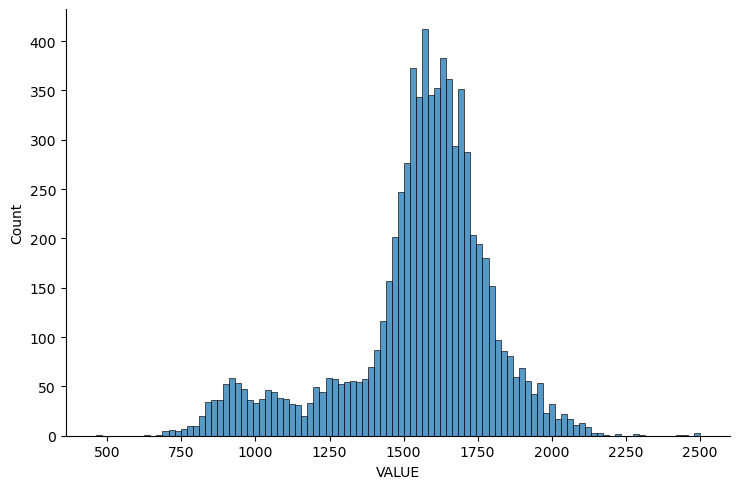

```
Histgram for testing dataset
```

```python
print("Histogram for training dataset") # testing dataset")
dfa_Target_To_Analysis.print_histogram(0)

print("Histgram for testing dataset")
dfa_Target_To_Analysis.print_histogram(1)
```

Final output for "Average annual wages and salaries"

```python
dfa_Target_To_Analysis = [training_df_AvgAnnWages, testing_df_AvgAnnWages]
dfa_Target_To_Analysis = Target_To_Analysis(dfa_Target_To_Analysis, pd, np, pp, sns, ['training set','testing set'])
dfa_Target_To_Analysis.print_result()
```

```
training set
                                          sum          mean     amin   median  \
Characteristics
15 to 24 years                      5844745.0  15220.690104   8769.0  14305.5
25 to 34 years                     16279492.0  38760.695238  23433.0  37717.0
35 to 44 years                     22063695.0  52532.607143  33680.0  51506.0
45 to 54 years                     23873488.0  56841.638095  30761.0  55972.0
55 to 64 years                     22698208.0  54043.352381  28716.0  51361.5
65 years old and over              12199299.0  31769.007812  14168.0  29624.0
College diploma                    18964213.0  45152.888095  26342.0  42893.0
Female employees                   17243175.0  41055.178571  23619.0  39648.0
High school diploma and less       12141489.0  28908.307143  13589.0  27359.0
Immigrant employees                17912206.0  45232.843434  19120.0  43440.0
Indigenous identity employees      14848864.0  37497.131313  17941.0  36050.0
Male employees                     21447737.0  51066.040476  27041.0  50031.0
Non-immigrant employees            17449574.0  44064.580808  25240.0  43019.0
Non-indigenous identity employees  19382927.0  48946.785354  25912.0  45276.5
Not a visible minority             20721779.0  49337.569048  25056.0  45545.0
Trade certificate                  15485493.0  39104.780303  19906.0  37425.5
University degree and higher       22886417.0  57793.982323  34291.0  55882.5
Visible minority                   16333930.0  38890.309524  20018.0  37778.0

                                       amax  size
Characteristics
15 to 24 years                      39963.0   384
25 to 34 years                      69687.0   420
35 to 44 years                      92783.0   420
45 to 54 years                      94580.0   420
55 to 64 years                     113680.0   420
65 years old and over               81488.0   384
College diploma                     90409.0   420
Female employees                    75960.0   420
High school diploma and less        55242.0   420
Immigrant employees                105045.0   396
Indigenous identity employees       70523.0   396
Male employees                      95519.0   420
Non-immigrant employees             79641.0   396
Non-indigenous identity employees  106109.0   396
Not a visible minority             106573.0   420
Trade certificate                   81722.0   396
```

[output cut: 44 more lines]

[output not shown]

```
Histogram for training dataset
```

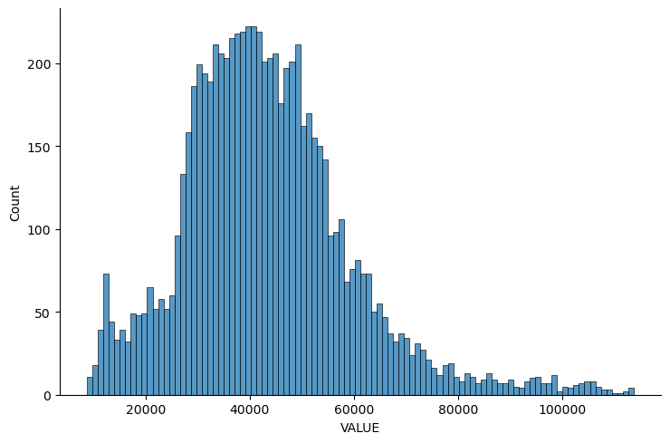

```
Histgram for testing dataset
```

```python
print("Histogram for training dataset") # testing dataset")
dfa_Target_To_Analysis.print_histogram(0)

print("Histgram for testing dataset")
dfa_Target_To_Analysis.print_histogram(1)
```

Final output for "Average hourly wage"

```python
dfa_Target_To_Analysis = [training_df_AvgHrsWages, testing_df_AvgHrsWages]
dfa_Target_To_Analysis = Target_To_Analysis(dfa_Target_To_Analysis, pd, np, pp, sns, ['training set','testing set'])
dfa_Target_To_Analysis.print_result()
```

```
training set
                                        sum       mean   amin  median   amax  \
Characteristics
15 to 24 years                      6394.37  16.652005  11.70  15.830  33.72
25 to 34 years                     10151.74  24.170810  15.07  23.265  47.75
35 to 44 years                     12429.33  29.593643  17.22  29.065  54.92
45 to 54 years                     13001.51  30.955976  16.89  30.625  56.39
55 to 64 years                     13540.12  32.238381  16.73  30.490  63.53
65 years old and over              11253.83  29.306849  15.90  27.780  69.41
College diploma                    11423.95  27.199881  15.59  25.745  55.36
Female employees                   11253.54  26.794143  15.83  25.925  50.72
High school diploma and less        9141.89  21.766405  12.76  20.985  38.43
Immigrant employees                10867.07  27.442096  13.35  25.855  57.56
Indigenous identity employees      10120.34  25.556414  14.92  24.600  47.74
Male employees                     12929.73  30.785071  15.78  29.730  57.11
Non-immigrant employees            11128.84  28.103131  16.38  27.350  52.22
Non-indigenous identity employees  11811.08  29.825960  16.71  28.470  61.93
Not a visible minority             12583.56  29.960857  16.33  28.485  63.00
Trade certificate                   9828.67  24.819874  14.10  23.920  44.18
University degree and higher       13154.99  33.219672  18.40  32.005  68.02
Visible minority                   10881.27  25.907786  13.59  25.035  48.89

                                   size
Characteristics
15 to 24 years                      384
25 to 34 years                      420
35 to 44 years                      420
45 to 54 years                      420
55 to 64 years                      420
65 years old and over               384
College diploma                     420
Female employees                    420
High school diploma and less        420
Immigrant employees                 396
Indigenous identity employees       396
Male employees                      420
Non-immigrant employees             396
Non-indigenous identity employees   396
Not a visible minority              420
Trade certificate                   396
```

[output cut: 44 more lines]

[output not shown]

```
Histogram for training dataset
```

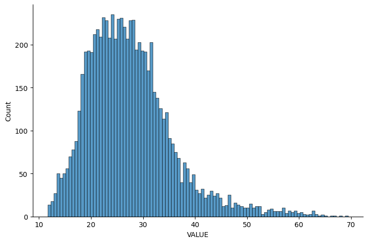

```
Histgram for testing dataset
```

```python
print("Histogram for training dataset") # testing dataset")
dfa_Target_To_Analysis.print_histogram(0)

print("Histgram for testing dataset")
dfa_Target_To_Analysis.print_histogram(1)
```

Final output for "Average weekly hours worked"

```python
dfa_Target_To_Analysis = [training_df_AvgWeekHrsWrked, testing_df_AvgWeekHrsWrked]
dfa_Target_To_Analysis = Target_To_Analysis(dfa_Target_To_Analysis, pd, np, pp, sns, ['training set','testing set'])
dfa_Target_To_Analysis.print_result()
```

```
training set
                                       sum       mean  amin  median  amax  \
Characteristics
15 to 24 years                      6701.0  17.450521   9.0    18.0  23.0
25 to 34 years                     13045.0  31.059524  24.0    31.0  38.0
35 to 44 years                     14441.0  34.383333  28.0    34.0  42.0
45 to 54 years                     14869.0  35.402381  29.0    35.0  44.0
55 to 64 years                     13528.0  32.209524  27.0    32.0  38.0
65 years old and over               7948.0  20.697917  13.0    21.0  29.0
College diploma                    13453.0  32.030952  27.0    32.0  39.0
Female employees                   12380.0  29.476190  24.0    30.0  33.0
High school diploma and less       10649.0  25.354762  20.0    25.0  32.0
Immigrant employees                12463.0  31.472222  26.0    31.0  48.0
Indigenous identity employees      11198.0  28.277778  20.0    29.0  34.0
Male employees                     13436.0  31.990476  27.0    32.0  38.0
Non-immigrant employees            11969.0  30.224747  25.0    30.0  34.0
Non-indigenous identity employees  12365.0  31.224747  28.0    31.0  40.0
Not a visible minority             13164.0  31.342857  28.0    31.0  41.0
Trade certificate                  11956.0  30.191919  17.0    30.0  37.0
University degree and higher       13285.0  33.547980  29.0    33.0  40.0
Visible minority                   12109.0  28.830952  23.0    29.0  33.0

                                   size
Characteristics
15 to 24 years                      384
25 to 34 years                      420
35 to 44 years                      420
45 to 54 years                      420
55 to 64 years                      420
65 years old and over               384
College diploma                     420
Female employees                    420
High school diploma and less        420
Immigrant employees                 396
Indigenous identity employees       396
Male employees                      420
Non-immigrant employees             396
Non-indigenous identity employees   396
Not a visible minority              420
Trade certificate                   396
```

[output cut: 44 more lines]

[output not shown]

```
Histogram for training dataset
```

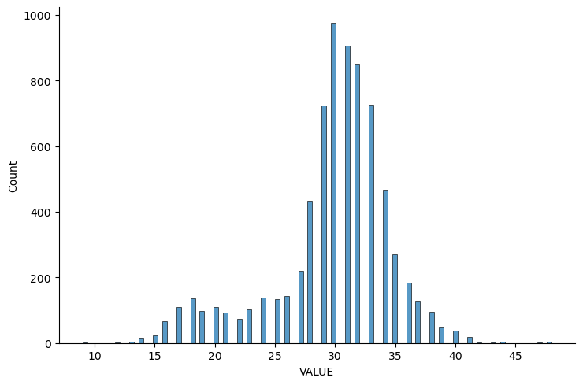

```
Histgram for testing dataset
```

```python
print("Histogram for training dataset") # testing dataset")
dfa_Target_To_Analysis.print_histogram(0)

print("Histgram for testing dataset")
dfa_Target_To_Analysis.print_histogram(1)
```

Final output for "Hours Worked"

```python
dfa_Target_To_Analysis = [training_df_Hrs_Wrked, testing_df_Hrs_Wrked]
dfa_Target_To_Analysis = Target_To_Analysis(dfa_Target_To_Analysis, pd, np, pp, sns, ['training set','testing set'])
dfa_Target_To_Analysis.print_result()
```

```
training set
                                          sum           mean   amin   median  \
Characteristics
15 to 24 years                      6319354.0   16456.651042    6.0   4000.0
25 to 34 years                     21892318.0   52124.566667   32.0   9676.5
35 to 44 years                     23526930.0   56016.500000   32.0  10443.5
45 to 54 years                     26229128.0   62450.304762   29.0  10857.5
55 to 64 years                     20321678.0   48384.947619   20.0   8825.5
65 years old and over               4298529.0   11194.085938   26.0   2495.5
College diploma                    27470020.0   65404.809524   30.0  10379.5
Female employees                   69941334.0  166526.985714   57.0  27674.0
High school diploma and less       18744590.0   44629.976190   54.0  11567.5
Immigrant employees                25508532.0   64415.484848   41.0   6476.5
Indigenous identity employees       4180002.0   10555.560606   29.0   3205.0
Male employees                     32650634.0   77739.604762   64.0  15635.5
Non-immigrant employees            77066569.0  194612.547980  258.0  48139.0
Non-indigenous identity employees  98301463.0  248236.017677   41.0  49512.5
Not a visible minority             77459338.0  184426.995238   38.0  31467.0
Trade certificate                   7294759.0   18421.108586   20.0   3518.5
University degree and higher       49076023.0  123929.351010   88.0  22172.5
Visible minority                   25132644.0   59839.628571   31.0   6632.0

                                        amax  size
Characteristics
15 to 24 years                      225988.0   384
25 to 34 years                      824205.0   420
35 to 44 years                      892149.0   420
45 to 54 years                      955066.0   420
55 to 64 years                      754767.0   420
65 years old and over               168451.0   384
College diploma                    1008742.0   420
Female employees                   2635646.0   420
High school diploma and less        650689.0   420
Immigrant employees                 992945.0   396
Indigenous identity employees       160238.0   396
Male employees                     1168542.0   420
Non-immigrant employees            2811247.0   396
Non-indigenous identity employees  3643952.0   396
Not a visible minority             2796649.0   420
Trade certificate                   276386.0   396
```

[output cut: 44 more lines]

[output not shown]

```
Histogram for training dataset
```

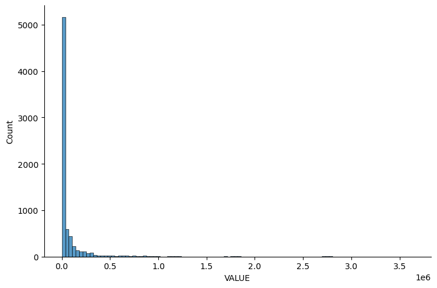

```
Histgram for testing dataset
```

```python
print("Histogram for training dataset") # testing dataset")
dfa_Target_To_Analysis.print_histogram(0)

print("Histgram for testing dataset")
dfa_Target_To_Analysis.print_histogram(1)
```

Final output for "Number of jobs"

```python
dfa_Target_To_Analysis = [training_df_NumOfJob, testing_df_NumOfJob]
dfa_Target_To_Analysis = Target_To_Analysis(dfa_Target_To_Analysis, pd, np, pp, sns, ['training set','testing set'])
dfa_Target_To_Analysis.print_result()
```

```
training set
                                          sum           mean   amin   median  \
Characteristics
15 to 24 years                      7043629.0   18342.783854   13.0   4215.0
25 to 34 years                     13985914.0   33299.795238   17.0   5885.0
35 to 44 years                     13654580.0   32510.904762   18.0   5906.0
45 to 54 years                     14554094.0   34652.604762   14.0   5993.0
55 to 64 years                     12313508.0   29317.876190   11.0   5355.0
65 years old and over               4150652.0   10808.989583   18.0   2306.5
College diploma                    17030502.0   40548.814286   16.0   6147.5
Female employees                   45510332.0  108357.933333   35.0  18345.5
High school diploma and less       14427614.0   34351.461905   36.0   8041.5
Immigrant employees                16175470.0   40847.146465   19.0   3842.0
Indigenous identity employees       2799914.0    7070.489899   20.0   2104.5
Male employees                     20196478.0   48086.852381   36.0   9064.0
Non-immigrant employees            49519813.0  125050.032828  161.0  29737.0
Non-indigenous identity employees  62840251.0  158687.502525   21.0  29789.0
Not a visible minority             49207940.0  117161.761905   19.0  20375.5
Trade certificate                   4730099.0   11944.694444   13.0   2068.0
University degree and higher       29514630.0   74531.893939   42.0  12694.0
Visible minority                   16498878.0   39283.042857   22.0   4373.0

                                        amax  size
Characteristics
15 to 24 years                      246749.0   384
25 to 34 years                      527094.0   420
35 to 44 years                      516879.0   420
45 to 54 years                      530812.0   420
55 to 64 years                      453209.0   420
65 years old and over               162525.0   384
College diploma                     622081.0   420
Female employees                   1696408.0   420
High school diploma and less        501836.0   420
Immigrant employees                 626191.0   396
Indigenous identity employees       106260.0   396
Male employees                      726750.0   420
Non-immigrant employees            1796966.0   396
Non-indigenous identity employees  2316901.0   396
Not a visible minority             1768587.0   420
Trade certificate                   178883.0   396
```

[output cut: 44 more lines]

[output not shown]

```
Histogram for training dataset
```

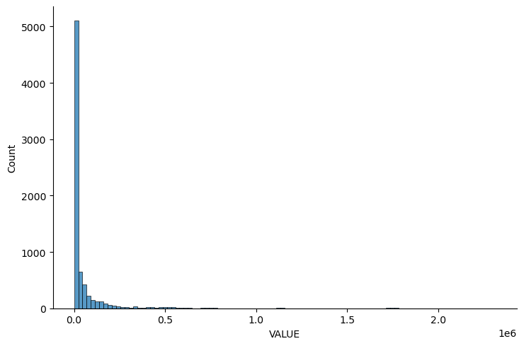

```
Histgram for testing dataset
```

```python
print("Histogram for training dataset") # testing dataset")
dfa_Target_To_Analysis.print_histogram(0)

print("Histgram for testing dataset")
dfa_Target_To_Analysis.print_histogram(1)
```

Final output for "Wages and Salaries"

```python
dfa_Target_To_Analysis = [training_df_WagesAndSalaries, testing_df_WagesAndSalaries]
dfa_Target_To_Analysis = Target_To_Analysis(dfa_Target_To_Analysis, pd, np, pp, sns, ['training set','testing set'])
dfa_Target_To_Analysis.print_result()
```

```
training set
                                         sum         mean  amin  median  \
Characteristics
15 to 24 years                      108973.0   283.783854   0.0    63.0
25 to 34 years                      538547.0  1282.254762   1.0   211.0
35 to 44 years                      710804.0  1692.390476   1.0   252.5
45 to 54 years                      842807.0  2006.683333   1.0   285.5
55 to 64 years                      657465.0  1565.392857   1.0   228.0
65 years old and over               138783.0   361.414062   1.0    66.5
College diploma                     734205.0  1748.107143   1.0   232.5
Female employees                   1953878.0  4652.090476   2.0   592.5
High school diploma and less        399426.0   951.014286   2.0   232.0
Immigrant employees                 749325.0  1892.234848   1.0   172.5
Indigenous identity employees       104776.0   264.585859   1.0    77.0
Male employees                     1043622.0  2484.814286   3.0   510.0
Non-immigrant employees            2247605.0  5675.770202   9.0  1252.0
Non-indigenous identity employees  2890419.0  7299.037879   2.0  1475.0
Not a visible minority             2310666.0  5501.585714   1.0   825.5
Trade certificate                   173261.0   437.527778   1.0    93.0
University degree and higher       1690370.0  4268.611111   3.0   738.5
Visible minority                    686815.0  1635.273810   0.0   173.0

                                       amax  size
Characteristics
15 to 24 years                       4250.0   384
25 to 34 years                      21911.0   420
35 to 44 years                      28840.0   420
45 to 54 years                      32326.0   420
55 to 64 years                      25923.0   420
65 years old and over                5823.0   384
College diploma                     28612.0   420
Female employees                    79028.0   420
High school diploma and less        14711.0   420
Immigrant employees                 31105.0   396
Indigenous identity employees        4333.0   396
Male employees                      40045.0   420
Non-immigrant employees             87968.0   396
Non-indigenous identity employees  114740.0   396
Not a visible minority              89565.0   420
Trade certificate                    6433.0   396
```

[output cut: 44 more lines]

[output not shown]

```
Histogram for training dataset
```

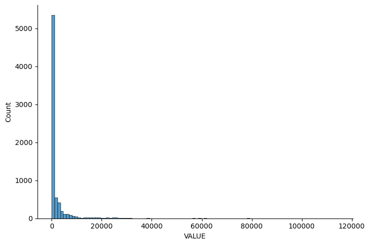

```
Histgram for testing dataset
```

```python
print("Histogram for training dataset")
dfa_Target_To_Analysis.print_histogram(0)

print("Histgram for testing dataset")
dfa_Target_To_Analysis.print_histogram(1)
```

```python
print("Final steps, by sorting out by provinces.")

# -- sum          mean           std  size
# -- GEO
# -- Alberta                     2193966.0   2031.450000   2695.836034  1080
# -- British Columbia            2401296.0   2223.422222   2804.925187  1080
# -- Canada                     18252439.0  16900.406481  22232.852533  1080
# -- Manitoba                     767802.0    710.927778    915.637659  1080
# -- New Brunswick                359320.0    332.703704    530.962762  1080
# -- Newfoundland and Labrador    315895.0    306.099806    482.634908  1032
# -- Northwest Territories         42804.0     41.476744     51.817046  1032
# -- Nova Scotia                  531805.0    492.412037    757.119411  1080
# -- Nunavut                       14235.0     15.208333     14.752372   936
# -- Ontario                     6601634.0   6112.624074   7594.433779  1080
# -- Prince Edward Island          77931.0     75.514535    121.297367  1032
# -- Quebec                      4271657.0   3955.237963   5580.294544  1080
# -- Saskatchewan                 650781.0    602.575000    876.896377  1080
# -- Yukon                         16914.0     18.070513     20.188135   936
# -- The total number of this one is  14688
```

```
Final steps, by sorting out by provinces.
```

As final step, I am classifying the data by province. This is the final step, and this is where I will get the final result with.  
For this step, I will use class methods to avoid duplicated and repeatitive steps to do programming.  
For the complex of the analysis, only training (2013-2018) and testing set (2019-2021) are being used.  
However, 2010-2012 one will get commented.

Main class for Province Analysis:

```python
# https://www.w3schools.com/python/python_classes.asp
# https://www.w3schools.com/python/python_for_loops.asp
# https://www.educba.com/multidimensional-array-in-python/

class ProvinceAnalysis:

    # Province :
    # -- ['Alberta',  'British Columbia',    'Canada' , 'Manitoba' , 'New Brunswick'
    # 'Newfoundland and Labrador', 'Northwest Territories' , 'Nova Scotia' , 'Nunavut'
    # 'Ontario' , 'Prince Edward Island', 'Quebec', 'Saskatchewan', 'Yukon']

    def __init__(self, df, pd, np, pp):
        self.df = df
        self.province = ['Alberta',  'British Columbia', 'Canada', 'Manitoba',
                        'New Brunswick', 'Newfoundland and Labrador',
                        'Northwest Territories' , 'Nova Scotia' , 'Nunavut',
                        'Ontario' , 'Prince Edward Island', 'Quebec',
                        'Saskatchewan', 'Yukon'
                        ]
        self.indicator = ["Average annual hours worked",
                        "Average annual wages and salaries",
                        "Average hourly wage",
                        "Average weekly hours worked",
                        "Hours Worked",
                        "Number of jobs",
                        "Wages and Salaries"]
        self.characteristic = ["Age group", "Gender", "Education Level", "Immigrant status", "Aboriginal status"]
        self.year = ["2010",
                    "below 2015",
                    "above 2016",
                    "2013",
                    "2016",
                    "2019"]
        self.pd = pd
        self.np = np
        self.pp = pp
        self.df_ByProvince = []
        for x in self.province:
            df_sorted = df.loc[df['GEO'] == x]
            self.df_ByProvince.append(df_sorted)

    def outputProvince(self, province_id):
        print(self.province[province_id])

    def outputIndicator(self, indicator_id):
        print(self.province[indicator_id])

    def outputCharacteristic(self, cha_id):
        print(self.province[cha_id])

    def outputYear(self, year_id):
        print(self.province[year_id])

    def outputAnalysis(self, province_id):
        print("\nGrab the dataset only in " + str(self.province[province_id]))
        grouped = self.df_ByProvince[province_id].groupby(['Characteristics'])
        print(grouped['VALUE'].agg([np.sum, np.mean, np.min, np.median, np.max, np.size]))
        print("")
        print("Overall,")
        print("Sum : ",np.sum(self.df_ByProvince[province_id]['VALUE']))
        print("Mean : ",np.mean(self.df_ByProvince[province_id]['VALUE']))
        print("Min/median/max :",np.min(self.df_ByProvince[province_id]['VALUE']),"/",
            np.median(self.df_ByProvince[province_id]['VALUE']),"/",
            np.max(self.df_ByProvince[province_id]['VALUE']))
        print("Skewnewss : ",self.df_ByProvince[province_id]['VALUE'].skew())
        print("Total size : ",len(self.df_ByProvince[province_id].index))

    def outputAnalysisSimple(self, province_id):
        print("\nGrab the dataset only in " + str(self.province[province_id]))
        grouped = self.df_ByProvince[province_id].groupby(['Characteristics'])
        print(grouped['VALUE'].agg([self.np.sum, self.np.mean, self.np.size]))

    def outputList(self, province_id, num):
        print("\nGrab the dataset only in " + str(self.province[province_id]))
        print(self.df_ByProvince[province_id].head(num))
        print(self.df_ByProvince[province_id].info())

    def outputPandaProfiling(self, province_id, indicator_id, type_id):

        fileName = str(self.indicator[indicator_id]) + " " + str(self.year[type_id])+" in " + str(self.province[province_id]) + ".html"

        pp = ProfileReport(self.df_ByProvince[province_id])
        pp_df = pp.to_html()

        print("File name will be saved under "+str(fileName))
        f = open(fileName, "a")  # Expert into html file without modifying any columns in dataset.
        f.write(pp_df)
        f.close()

    def print_histogram(self, province_id):
        sns.displot(data=self.province[province_id], x="VALUE", kind="hist", bins = 100, aspect = 1.5)
        plt.show()

    def outputFiveProvinces(self, pro1, pro2, pro3, pro4, pro5):
        frames = [self.df_ByProvince[pro1], self.df_ByProvince[pro2], self.df_ByProvince[pro3], self.df_ByProvince[pro4], self.df_ByProvince[pro5]]
        result = pd.concat(frames)
        return result
```

Filtered by provinces by "Average annual hours worked"

```python
# By Average annual hours worked categories by provinces.

training_df_AvgAnnHrsWrk_ByAge_Provinces = ProvinceAnalysis(training_df_AvgAnnHrsWrk_ByAge, pd, np, pp)
testing_df_AvgAnnHrsWrk_ByAge_Provinces = ProvinceAnalysis(testing_df_AvgAnnHrsWrk_ByAge, pd, np, pp)

training_df_AvgAnnHrsWrk_ByGender_Provinces = ProvinceAnalysis(training_df_AvgAnnHrsWrk_ByGender, pd, np, pp)
testing_df_AvgAnnHrsWrk_ByGender_Provinces = ProvinceAnalysis(testing_df_AvgAnnHrsWrk_ByGender, pd, np, pp)

training_df_AvgAnnHrsWrk_ByEducation_Provinces = ProvinceAnalysis(training_df_AvgAnnHrsWrk_ByEducation, pd, np, pp)
testing_df_AvgAnnHrsWrk_ByEducation_Provinces = ProvinceAnalysis(testing_df_AvgAnnHrsWrk_ByEducation, pd, np, pp)

training_df_AvgAnnHrsWrk_ByImmigrant_Provinces = ProvinceAnalysis(training_df_AvgAnnHrsWrk_ByImmigrant, pd, np, pp)
testing_df_AvgAnnHrsWrk_ByImmigrant_Provinces = ProvinceAnalysis(testing_df_AvgAnnHrsWrk_ByImmigrant, pd, np, pp)

# training_df_AvgAnnHrsWrk_ByIndigenous_Provinces = ProvinceAnalysis(training_df_AvgAnnHrsWrk_ByIndigenous, pd, np, pp)
# testing_df_AvgAnnHrsWrk_ByIndigenous_Provinces = ProvinceAnalysis(testing_df_AvgAnnHrsWrk_ByIndigenous, pd, np, pp)
```

Filtered by provinces by "Average wages and salaries"

```python
# By Average annual wages and salaries worked categories by provinces.

training_df_AvgAnnWages_ByAge_Provinces = ProvinceAnalysis(training_df_AvgAnnWages_ByAge, pd, np, pp)
testing_df_AvgAnnWages_ByAge_Provinces = ProvinceAnalysis(testing_df_AvgAnnWages_ByAge, pd, np, pp)

training_df_AvgAnnWages_ByGender_Provinces = ProvinceAnalysis(training_df_AvgAnnWages_ByGender, pd, np, pp)
testing_df_AvgAnnWages_ByGender_Provinces = ProvinceAnalysis(testing_df_AvgAnnWages_ByGender, pd, np, pp)

training_df_AvgAnnWages_ByEducation_Provinces = ProvinceAnalysis(training_df_AvgAnnWages_ByEducation, pd, np, pp)
testing_df_AvgAnnWages_ByEducation_Provinces = ProvinceAnalysis(testing_df_AvgAnnWages_ByEducation, pd, np, pp)

training_df_AvgAnnWages_ByImmigrant_Provinces = ProvinceAnalysis(training_df_AvgAnnWages_ByImmigrant, pd, np, pp)
testing_df_AvgAnnWages_ByImmigrant_Provinces = ProvinceAnalysis(testing_df_AvgAnnWages_ByImmigrant, pd, np, pp)

# training_df_AvgAnnWages_ByIndigenous_Provinces = ProvinceAnalysis(training_df_AvgAnnWages_ByIndigenous, pd, np, pp)
# testing_df_AvgAnnWages_ByIndigenous_Provinces = ProvinceAnalysis(testing_df_AvgAnnWages_ByIndigenous, pd, np, pp)
```

Filtered by provinces by "Average hourly wage"

```python
# By Average hourly wages and salaries worked categories by provinces.

training_df_AvgHrsWages_ByAge_Provinces = ProvinceAnalysis(training_df_AvgHrsWages_ByAge, pd, np, pp)
testing_df_AvgHrsWages_ByAge_Provinces = ProvinceAnalysis(testing_df_AvgHrsWages_ByAge, pd, np, pp)

training_df_AvgHrsWages_ByGender_Provinces = ProvinceAnalysis(training_df_AvgHrsWages_ByGender, pd, np, pp)
testing_df_AvgHrsWages_ByGender_Provinces = ProvinceAnalysis(testing_df_AvgHrsWages_ByGender, pd, np, pp)

training_df_AvgHrsWages_ByEducation_Provinces = ProvinceAnalysis(training_df_AvgHrsWages_ByEducation, pd, np, pp)
testing_df_AvgHrsWages_ByEducation_Provinces = ProvinceAnalysis(testing_df_AvgHrsWages_ByEducation, pd, np, pp)

training_df_AvgHrsWages_ByImmigrant_Provinces = ProvinceAnalysis(training_df_AvgHrsWages_ByImmigrant, pd, np, pp)
testing_df_AvgHrsWages_ByImmigrant_Provinces = ProvinceAnalysis(testing_df_AvgHrsWages_ByImmigrant, pd, np, pp)

# training_df_AvgHrsWages_ByIndigenous_Provinces = ProvinceAnalysis(training_df_AvgHrsWages_ByIndigenous, pd, np, pp)
# testing_df_AvgHrsWages_ByIndigenous_Provinces = ProvinceAnalysis(testing_df_AvgHrsWages_ByIndigenous, pd, np, pp)
```

Filtered by provinces by "Average weekly hours worked"

```python
# By Average annual wages and salaries worked categories by provinces.

training_df_AvgWeekHrsWrked_ByAge_Provinces = ProvinceAnalysis(training_df_AvgWeekHrsWrked_ByAge, pd, np, pp)
testing_df_AvgWeekHrsWrked_ByAge_Provinces = ProvinceAnalysis(testing_df_AvgWeekHrsWrked_ByAge, pd, np, pp)

training_df_AvgWeekHrsWrked_ByGender_Provinces = ProvinceAnalysis(training_df_AvgWeekHrsWrked_ByGender, pd, np, pp)
testing_df_AvgWeekHrsWrked_ByGender_Provinces = ProvinceAnalysis(testing_df_AvgWeekHrsWrked_ByGender, pd, np, pp)

training_df_AvgWeekHrsWrked_ByEducation_Provinces = ProvinceAnalysis(training_df_AvgWeekHrsWrked_ByEducation, pd, np, pp)
testing_df_AvgWeekHrsWrked_ByEducation_Provinces = ProvinceAnalysis(testing_df_AvgWeekHrsWrked_ByEducation, pd, np, pp)

training_df_AvgWeekHrsWrked_ByImmigrant_Provinces = ProvinceAnalysis(training_df_AvgWeekHrsWrked_ByImmigrant, pd, np, pp)
testing_df_AvgWeekHrsWrked_ByImmigrant_Provinces = ProvinceAnalysis(testing_df_AvgWeekHrsWrked_ByImmigrant, pd, np, pp)

# training_df_AvgWeekHrsWrked_ByIndigenous_Provinces = ProvinceAnalysis(training_df_AvgWeekHrsWrked_ByIndigenous, pd, np, pp)
# testing_df_AvgWeekHrsWrked_ByIndigenous_Provinces = ProvinceAnalysis(testing_df_AvgWeekHrsWrked_ByIndigenous, pd, np, pp)
```

Filtered by provinces by "Hours Worked"

```python
# By Hours worked and salaries worked categories by provinces.

training_df_Hrs_Wrked_ByAge_Provinces = ProvinceAnalysis(training_df_Hrs_Wrked_ByAge, pd, np, pp)
testing_df_Hrs_Wrked_ByAge_Provinces = ProvinceAnalysis(testing_df_Hrs_Wrked_ByAge, pd, np, pp)

training_df_Hrs_Wrked_ByGender_Provinces = ProvinceAnalysis(training_df_Hrs_Wrked_ByGender, pd, np, pp)
testing_df_Hrs_Wrked_ByGender_Provinces = ProvinceAnalysis(testing_df_Hrs_Wrked_ByGender, pd, np, pp)

training_df_Hrs_Wrked_ByEducation_Provinces = ProvinceAnalysis(training_df_Hrs_Wrked_ByEducation, pd, np, pp)
testing_df_Hrs_Wrked_ByEducation_Provinces = ProvinceAnalysis(testing_df_Hrs_Wrked_ByEducation, pd, np, pp)

training_df_Hrs_Wrked_ByImmigrant_Provinces = ProvinceAnalysis(training_df_Hrs_Wrked_ByImmigrant, pd, np, pp)
testing_df_Hrs_Wrked_ByImmigrant_Provinces = ProvinceAnalysis(testing_df_Hrs_Wrked_ByImmigrant, pd, np, pp)

# training_df_Hrs_Wrked_ByIndigenous_Provinces = ProvinceAnalysis(training_df_Hrs_Wrked_ByIndigenous, pd, np, pp)
# testing_df_Hrs_Wrked_ByIndigenous_Provinces = ProvinceAnalysis(testing_df_Hrs_Wrked_ByIndigenous, pd, np, pp)
```

Filtered by provinces by "Number of jobs"

```python
# By Number of jobs and salaries worked categories by provinces.

training_df_NumOfJob_ByAge_Provinces = ProvinceAnalysis(training_df_NumOfJob_ByAge, pd, np, pp)
testing_df_NumOfJob_ByAge_Provinces = ProvinceAnalysis(testing_df_NumOfJob_ByAge, pd, np, pp)

training_df_NumOfJob_ByGender_Provinces = ProvinceAnalysis(training_df_NumOfJob_ByGender, pd, np, pp)
testing_df_NumOfJob_ByGender_Provinces = ProvinceAnalysis(testing_df_NumOfJob_ByGender, pd, np, pp)

training_df_NumOfJob_ByEducation_Provinces = ProvinceAnalysis(training_df_NumOfJob_ByEducation, pd, np, pp)
testing_df_NumOfJob_ByEducation_Provinces = ProvinceAnalysis(testing_df_NumOfJob_ByEducation, pd, np, pp)

training_df_NumOfJob_ByImmigrant_Provinces = ProvinceAnalysis(training_df_NumOfJob_ByImmigrant, pd, np, pp)
testing_df_NumOfJob_ByImmigrant_Provinces = ProvinceAnalysis(testing_df_NumOfJob_ByImmigrant, pd, np, pp)

# training_df_NumOfJob_ByIndigenous_Provinces = ProvinceAnalysis(training_df_NumOfJob_ByIndigenous, pd, np, pp)
# testing_df_NumOfJob_ByIndigenous_Provinces = ProvinceAnalysis(testing_df_NumOfJob_ByIndigenous, pd, np, pp)
```

Filted by provinces by "Wages and Salaries"

```python
# By Wages and Salaries worked categories by provinces.

training_df_WagesAndSalaries_ByAge_Provinces = ProvinceAnalysis(training_df_WagesAndSalaries_ByAge, pd, np, pp)
testing_df_WagesAndSalaries_ByAge_Provinces = ProvinceAnalysis(testing_df_WagesAndSalaries_ByAge, pd, np, pp)

training_df_WagesAndSalaries_ByGender_Provinces = ProvinceAnalysis(training_df_WagesAndSalaries_ByGender, pd, np, pp)
testing_df_WagesAndSalaries_ByGender_Provinces = ProvinceAnalysis(testing_df_WagesAndSalaries_ByGender, pd, np, pp)

training_df_WagesAndSalaries_ByEducation_Provinces = ProvinceAnalysis(training_df_WagesAndSalaries_ByEducation, pd, np, pp)
testing_df_WagesAndSalaries_ByEducation_Provinces = ProvinceAnalysis(testing_df_WagesAndSalaries_ByEducation, pd, np, pp)

training_df_WagesAndSalaries_ByImmigrant_Provinces = ProvinceAnalysis(training_df_WagesAndSalaries_ByImmigrant, pd, np, pp)
testing_df_WagesAndSalaries_ByImmigrant_Provinces = ProvinceAnalysis(testing_df_WagesAndSalaries_ByImmigrant, pd, np, pp)

# training_df_WagesAndSalaries_ByIndigenous_Provinces = ProvinceAnalysis(training_df_WagesAndSalaries_ByIndigenous, pd, np, pp)
# testing_df_WagesAndSalaries_ByIndigenous_Provinces = ProvinceAnalysis(testing_df_WagesAndSalaries_ByIndigenous, pd, np, pp)
```

Since there will be too many datasets to deal with if I were to working with many provinces.  
Instead I will be selected only five provinces to work on and will be put it in one database.

Class methods to deal with five provinces,

```python
class FiveProvinceAnalysis:

    # Province :
    # -- ['Alberta',  'British Columbia',    'Canada' , 'Manitoba' , 'New Brunswick'
    # 'Newfoundland and Labrador', 'Northwest Territories' , 'Nova Scotia' , 'Nunavut'
    # 'Ontario' , 'Prince Edward Island', 'Quebec', 'Saskatchewan', 'Yukon']

    def __init__(self, df, pd, np, pp):

        # Based on this result, https://www.linkedin.com/pulse/5-best-provinces-canada-look-jobs-2023-/
        # Five popular province for employments, ['Alberta', 'BC', 'Nova Scotia', 'Ontario', 'Quebec']

        temp_df = df.outputFiveProvinces(0,1,7,9,11)

        self.df_FiveProvinces = temp_df.copy()
        self.one_hot_encoded_data = pd.get_dummies(temp_df, columns = ['GEO'])# , 'Characteristics'])
        # print(one_hot_encoded_data)

    def print_Unique(self, to_id):
        print(self.df_FiveProvinces[to_id].unique())

    def print_Province_Unique(self):
        self.print_Unique('GEO')

    def print_Value_Counts(self, to_id):
        print(self.df_FiveProvinces[to_id].value_counts())

    def print_Province_Value_Counts(self):
        self.print_Value_Count('GEO')

    def print_One_Hot_Encoded_Data(self):
        print(self.one_hot_encoded_data.head(20))

    def print_One_Hot_Encoded_Data_Info(self):
        print(self.one_hot_encoded_data.info())

    def output_One_Hot_Encoded_Data(self):
        return self.one_hot_encoded_data

    def output_Original_Data(self):
        return self.df_FiveProvinces

    def print_Analysis_Provinces(self):
        print("Five popular province for employments,")
        print(self.print_Province_Unique())
        print("Sources: https://www.linkedin.com/pulse/5-best-provinces-canada-look-jobs-2023-/")

    def print_AnalysisResult_ByCharacteristics(self):
        grouped = self.df_FiveProvinces.groupby(['Characteristics'])
        print(grouped['VALUE'].agg([np.sum, np.mean, np.min, np.median, np.max, np.std, np.size]))
        print("")
        print("Overall,")
        print("Sum : ",np.sum(self.df_FiveProvinces['VALUE']))
        print("Mean : ",np.mean(self.df_FiveProvinces['VALUE']))
        print("Min/median/max :",np.min(self.df_FiveProvinces['VALUE']),"/",
            np.median(self.df_FiveProvinces['VALUE']),"/",
            np.max(self.df_FiveProvinces['VALUE']))
        print("Standard Deviation: ",np.std(self.df_FiveProvinces['VALUE']))
        print("Skewnewss : ",self.df_FiveProvinces['VALUE'].skew())
        print("Total size : ",len(self.df_FiveProvinces.index))

    def print_AnalysisResult_ByProvinces(self):
        grouped = self.df_FiveProvinces.groupby(['GEO'])
        print(grouped['VALUE'].agg([np.sum, np.mean, np.min, np.median, np.max, np.std, np.size]))
        print("")
        print("Overall,")
        print("Sum : ",np.sum(self.df_FiveProvinces['VALUE']))
        print("Mean : ",np.mean(self.df_FiveProvinces['VALUE']))
        print("Min/median/max :",np.min(self.df_FiveProvinces['VALUE']),"/",
            np.median(self.df_FiveProvinces['VALUE']),"/",
            np.max(self.df_FiveProvinces['VALUE']))
        print("Standard Deviation: ",np.std(self.df_FiveProvinces['VALUE']))
        print("Skewnewss : ",self.df_FiveProvinces['VALUE'].skew())
        print("Total size : ",len(self.df_FiveProvinces.index))

    def print_histogram(self):
        sns.displot(data=self.df_FiveProvinces, x="VALUE", kind="hist", bins = 100, aspect = 1.5)
        plt.show()

    # def print_groupby_provinces(self):


    # def outputPandaProfiling(self, province_id, indicator_id, type_id):

    #     fileName = str(self.indicator[indicator_id]) + " " + str(self.year[type_id])+" in " + str(self.province[province_id]) + ".html"

    #     pp = ProfileReport(self.df_ByProvince[province_id])
    #     pp_df = pp.to_html()

    #     print("File name will be saved under "+str(fileName))
    #     f = open(fileName, "a")  # Expert into html file without modifying any columns in dataset.
    #     f.write(pp_df)
    #     f.close()
```

```python
training_df_AvgAnnHrsWrk_ByAge_FiveProvinces = FiveProvinceAnalysis(training_df_AvgAnnHrsWrk_ByAge_Provinces, pd, np, pp)
# training_df_AvgAnnHrsWrk_ByAge_FiveProvinces.print_One_Hot_Encoded_Data_Info()
testing_df_AvgAnnHrsWrk_ByAge_FiveProvinces = FiveProvinceAnalysis(testing_df_AvgAnnHrsWrk_ByAge_Provinces, pd, np, pp)

training_df_AvgAnnHrsWrk_ByGender_FiveProvinces = FiveProvinceAnalysis(training_df_AvgAnnHrsWrk_ByGender_Provinces, pd, np, pp)
# training_df_AvgAnnHrsWrk_ByGender_FiveProvinces.print_One_Hot_Encoded_Data_Info()
testing_df_AvgAnnHrsWrk_ByGender_FiveProvinces = FiveProvinceAnalysis(testing_df_AvgAnnHrsWrk_ByGender_Provinces, pd, np, pp)
# testing_df_AvgAnnHrsWrk_ByGender_FiveProvinces.print_One_Hot_Encoded_Data_Info()

training_df_AvgAnnHrsWrk_ByEducation_FiveProvinces = FiveProvinceAnalysis(training_df_AvgAnnHrsWrk_ByEducation_Provinces, pd, np, pp)
# training_df_AvgAnnHrsWrk_ByGender_FiveProvinces.print_One_Hot_Encoded_Data_Info()
testing_df_AvgAnnHrsWrk_ByEducation_FiveProvinces = FiveProvinceAnalysis(testing_df_AvgAnnHrsWrk_ByEducation_Provinces, pd, np, pp)
# testing_df_AvgAnnHrsWrk_ByGender_FiveProvinces.print_One_Hot_Encoded_Data_Info()

training_df_AvgAnnHrsWrk_ByImmigrant_FiveProvince = FiveProvinceAnalysis(training_df_AvgAnnHrsWrk_ByImmigrant_Provinces, pd, np, pp)
# training_df_AvgAnnHrsWrk_ByImmigrant_FiveProvince.print_One_Hot_Encoded_Data_Info()
testing_df_AvgAnnHrsWrk_ByImmigrant_FiveProvince = FiveProvinceAnalysis(testing_df_AvgAnnHrsWrk_ByImmigrant_Provinces, pd, np, pp)
# testing_df_AvgAnnHrsWrk_ByImmigrant_FiveProvince.print_One_Hot_Encoded_Data_Info()

# training_df_AvgAnnHrsWrk_ByIndigenous_FiveProvince = FiveProvinceAnalysis(training_df_AvgAnnHrsWrk_ByIndigenous_Provinces, pd, np, pp)
# training_df_AvgAnnHrsWrk_ByImmigrant_FiveProvince.print_One_Hot_Encoded_Data_Info()
# testing_df_AvgAnnHrsWrk_ByIndigenous_FiveProvince = FiveProvinceAnalysis(training_df_AvgAnnHrsWrk_ByIndigenous_Provinces, pd, np, pp)
# testing_df_AvgAnnHrsWrk_ByImmigrant_FiveProvince.print_One_Hot_Encoded_Data_Info()
```

```python
training_df_AvgAnnWages_ByAge_FiveProvinces = FiveProvinceAnalysis(training_df_AvgAnnWages_ByAge_Provinces, pd, np, pp)
# training_df_AvgAnnWages_ByAge_FiveProvinces.print_One_Hot_Encoded_Data_Info()
testing_df_AvgAnnWages_ByAge_FiveProvinces = FiveProvinceAnalysis(testing_df_AvgAnnWages_ByAge_Provinces, pd, np, pp)
testing_df_AvgAnnWages_ByAge_FiveProvinces.print_One_Hot_Encoded_Data_Info()

training_df_AvgAnnWages_ByGender_FiveProvinces = FiveProvinceAnalysis(training_df_AvgAnnWages_ByGender_Provinces, pd, np, pp)
# training_df_AvgAnnWages_ByGender_FiveProvinces.print_One_Hot_Encoded_Data_Info()
testing_df_AvgAnnWages_ByGender_FiveProvinces = FiveProvinceAnalysis(testing_df_AvgAnnWages_ByGender_Provinces, pd, np, pp)
# testing_df_AvgAnnWages_ByGender_FiveProvinces.print_One_Hot_Encoded_Data_Info()

training_df_AvgAnnWages_ByEducation_FiveProvinces = FiveProvinceAnalysis(training_df_AvgAnnWages_ByEducation_Provinces, pd, np, pp)
# training_df_AvgAnnWages_ByGender_FiveProvinces.print_One_Hot_Encoded_Data_Info()
testing_df_AvgAnnWages_ByEducation_FiveProvinces = FiveProvinceAnalysis(testing_df_AvgAnnWages_ByEducation_Provinces, pd, np, pp)
# testing_df_AvgAnnWages_ByGender_FiveProvinces.print_One_Hot_Encoded_Data_Info()

training_df_AvgAnnWages_ByImmigrant_FiveProvince = FiveProvinceAnalysis(training_df_AvgAnnWages_ByImmigrant_Provinces, pd, np, pp)
# training_df_AvgAnnWages_ByImmigrant_FiveProvince.print_One_Hot_Encoded_Data_Info()
testing_df_AvgAnnWages_ByImmigrant_FiveProvince = FiveProvinceAnalysis(testing_df_AvgAnnWages_ByImmigrant_Provinces, pd, np, pp)
# testing_df_AvgAnnWages_ByImmigrant_FiveProvince.print_One_Hot_Encoded_Data_Info()

# training_df_AvgAnnWages_ByIndigenous_FiveProvince = FiveProvinceAnalysis(training_df_AvgAnnWages_ByIndigenous_Provinces, pd, np, pp)
# training_df_AvgAnnWages_ByImmigrant_FiveProvince.print_One_Hot_Encoded_Data_Info()
# testing_df_AvgAnnWages_ByIndigenous_FiveProvince = FiveProvinceAnalysis(training_df_AvgAnnWages_ByIndigenous_Provinces, pd, np, pp)
# testing_df_AvgAnnWages_ByImmigrant_FiveProvince.print_One_Hot_Encoded_Data_Info()
```

```
<class 'pandas.core.frame.DataFrame'>
Index: 450 entries, 85137 to 100796
Data columns (total 13 columns):
 #   Column                Non-Null Count  Dtype
---  ------                --------------  -----
 0   REF_DATE              450 non-null    int64
 1   DGUID                 450 non-null    object
 2   Sector                450 non-null    object
 3   Characteristics       450 non-null    object
 4   Indicators            450 non-null    object
 5   UOM                   450 non-null    object
 6   SCALAR_FACTOR         450 non-null    object
 7   VALUE                 450 non-null    float64
 8   GEO_Alberta           450 non-null    bool
 9   GEO_British Columbia  450 non-null    bool
 10  GEO_Nova Scotia       450 non-null    bool
 11  GEO_Ontario           450 non-null    bool
 12  GEO_Quebec            450 non-null    bool
dtypes: bool(5), float64(1), int64(1), object(6)
memory usage: 33.8+ KB
None
```

```python
training_df_AvgHrsWages_ByAge_FiveProvinces = FiveProvinceAnalysis(training_df_AvgHrsWages_ByAge_Provinces, pd, np, pp)
# training_df_AvgHrsWages_ByAge_FiveProvinces.print_One_Hot_Encoded_Data_Info()
testing_df_AvgHrsWages_ByAge_FiveProvinces = FiveProvinceAnalysis(testing_df_AvgHrsWages_ByAge_Provinces, pd, np, pp)
testing_df_AvgHrsWages_ByAge_FiveProvinces.print_One_Hot_Encoded_Data_Info()

training_df_AvgHrsWages_ByGender_FiveProvinces = FiveProvinceAnalysis(training_df_AvgHrsWages_ByGender_Provinces, pd, np, pp)
# training_df_AvgHrsWages_ByGender_FiveProvinces.print_One_Hot_Encoded_Data_Info()
testing_df_AvgHrsWages_ByGender_FiveProvinces = FiveProvinceAnalysis(testing_df_AvgHrsWages_ByGender_Provinces, pd, np, pp)
# testing_df_AvgHrsWages_ByGender_FiveProvinces.print_One_Hot_Encoded_Data_Info()

training_df_AvgHrsWages_ByEducation_FiveProvinces = FiveProvinceAnalysis(training_df_AvgHrsWages_ByEducation_Provinces, pd, np, pp)
# training_df_AvgHrsWages_ByGender_FiveProvinces.print_One_Hot_Encoded_Data_Info()
testing_df_AvgHrsWages_ByEducation_FiveProvinces = FiveProvinceAnalysis(testing_df_AvgHrsWages_ByEducation_Provinces, pd, np, pp)
# testing_df_AvgHrsWages_ByGender_FiveProvinces.print_One_Hot_Encoded_Data_Info()

training_df_AvgHrsWages_ByImmigrant_FiveProvince = FiveProvinceAnalysis(training_df_AvgHrsWages_ByImmigrant_Provinces, pd, np, pp)
# training_df_AvgHrsWages_ByImmigrant_FiveProvince.print_One_Hot_Encoded_Data_Info()
testing_df_AvgHrsWages_ByImmigrant_FiveProvince = FiveProvinceAnalysis(testing_df_AvgHrsWages_ByImmigrant_Provinces, pd, np, pp)
# testing_df_AvgHrsWages_ByImmigrant_FiveProvince.print_One_Hot_Encoded_Data_Info()

# training_df_AvgHrsWages_ByIndigenous_FiveProvince = FiveProvinceAnalysis(training_df_AvgHrsWages_ByIndigenous_Provinces, pd, np, pp)
# training_df_AvgHrsWages_ByImmigrant_FiveProvince.print_One_Hot_Encoded_Data_Info()
# testing_df_AvgHrsWages_ByIndigenous_FiveProvince = FiveProvinceAnalysis(training_df_AvgHrsWages_ByIndigenous_Provinces, pd, np, pp)
# testing_df_AvgHrsWages_ByImmigrant_FiveProvince.print_One_Hot_Encoded_Data_Info()
```

```
<class 'pandas.core.frame.DataFrame'>
Index: 450 entries, 85137 to 100796
Data columns (total 13 columns):
 #   Column                Non-Null Count  Dtype
---  ------                --------------  -----
 0   REF_DATE              450 non-null    int64
 1   DGUID                 450 non-null    object
 2   Sector                450 non-null    object
 3   Characteristics       450 non-null    object
 4   Indicators            450 non-null    object
 5   UOM                   450 non-null    object
 6   SCALAR_FACTOR         450 non-null    object
 7   VALUE                 450 non-null    float64
 8   GEO_Alberta           450 non-null    bool
 9   GEO_British Columbia  450 non-null    bool
 10  GEO_Nova Scotia       450 non-null    bool
 11  GEO_Ontario           450 non-null    bool
 12  GEO_Quebec            450 non-null    bool
dtypes: bool(5), float64(1), int64(1), object(6)
memory usage: 33.8+ KB
None
```

```python
training_df_AvgWeekHrsWrked_ByAge_FiveProvinces = FiveProvinceAnalysis(training_df_AvgWeekHrsWrked_ByAge_Provinces, pd, np, pp)
# training_df_AvgWeekHrsWrked_ByAge_FiveProvinces.print_One_Hot_Encoded_Data_Info()
testing_df_AvgWeekHrsWrked_ByAge_FiveProvinces = FiveProvinceAnalysis(testing_df_AvgWeekHrsWrked_ByAge_Provinces, pd, np, pp)
testing_df_AvgWeekHrsWrked_ByAge_FiveProvinces.print_One_Hot_Encoded_Data_Info()

training_df_AvgWeekHrsWrked_ByGender_FiveProvinces = FiveProvinceAnalysis(training_df_AvgWeekHrsWrked_ByGender_Provinces, pd, np, pp)
# training_df_AvgWeekHrsWrked_ByGender_FiveProvinces.print_One_Hot_Encoded_Data_Info()
testing_df_AvgWeekHrsWrked_ByGender_FiveProvinces = FiveProvinceAnalysis(testing_df_AvgWeekHrsWrked_ByGender_Provinces, pd, np, pp)
# testing_df_AvgWeekHrsWrked_ByGender_FiveProvinces.print_One_Hot_Encoded_Data_Info()

training_df_AvgWeekHrsWrked_ByEducation_FiveProvinces = FiveProvinceAnalysis(training_df_AvgWeekHrsWrked_ByEducation_Provinces, pd, np, pp)
# training_df_AvgWeekHrsWrked_ByGender_FiveProvinces.print_One_Hot_Encoded_Data_Info()
testing_df_AvgWeekHrsWrked_ByEducation_FiveProvinces = FiveProvinceAnalysis(testing_df_AvgWeekHrsWrked_ByEducation_Provinces, pd, np, pp)
# testing_df_AvgWeekHrsWrked_ByGender_FiveProvinces.print_One_Hot_Encoded_Data_Info()

training_df_AvgWeekHrsWrked_ByImmigrant_FiveProvince = FiveProvinceAnalysis(training_df_AvgWeekHrsWrked_ByImmigrant_Provinces, pd, np, pp)
# training_df_AvgWeekHrsWrked_ByImmigrant_FiveProvince.print_One_Hot_Encoded_Data_Info()
testing_df_AvgWeekHrsWrked_ByImmigrant_FiveProvince = FiveProvinceAnalysis(testing_df_AvgWeekHrsWrked_ByImmigrant_Provinces, pd, np, pp)
# testing_df_AvgWeekHrsWrked_ByImmigrant_FiveProvince.print_One_Hot_Encoded_Data_Info()

# training_df_AvgWeekHrsWrked_ByIndigenous_FiveProvince = FiveProvinceAnalysis(training_df_AvgWeekHrsWrkeds_ByIndigenous_Provinces, pd, np, pp)
# training_df_AvgWeekHrsWrked_ByImmigrant_FiveProvince.print_One_Hot_Encoded_Data_Info()
# testing_df_AvgWeekHrsWrked_ByIndigenous_FiveProvince = FiveProvinceAnalysis(training_df_AvgWeekHrsWrkeds_ByIndigenous_Provinces, pd, np, pp)
```

```
<class 'pandas.core.frame.DataFrame'>
Index: 450 entries, 85137 to 100796
Data columns (total 13 columns):
 #   Column                Non-Null Count  Dtype
---  ------                --------------  -----
 0   REF_DATE              450 non-null    int64
 1   DGUID                 450 non-null    object
 2   Sector                450 non-null    object
 3   Characteristics       450 non-null    object
 4   Indicators            450 non-null    object
 5   UOM                   450 non-null    object
 6   SCALAR_FACTOR         450 non-null    object
 7   VALUE                 450 non-null    float64
 8   GEO_Alberta           450 non-null    bool
 9   GEO_British Columbia  450 non-null    bool
 10  GEO_Nova Scotia       450 non-null    bool
 11  GEO_Ontario           450 non-null    bool
 12  GEO_Quebec            450 non-null    bool
dtypes: bool(5), float64(1), int64(1), object(6)
memory usage: 33.8+ KB
None
```

```python
training_df_Hrs_Wrked_ByAge_FiveProvinces = FiveProvinceAnalysis(training_df_Hrs_Wrked_ByAge_Provinces, pd, np, pp)
# training_df_Hrs_Wrked_ByAge_FiveProvinces.print_One_Hot_Encoded_Data_Info()
testing_df_Hrs_Wrked_ByAge_FiveProvinces = FiveProvinceAnalysis(testing_df_Hrs_Wrked_ByAge_Provinces, pd, np, pp)
testing_df_Hrs_Wrked_ByAge_FiveProvinces.print_One_Hot_Encoded_Data_Info()

training_df_Hrs_Wrked_ByGender_FiveProvinces = FiveProvinceAnalysis(training_df_Hrs_Wrked_ByGender_Provinces, pd, np, pp)
# training_df_Hrs_Wrked_ByGender_FiveProvinces.print_One_Hot_Encoded_Data_Info()
testing_df_Hrs_Wrked_ByGender_FiveProvinces = FiveProvinceAnalysis(testing_df_Hrs_Wrked_ByGender_Provinces, pd, np, pp)
# testing_df_Hrs_Wrked_ByGender_FiveProvinces.print_One_Hot_Encoded_Data_Info()

training_df_Hrs_Wrked_ByEducation_FiveProvinces = FiveProvinceAnalysis(training_df_Hrs_Wrked_ByEducation_Provinces, pd, np, pp)
# training_df_Hrs_Wrked_ByGender_FiveProvinces.print_One_Hot_Encoded_Data_Info()
testing_df_Hrs_Wrked_ByEducation_FiveProvinces = FiveProvinceAnalysis(testing_df_Hrs_Wrked_ByEducation_Provinces, pd, np, pp)
# testing_df_Hrs_Wrked_ByGender_FiveProvinces.print_One_Hot_Encoded_Data_Info()

training_df_Hrs_Wrked_ByImmigrant_FiveProvince = FiveProvinceAnalysis(training_df_Hrs_Wrked_ByImmigrant_Provinces, pd, np, pp)
# training_df_Hrs_Wrked_ByImmigrant_FiveProvince.print_One_Hot_Encoded_Data_Info()
testing_df_Hrs_Wrked_ByImmigrant_FiveProvince = FiveProvinceAnalysis(testing_df_Hrs_Wrked_ByImmigrant_Provinces, pd, np, pp)
# testing_df_Hrs_Wrked_ByImmigrant_FiveProvince.print_One_Hot_Encoded_Data_Info()

# training_df_Hrs_Wrkeds_ByIndigenous_FiveProvince = FiveProvinceAnalysis(training_df_Hrs_Wrkeds_ByIndigenous_Provinces, pd, np, pp)
# training_df_Hrs_Wrkeds_ByImmigrant_FiveProvince.print_One_Hot_Encoded_Data_Info()
# testing_df_Hrs_Wrkeds_ByIndigenous_FiveProvince = FiveProvinceAnalysis(training_df_Hrs_Wrkeds_ByIndigenous_Provinces, pd, np, pp)
# testing_df_Hrs_Wrkeds_ByImmigrant_FiveProvince.print_One_Hot_Encoded_Data_Info()
```

```
<class 'pandas.core.frame.DataFrame'>
Index: 450 entries, 85137 to 100796
Data columns (total 13 columns):
 #   Column                Non-Null Count  Dtype
---  ------                --------------  -----
 0   REF_DATE              450 non-null    int64
 1   DGUID                 450 non-null    object
 2   Sector                450 non-null    object
 3   Characteristics       450 non-null    object
 4   Indicators            450 non-null    object
 5   UOM                   450 non-null    object
 6   SCALAR_FACTOR         450 non-null    object
 7   VALUE                 450 non-null    float64
 8   GEO_Alberta           450 non-null    bool
 9   GEO_British Columbia  450 non-null    bool
 10  GEO_Nova Scotia       450 non-null    bool
 11  GEO_Ontario           450 non-null    bool
 12  GEO_Quebec            450 non-null    bool
dtypes: bool(5), float64(1), int64(1), object(6)
memory usage: 33.8+ KB
None
```

```python
training_df_NumOfJob_ByAge_FiveProvinces = FiveProvinceAnalysis(training_df_NumOfJob_ByAge_Provinces, pd, np, pp)
# training_df_NumOfJob_ByAge_FiveProvinces.print_One_Hot_Encoded_Data_Info()
testing_df_NumOfJob_ByAge_FiveProvinces = FiveProvinceAnalysis(testing_df_NumOfJob_ByAge_Provinces, pd, np, pp)
testing_df_NumOfJob_ByAge_FiveProvinces.print_One_Hot_Encoded_Data_Info()

training_df_NumOfJob_ByGender_FiveProvinces = FiveProvinceAnalysis(training_df_NumOfJob_ByGender_Provinces, pd, np, pp)
# training_df_NumOfJob_ByGender_FiveProvinces.print_One_Hot_Encoded_Data_Info()
testing_df_NumOfJob_ByGender_FiveProvinces = FiveProvinceAnalysis(testing_df_NumOfJob_ByGender_Provinces, pd, np, pp)
# testing_df_NumOfJob_ByGender_FiveProvinces.print_One_Hot_Encoded_Data_Info()

training_df_NumOfJob_ByEducation_FiveProvinces = FiveProvinceAnalysis(training_df_NumOfJob_ByEducation_Provinces, pd, np, pp)
# training_df_NumOfJob_ByGender_FiveProvinces.print_One_Hot_Encoded_Data_Info()
testing_df_NumOfJob_ByEducation_FiveProvinces = FiveProvinceAnalysis(testing_df_NumOfJob_ByEducation_Provinces, pd, np, pp)
# testing_df_NumOfJob_ByGender_FiveProvinces.print_One_Hot_Encoded_Data_Info()

training_df_NumOfJob_ByImmigrant_FiveProvince = FiveProvinceAnalysis(training_df_NumOfJob_ByImmigrant_Provinces, pd, np, pp)
# training_df_NumOfJob_ByImmigrant_FiveProvince.print_One_Hot_Encoded_Data_Info()
testing_df_NumOfJob_ByImmigrant_FiveProvince = FiveProvinceAnalysis(testing_df_NumOfJob_ByImmigrant_Provinces, pd, np, pp)
# testing_df_NumOfJob_ByImmigrant_FiveProvince.print_One_Hot_Encoded_Data_Info()

# training_df_NumOfJobs_ByIndigenous_FiveProvince = FiveProvinceAnalysis(training_df_NumOfJobs_ByIndigenous_Provinces, pd, np, pp)
# training_df_NumOfJobs_ByImmigrant_FiveProvince.print_One_Hot_Encoded_Data_Info()
# testing_df_NumOfJobs_ByIndigenous_FiveProvince = FiveProvinceAnalysis(training_df_NumOfJobs_ByIndigenous_Provinces, pd, np, pp)
# testing_df_NumOfJobs_ByImmigrant_FiveProvince.print_One_Hot_Encoded_Data_Info()
```

```
<class 'pandas.core.frame.DataFrame'>
Index: 450 entries, 85137 to 100796
Data columns (total 13 columns):
 #   Column                Non-Null Count  Dtype
---  ------                --------------  -----
 0   REF_DATE              450 non-null    int64
 1   DGUID                 450 non-null    object
 2   Sector                450 non-null    object
 3   Characteristics       450 non-null    object
 4   Indicators            450 non-null    object
 5   UOM                   450 non-null    object
 6   SCALAR_FACTOR         450 non-null    object
 7   VALUE                 450 non-null    float64
 8   GEO_Alberta           450 non-null    bool
 9   GEO_British Columbia  450 non-null    bool
 10  GEO_Nova Scotia       450 non-null    bool
 11  GEO_Ontario           450 non-null    bool
 12  GEO_Quebec            450 non-null    bool
dtypes: bool(5), float64(1), int64(1), object(6)
memory usage: 33.8+ KB
None
```

```python
training_df_WagesAndSalaries_ByAge_FiveProvinces = FiveProvinceAnalysis(training_df_WagesAndSalaries_ByAge_Provinces, pd, np, pp)
# training_df_WagesAndSalaries_ByAge_FiveProvinces.print_One_Hot_Encoded_Data_Info()
testing_df_WagesAndSalaries_ByAge_FiveProvinces = FiveProvinceAnalysis(testing_df_WagesAndSalaries_ByAge_Provinces, pd, np, pp)
testing_df_WagesAndSalaries_ByAge_FiveProvinces.print_One_Hot_Encoded_Data_Info()

training_df_WagesAndSalaries_ByGender_FiveProvinces = FiveProvinceAnalysis(training_df_WagesAndSalaries_ByGender_Provinces, pd, np, pp)
# training_df_WagesAndSalaries_ByGender_FiveProvinces.print_One_Hot_Encoded_Data_Info()
testing_df_WagesAndSalaries_ByGender_FiveProvinces = FiveProvinceAnalysis(testing_df_WagesAndSalaries_ByGender_Provinces, pd, np, pp)
# testing_df_WagesAndSalaries_ByGender_FiveProvinces.print_One_Hot_Encoded_Data_Info()

training_df_WagesAndSalaries_ByEducation_FiveProvinces = FiveProvinceAnalysis(training_df_WagesAndSalaries_ByEducation_Provinces, pd, np, pp)
# training_df_WagesAndSalaries_ByGender_FiveProvinces.print_One_Hot_Encoded_Data_Info()
testing_df_WagesAndSalaries_ByEducation_FiveProvinces = FiveProvinceAnalysis(testing_df_WagesAndSalaries_ByEducation_Provinces, pd, np, pp)
# testing_df_WagesAndSalaries_ByGender_FiveProvinces.print_One_Hot_Encoded_Data_Info()

training_df_WagesAndSalaries_ByImmigrant_FiveProvince = FiveProvinceAnalysis(training_df_WagesAndSalaries_ByImmigrant_Provinces, pd, np, pp)
# training_df_WagesAndSalaries_ByImmigrant_FiveProvince.print_One_Hot_Encoded_Data_Info()
testing_df_WagesAndSalaries_ByImmigrant_FiveProvince = FiveProvinceAnalysis(testing_df_WagesAndSalaries_ByImmigrant_Provinces, pd, np, pp)
# testing_df_WagesAndSalaries_ByImmigrant_FiveProvince.print_One_Hot_Encoded_Data_Info()

# training_df_WagesAndSalaries_ByIndigenous_FiveProvince = FiveProvinceAnalysis(training_df_WagesAndSalaries_ByIndigenous_Provinces, pd, np, pp)
# training_df_WagesAndSalaries_ByImmigrant_FiveProvince.print_One_Hot_Encoded_Data_Info()
# testing_df_WagesAndSalaries_ByIndigenous_FiveProvince = FiveProvinceAnalysis(training_df_WagesAndSalaries_ByIndigenous_Provinces, pd, np, pp)
```

```
<class 'pandas.core.frame.DataFrame'>
Index: 450 entries, 85137 to 100796
Data columns (total 13 columns):
 #   Column                Non-Null Count  Dtype
---  ------                --------------  -----
 0   REF_DATE              450 non-null    int64
 1   DGUID                 450 non-null    object
 2   Sector                450 non-null    object
 3   Characteristics       450 non-null    object
 4   Indicators            450 non-null    object
 5   UOM                   450 non-null    object
 6   SCALAR_FACTOR         450 non-null    object
 7   VALUE                 450 non-null    float64
 8   GEO_Alberta           450 non-null    bool
 9   GEO_British Columbia  450 non-null    bool
 10  GEO_Nova Scotia       450 non-null    bool
 11  GEO_Ontario           450 non-null    bool
 12  GEO_Quebec            450 non-null    bool
dtypes: bool(5), float64(1), int64(1), object(6)
memory usage: 33.8+ KB
None
```

```python
# Result of my final analysis.
# I have plan to analysis much further in next stage.

testing_df_AvgAnnHrsWrk_ByAge_FiveProvinces.print_AnalysisResult_ByCharacteristics()
testing_df_AvgAnnHrsWrk_ByGender_FiveProvinces.print_AnalysisResult_ByCharacteristics()
testing_df_AvgAnnHrsWrk_ByEducation_FiveProvinces.print_AnalysisResult_ByCharacteristics()
testing_df_AvgAnnHrsWrk_ByImmigrant_FiveProvince.print_AnalysisResult_ByCharacteristics()

testing_df_AvgAnnWages_ByAge_FiveProvinces.print_AnalysisResult_ByCharacteristics()
testing_df_AvgAnnWages_ByGender_FiveProvinces.print_AnalysisResult_ByCharacteristics()
testing_df_AvgAnnWages_ByEducation_FiveProvinces.print_AnalysisResult_ByCharacteristics()
testing_df_AvgAnnWages_ByImmigrant_FiveProvince.print_AnalysisResult_ByCharacteristics()

testing_df_AvgWeekHrsWrked_ByAge_FiveProvinces.print_AnalysisResult_ByCharacteristics()
testing_df_AvgWeekHrsWrked_ByGender_FiveProvinces.print_AnalysisResult_ByCharacteristics()
testing_df_AvgWeekHrsWrked_ByEducation_FiveProvinces.print_AnalysisResult_ByCharacteristics()
testing_df_AvgWeekHrsWrked_ByImmigrant_FiveProvince.print_AnalysisResult_ByCharacteristics()

testing_df_Hrs_Wrked_ByAge_FiveProvinces.print_AnalysisResult_ByCharacteristics()
testing_df_Hrs_Wrked_ByGender_FiveProvinces.print_AnalysisResult_ByCharacteristics()
testing_df_Hrs_Wrked_ByEducation_FiveProvinces.print_AnalysisResult_ByCharacteristics()
testing_df_Hrs_Wrked_ByImmigrant_FiveProvince.print_AnalysisResult_ByCharacteristics()

testing_df_NumOfJob_ByAge_FiveProvinces.print_AnalysisResult_ByCharacteristics()
testing_df_NumOfJob_ByGender_FiveProvinces.print_AnalysisResult_ByCharacteristics()
testing_df_NumOfJob_ByEducation_FiveProvinces.print_AnalysisResult_ByCharacteristics()
testing_df_NumOfJob_ByImmigrant_FiveProvince.print_AnalysisResult_ByCharacteristics()


testing_df_WagesAndSalaries_ByAge_FiveProvinces.print_AnalysisResult_ByCharacteristics()
testing_df_WagesAndSalaries_ByGender_FiveProvinces.print_AnalysisResult_ByCharacteristics()
testing_df_WagesAndSalaries_ByEducation_FiveProvinces.print_AnalysisResult_ByCharacteristics()
testing_df_WagesAndSalaries_ByImmigrant_FiveProvince.print_AnalysisResult_ByCharacteristics()

testing_df_WagesAndSalaries_ByAge_FiveProvinces.print_AnalysisResult_ByCharacteristics()
testing_df_WagesAndSalaries_ByGender_FiveProvinces.print_AnalysisResult_ByCharacteristics()
testing_df_WagesAndSalaries_ByEducation_FiveProvinces.print_AnalysisResult_ByCharacteristics()
testing_df_WagesAndSalaries_ByImmigrant_FiveProvince.print_AnalysisResult_ByCharacteristics()
```

```
                            sum         mean    amin  median    amax  \
Characteristics
15 to 24 years          67850.0   904.666667   823.0   897.0  1020.0
25 to 34 years         119194.0  1589.253333  1438.0  1579.0  1779.0
35 to 44 years         130076.0  1734.346667  1615.0  1732.0  1958.0
45 to 54 years         136664.0  1822.186667  1697.0  1821.0  2031.0
55 to 64 years         124987.0  1666.493333  1515.0  1676.0  1810.0
65 years old and over   80225.0  1069.666667   867.0  1085.0  1242.0

                             std  size
Characteristics
15 to 24 years         45.575697    75
25 to 34 years         79.304935    75
35 to 44 years         83.349232    75
45 to 54 years         80.750984    75
55 to 64 years         71.800281    75
65 years old and over  94.812522    75

Overall,
Sum :  658996.0
Mean :  1464.4355555555555
Min/median/max : 823.0 / 1626.0 / 2031.0
Standard Deviation:  356.3536590121646
Skewnewss :  -0.5806984535776861
Total size :  450
                       sum         mean    amin  median    amax        std  \
Characteristics
Female employees  115375.0  1538.333333  1437.0  1532.0  1671.0  60.039251
Male employees    122021.0  1626.946667  1481.0  1631.0  1770.0  66.778960

                  size
Characteristics
Female employees    75
Male employees      75

Overall,
Sum :  237396.0
Mean :  1582.64
Min/median/max : 1437.0 / 1583.5 / 1770.0
Standard Deviation:  77.0804151519697
```

[output cut: 491 more lines]

```
Immigrant employees      117967.0  1572.893333  1412.0  1583.0  1697.0
Non-immigrant employees  117437.0  1565.826667  1458.0  1564.0  1691.0

                               std  size
Characteristics
Immigrant employees      65.269415    75
Non-immigrant employees  56.885227    75

Overall,
Sum :  235404.0
Mean :  1569.36
Min/median/max : 1412.0 / 1571.5 / 1697.0
Standard Deviation:  60.9140684352419
Skewnewss :  -0.023261406680708266
Total size :  150
```